# Teletype v5.0.0 Documentation

# Introduction

Teletype is a dynamic, musical event triggering platform.

- [Teletype Studies](https://monome.org/docs/modular/teletype/studies-1) - guided series of tutorials
- [PDF command reference chart](https://monome.org/docs/teletype/TT_commands_3.0.pdf) — [PDF scene recall sheet](https://monome.org/docs/teletype/TT_scene_RECALL_sheet.pdf) — [Default scenes](http://monome.org/docs/teletype/scenes-10/)
- Current version: *5.0.0* — [Firmware update procedure](https://monome.org/docs/modular/update/)

# Updates

## v5.0.0

- **FIX**: fix off-by-one error in `P.ROT` understanding of pattern length
- **FIX**: fix `CROW.Q3` calls `ii.self.query2` instead of `ii.self.query3`
- **FIX**: cache currently-running commands to avoid corruption during SCENE ops.
- **FIX**: delay when opening docs
- **FIX**: `PROB 100` would execute only 99.01% of the time.
- **FIX**: some `G.FDR` configurations caused incorrect rendering in grid visualizer
- **FIX**: fix `EX.LP` not returning correct values
- **FIX**: fix `QT.B` handling of negative voltage input
- **IMP**: scene load/save code refactor, add scene load/save tests
- **IMP**: fader ops now support up to four faderbanks
- **NEW**: new Disting EX ops: dual algorithms, `EX.M.N#`, `EX.M.NO#`, `EX.M.CC#`
- **FIX**: reset M timer when changing metro rate
- **NEW**: drum ops: `DR.P`, `DR.V`, `DR.TR`
- **NEW**: [I2C2MIDI](https://github.com/attowatt/i2c2midi) ops
- **FIX**: fix BPM rounding error
- **FIX**: support all line ending types for USB load
- **FIX**: fix `STATE` not accounting for `DEVICE.FLIP`
- **FIX**: fix MIDI IN ops channel number being off by 1
- **FIX**: improve `TR.P` accuracy
- **FIX**: fix `KILL` not stopping TR pulses in progress
- **NEW**: new op: `SCALE0` / `SCL0`
- **NEW**: new ops: `$F`, `$F1`, `$F2`, `$L`, `$L1`, `$L2`, `$S`, `$S1`, `$S2`, `I1`, `I2`, `FR`
- **NEW**: new op: `CV.GET`
- **NEW**: basic menu for reading/writing scenes when a USB stick is inserted
- **NEW**: new ops: `CV.CAL` and `CV.CAL.RESET` to calibrate CV outputs
- **FIX**: N.CS scales 7 & 8 were incorrectly swapped; make them consistent with N.S and docs
- **FIX**: libavr32 update: support CDC grid size detection (e.g. zero), increase HID message buffer
- **NEW**: new Disting EX ops: `EX.CH`, `EX.#`, `EX.N#`, `EX.NO#`
- **NEW**: apply VCV Rack compatibility patches, so branches off main can be used in both hardware and software
- **FIX**: update Disting EX looper ops to work with Disting EX firmware 1.23+
- **NEW**: new dual W/ ops: `W/.SEL`, `W/S.POLY`, `W/S.POLY.RESET`, `W/1`, `W/2`
- **NEW**: split cheatsheets into separate PDFs for core ops and i2c

## v4.0.0

- **FIX**: `LAST SCRIPT` in live mode gives time since init script was run
- **FIX**: negative pattern values are properly read from USB
- **FIX**: delay when navigating to sections in docs
- **NEW**: generic i2c ops: `IIA`, `IIS..`, `IIQ..`, `IIB..`
- **NEW**: exponential delay operator `DEL.G`
- **NEW**: binary and hex format for numbers: `B...`, `X...`
- **NEW**: Disting EX ops
- **FIX**: `LAST n` is broken for script 1
- **NEW**: bitmasked delay and quantize: `DEL.B..`, `QT.B..`, `QT.BX..`
- **NEW**: scale and chord quantize: `QT.S..`, `QT.CS..`
- **NEW**: bit toggle OP: `BTOG..`
- **NEW**: volts to semitones helper OP: `VN..`
- **IMP**: DELAY_SIZE increased to 64 from 16
- **FIX**: scale degree arguments 1-indexed: `N.S`, `N.CS`
- **NEW**: Just Friends 4.0 OPs and dual JF OPs
- **NEW**: binary scale ops `N.B` and `N.BX`
- **NEW**: reverse binary for numbers: `R...`
- **NEW**: reverse binary OP: `BREV`
- **NEW**: `ES.CV` read earthsea CV values
- **NEW**: added setter for `R`, sets R.MIN and R.MAX to same value, allowing R to be used as variable
- **NEW**: v/oct to hz/v conversion op: `HZ`
- **FIX**: W/2.0 ops added
- **NEW**: W/2.0 ops documentation
- **NEW**: `><`, `<>`, `>=<` and `<=>` OPs, checks if value is within or outside of range
- **IMP**: new powerful Q OPs
- **IMP**: Improved line editing movement (forward/backward by word skips intervening space).
- **NEW**: Delete to end of word command `alt-d` added.
- **NEW**: new multi-logic OPs `AND3`, `AND4`, `OR3` and `OR4` with aliases `&&&`, `&&&&`, `|||` and `||||`
- **NEW**: ops to control live mode: `LIVE.OFF`, `LIVE.VARS`, `LIVE.GRID`, `LIVE.DASH`, `PRINT`
- **NEW**: `SCENE.P` OP: load another scene but keep current pattern state
- **NEW**: alias: `EV` for `EVERY`
- **NEW**: live mode dashboard
- **NEW**: ops to control live mode: `LIVE.OFF`, `LIVE.VARS`, `LIVE.GRID`, `LIVE.DASH`, `PRINT`
- **FIX**: `PN.ROT` parameters are swapped
- **FIX**: better rendering for fine grid faders
- **FIX**: logical operators should treat all non zero values as `true`, not just positive values
- **NEW**: crow ops
- **NEW**: `TI.PRM.CALIB` alias added (was already in the docs)
- **FIX**: `SCENE` would crash if parameter was out of bounds

## v3.2.0

- **FIX**: improve DAC latency when using `CV` ops
- **NEW**: call metro / init with `SCRIPT 9` / `SCRIPT 10`
- **NEW**: forward (C-f or C-s) and reverse (C-r) search in help mode
- **NEW**: new ops: `LROT` (alias `<<<`), `RROT` (alias `>>>`)
- **NEW**: `LSH` and `RSH` shift the opposite direction when passed a negative shift amount
- **NEW**: new op: `SGN` (sign of argument)
- **NEW**: new kria remote op: `KR.DUR`
- **NEW**: new op: `NR` (binary math pattern generator)
- **NEW**: new ops: `N.S, N.C, N.CS` (use western scales and chords to get values from `N` table)
- **NEW**: new ops: `FADER.SCALE, FADER.CAL.MIN, FADER.CAL.MAX, FADER.CAL.RESET` for scaling 16n Faderbank values (aliases `FB.S, FB.C.MIN, FB.C.MAX, FB.C.R`)
- **NEW**: new Tracker mode keybinding `alt-[ ]` semitone up, down
- **NEW**: new Tracker mode keybinding `ctrl-[ ]` fifth up, down
- **NEW**: new Tracker mode keybinding `shift-[ ]` octave up, down
- **NEW**: new Tracker mode keybinding `alt-<0-9>` `<0-9>` semitones up (0=10, 1=11)
- **NEW**: new Tracker mode keybinding `shift-alt-<0-9>` `<0-9>` semitones down (0=10, 1=11)
- **FIX**: dim M in edit mode when metro inactive
- **NEW**: new pattern ops: `P.SHUF`, `PN.SHUF`, `P.REV`, `PN.REV`, `P.ROT`, `PN.ROT`
- **NEW**: new pattern mods: `P.MAP:`, `PN.MAP x:`

## Version 3.1

### New operators

`DEVICE.FLIP` - change how screen is displayed and how I/O are numbered to let you mount the module upside down

`DEL.X`, `DEL.R` - repeat an action multiple times, separated by a delay

`J` & `K` local script variables

`SEED`, `R.SEED`, `TOSS.SEED`, `DRUNK.SEED`, `P.SEED`, `PROB.SEED` - get/set seed for different random ops

`SCENE.G` - load another scene but keep the current grid configuration

`SCRIPT.POL` / `$.POL` - get / set script polarity. 1 to fire on rising edges as usual, 2 for falling edges, 3 for both. indicated on live mode w/ mutes icon.

#### New Ansible ops

`ANS.G` / `ANS.G.P` - simulate ansible receiving a grid key press

`ANS.A` - simulate ansible receiving an arc encoder turn

`ANS.G.LED` / `ANS.A.LED` - read LED brightness of ansible grid / arc

#### New Kria ops

`KR.CUE` - get / set the cued Kria pattern

`KR.PG` - switch to Kria parameter page

### Changes

DELAY_SIZE increased to 16 from 8

### Bug fixes

[some keyboards losing keystrokes](https://github.com/monome/teletype/issues/156)

[metro rate not updated after `INIT.SCENE`](https://github.com/monome/teletype/issues/174)

## Version 3.0

### Major new features

#### Grid Integration

Grid integration allows you to use grid to visualize, control and execute teletype scripts. You can create your own UIs using grid ops, or control Teletype directly with the Grid Control mode. Built in Grid Visualizer allows designing and using grid scenes without a grid. For more information and examples of grid scenes please see the [Grid Studies](https://github.com/scanner-darkly/teletype/wiki/GRID-INTEGRATION).

#### Improved script editing

You can now select multiple lines when editing scripts by holding `shift`. You can move the current selection up and down with `alt-<up>` and `alt-<down>`. You can copy/cut/paste a multiline selection as well. To delete selected lines without copying into the clipboard use `alt-<delete>`.

Three level undo is also now available with `ctrl-z` shortcut.

#### Support for the Orthogonal Devices ER-301 Sound Computer over i2c

You now can connect up to three ER-301s via i2c and address up to 100 virtual CV channels and 100 virtual TR channels per ER-301. (The outputs range 1-100, 101-200, and 201-300 respectively.) To function, this requires a slight mod to current in-market ER-301s and a specialized i2c cable that reorders two of the pins. Find more information [on the Orthogonal Devices ER-301 Wiki Teletype Integration Page](http://wiki.orthogonaldevices.com/index.php/ER-301/Teletype_Integration).

#### Support for the 16n Faderbank via i2c

The 16n Faderbank is an open-source sixteen fader controller with support for USB MIDI, standard MIDI, and i2c communication with the Teletype. It operates just like an IN or PARAM (or the TXi for that matter) in that you read values from the device. You use the operator FADER (or the alias FB) and the number of the slider you wish to poll (1-16). Know that longer cables may require that you use a powered bus board even if you only have one device on your Teletype’s i2c bus. (You will know that you have a problem if your Teletype randomly hangs on reads.)

#### Support for the SSSR Labs SM010 Matrixarchate via i2c

The SSSR Labs SM010 Matrixarchate is a 16x8 IO Sequenceable Matrix Signal Router. Teletype integration allows you to switch programs and control connections. For a complete list of available ops refer to the manual. Information on how to connect the module can be found [in the SM010 manual](https://www.sssrlabs.com/store/sm010/).

#### Support for W/ via i2c

Support for controlling Whimsical Raps W/ module via i2c. See the respective section for a complete list of available ops and refer to https://www.whimsicalraps.com/pages/w-type for more details.

### New operators

`? x y z` is a ternary “if” operator, it will select between `y` and `z` based on the condition `x`.

#### New pattern ops

`P.MIN` `PN.MIN` `P.MAX` `PN.MAX` return the position for the first smallest/largest value in a pattern between the `START` and `END` points.

`P.RND` / `PN.RND` return a randomly selected value in a pattern between the `START` and `END` points.

`P.+` / `PN.+` / `P.-` / `PN.-` increment/decrement a pattern value by the specified amount.

`P.+W` / `PN.+W` / `P.-W` / `PN.-W` same as above and wrap to the specified range.

#### New Telex ops

`TO.CV.CALIB` allows you to lock-in an offset across power cycles to calibrate your TELEX CV output (`TO.CV.RESET` removes the calibration).

`TO.ENV` now accepts gate values (1/0) to trigger the attack and decay.

#### New Kria ops

`KR.CV x` get the current CV value for channel `x`

`KR.MUTE x` `KR.MUTE x y` get/set mute state for channel `x`

`KR.TMUTE x` toggle mute state for channel `x`

`KR.CLK x` advance the clock for channel `x`

#### Ops for ER-301, 16n Faderbank, SM010, W/

Too many to list, please refer to their respective sections.

### New aliases

`$` for `SCRIPT`

`RND` / `RRND` `RAND` / `RRAND`

`WRP` for `WRAP`

`SCL` for `SCALE`

### New keybindings

Hold `shift` while making line selection in script editing to select multiple lines. Use `alt-<up>` and `alt-<down>` to move selected lines up and down. Copy/cut/paste shortcuts work with multiline selection as well. To delete selected lines without copying into the clipboard use `alt-<delete>`.

While editing a line you can now use `ctrl-<left>` / `ctrl-<right>` to move by words.

`ctrl-z` provides three level undo in script editing.

Additional `Alt-H` shortcut is available to view the Help screen.

`Alt-G` in Live mode will turn on the Grid Visualizer, which has its own shortcuts. Refer to the **Keys** section for a complete list.

The keybindings to insert a scaled knob value in the Tracker mode were changed from `ctrl` to `ctrl-alt` and from `shift` to `ctrl-shift`.

### Bug fixes

i2c initialization delayed to account for ER-301 bootup

last screen saved to flash

knob jitter when loading/saving scenes reduced

[duplicate commands not added to history](https://github.com/monome/teletype/issues/99)

`SCALE` precision improved

`PARAM` set properly when used in the init script

`PARAM` and `IN` won’t reset to 0 after `INIT.DATA`

[`PN.HERE`, `P.POP`, `PN.POP` will update the tracker screen](https://github.com/monome/teletype/issues/151)

[`P.RM` was 1-based, now 0-based](https://github.com/monome/teletype/issues/149)

[`P.RM` / `PN.RM` will not change pattern length if deleting outside of length range](https://github.com/monome/teletype/issues/150)

[`JI` op fixed](https://llllllll.co/t/teletype-the-ji-op/10553)

[`TIME` and `LAST` are now 1ms accurate](https://github.com/monome/teletype/issues/144)

[`RAND` / `RRAND` will properly work with large range values](https://github.com/monome/teletype/issues/143)

[`L .. 32767` won’t freeze](https://github.com/monome/teletype/issues/148)

### New behavior

Previously, when pasting the clipboard while in script editing the pasted line would replace the current line. It will now instead push the current line down. This might result in some lines being pushed beyond the script limits - if this happens, use `ctrl-z` to undo the change, delete some lines and then paste again.

`I` would previously get initialized to 0 when executing a script. If you called a script from another script’s loop this meant you had to use a variable to pass the loop’s current `I` value to the called script. This is not needed anymore - when a script is called from another script its `I` value will be set to the current `I` value of the calling script.

## Version 2.2

Teletype version 2.2 introduces Chaos and Bitwise operators, Live mode view of variables, INIT operator, ability to calibrate CV In and Param knob and set Min/Max scale values for both, a screensaver, Random Number Generator, and a number of fixes and improvements.

### Major new features

#### Chaos Operators

The `CHAOS` operator provides a new source of uncertainty to the Teletype via chaotic yet deterministic systems. This operator relies on various chaotic maps for the creation of randomized musical events. Chaotic maps are conducive to creating music because fractals contain a symmetry of repetition that diverges just enough to create beautiful visual structures that at times also apply to audio. In mathematics a map is considered an evolution function that uses polynomials to drive iterative procedures. The output from these functions can be assigned to control voltages. This works because chaotic maps tend to repeat with slight variations offering useful oscillations between uncertainty and predictability.

#### Bitwise Operators

Bitwise operators have been added to compliment the logic functions and offer the ability to maximize the use of variables available on the Teletype.

Typically, when a variable is assigned a value it fully occupies that variable space; should you want to set another you’ll have to use the next available variable. In conditions where a state of on, off, or a bitwise mathematical operation can provide the data required, the inclusion of these operators give users far more choices. Each variable normally contains 16 bits and Bitwise allows you to `BSET`, `BGET`, and `BCLR` a value from a particular bit location among its 16 positions, thus supplying 16 potential flags in the same variable space.

#### INIT

The new op family `INIT` features operator syntax for clearing various states from the unforgiving INIT with no parameters that clears ALL state data (be careful as there is no undo) to the ability to clear CV, variable data, patterns, scenes, scripts, time, ranges, and triggers.

#### Live Mode Variable Display

This helps the user to quickly check and monitor variables across the Teletype. Instead of single command line parameter checks the user is now able to simply press the `~ key` (Tilde) and have a persistent display of eight system variables.

#### Screensaver

Screen saver engages after 90 minutes of inactivity

#### New Operators

- `IN.SCALE min max` sets the min/max values of the CV Input jack
- `PARAM.SCALE min max` set the min/max scale of the Parameter Knob
- `IN.CAL.MIN` sets the zero point when calibrating the CV Input jack
- `IN.CAL.MAX` sets the max point (16383) when calibrating the CV Input jack
- `PARAM.CAL.MIN` sets the zero point when calibrating the Parameter Kob
- `PARAM.CAL.MAX` sets the max point (16383) when calibrating the Parameter Kob
- `R` generate a random number
- `R.MIN` set the low end of the random number generator
- `R.MAX` set the upper end of the random number generator

#### Fixes

- Multiply now saturates at limits (-32768 / 32767) while previous behavior returned 0 at overflow
- Entered values now saturate at Int16 limits which are -32768 / 32767
- Reduced flash memory consumption by not storing TEMP script
- I now carries across `DEL` commands
- Corrected functionality of `JI` (Just Intonation) op for 1V/Oct tuning
- Reduced latency of `IN` op

#### Improvements

- Profiling code (optional developer feature)
- Screen now redraws only lines that have changed

## Version 2.1

Teletype version 2.1 introduces new operators that mature the syntax and capability of the Teletype, as well as several bug fixes and enhancement features.

### Major new features

#### Tracker Data Entry Improvements

Data entry in the tracker screen is now *buffered*, requiring an `ENTER` keystroke to commit changes, or `SHIFT-ENTER` to insert the value. All other navigation keystrokes will abandon data entry. The increment / decrement keystrokes (`]` and `[`), as well as the negate keystroke (`-`) function immediately if not in data entry mode, but modify the currently buffered value in edit mode (again, requiring a commit).

#### Turtle Operator

The Turtle operator allows 2-dimensional access to the patterns as portrayed out in Tracker mode. It uses new operators with the `@` prefix. You can `@MOVE X Y` the turtle relative to its current position, or set its direction in degrees with `@DIR` and its speed with `@SPEED` and then execute a `@STEP`.

To access the value that the turtle operator points to, use `@`, which can also set the value with an argument.

The turtle can be constrained on the tracker grid by setting its fence with `@FX1`, `@FY1`, `@FX2`, and `@FY2`, or by using the shortcut operator `@F x1 y1 x2 y2`. When the turtle reaches the fence, its behaviour is governed by its *fence mode*, where the turtle can simply stop (`@BUMP`), wrap around to the other edge (`@WRAP`), or bounce off the fence and change direction (`@BOUNCE`). Each of these can be set to `1` to enable that mode.

Setting `@SCRIPT N` will cause script `N` to execute whenever the turtle crosses the boundary to another cell. This is different from simply calling `@STEP; @SCRIPT N` because the turtle is not guaranteed to change cells on every step if it is moving slowly enough.

Finally, the turtle can be displayed on the tracker screen with `@SHOW 1`, where it will indicate the current cell by pointing to it from the right side with the `<` symbol.

#### New Mods: EVERY, SKIP, and OTHER, plus SYNC

These mods allow rhythmic division of control flow. EVERY X: executes the post-command once per X at the Xth time the script is called. SKIP X: executes it every time but the Xth. OTHER: will execute when the previous EVERY/SKIP command did not.

Finally, SYNC X will set each EVERY and SKIP counter to X without modifying its divisor value. Using a negative number will set it to that number of steps before the step. Using SYNC -1 will cause each EVERY to execute on its next call, and each SKIP will not execute.

#### Script Line “Commenting”

Individual lines in scripts can now be disabled from execution by highlighting the line and pressing `ALT-/`. Disabled lines will appear dim. This status will persist through save/load from flash, but will not carry over to scenes saved to USB drive.

### New Operators

`W [condition]:` is a new mod that operates as a while loop. The `BREAK` operator stops executing the current script `BPM [bpm]` returns the number of milliseconds per beat in a given BPM, great for setting `M`. `LAST [script]` returns the number of milliseconds since `script` was last called.

### New Operator Behaviour

`SCRIPT` with no argument now returns the current script number. `I` is now local to its corresponding `L` statement. `IF/ELSE` is now local to its script.

### New keybindings

`CTRL-1` through `CTRL-8` toggle the mute status for scripts 1 to 8 respectively. `CTRL-9` toggles the METRO script. `SHIFT-ENTER` now inserts a line in Scene Write mode.

### Bug fixes

Temporal recursion now possible by fixing delay allocation issue, e.g.: DEL 250: SCRIPT SCRIPT `KILL` now clears `TR` outputs and stops METRO. `SCENE` will no longer execute from the INIT script on initial scene load. `AVG` and `Q.AVG` now round up from offsets of 0.5 and greater.

### Breaking Changes

As `I` is now local to `L` loops, it is no longer usable across scripts or as a general-purpose variable. As `IF/ELSE` is now local to a script, scenes that relied on IF in one script and ELSE in another will be functionally broken.

## Version 2.0

Teletype version 2.0 represents a large rewrite of the Teletype code base. There are many new language additions, some small breaking changes and a lot of under the hood enhancements.

### Major new features

#### Sub commands

Several commands on one line, separated by semicolons.

e.g. `CV 1 N 60; TR.PULSE 1`

See the section on “Sub commands” for more information.

#### Aliases

For example, use `TR.P 1` instead of `TR.PULSE 1`, and use `+ 1 1`, instead of `ADD 1 1`.

See the section on “Aliases” for more information.

#### `PN` versions of every `P` `OP`

There are now `PN` versions of every `P` `OP`. For example, instead of:

```
P.I 0
P.START 0
P.I 1
P.START 10
```

You can use:

```
PN.START 0 0
PN.START 1 10
```

#### TELEXi and TELEXo `OP`s

Lots of `OP`s have been added for interacting with the wonderful TELEXi input expander and TELEXo output expander. See their respective sections in the documentation for more information.

#### New keybindings

The function keys can now directly trigger a script.

The `<tab>` key is now used to cycle between live, edit and pattern modes, and there are now easy access keys to directly jump to a mode.

Many new text editing keyboard shortcuts have been added.

See the “Modes” documentation for a listing of all the keybindings.

#### USB memory stick support

You can now save you scenes to USB memory stick at any time, and not just at boot up. Just insert a USB memory stick to start the save and load process. Your edit scene should not be effected.

It should also be significantly more reliable with a wider ranger of memory sticks.

**WARNING:** Please backup the contents of your USB stick before inserting it. Particularly with a freshly flashed Teletype as you will end up overwriting all the saved scenes with blank ones.

### Other additions

- Limited script recursion now allowed (max recursion depth is 8) including self recursion.
- Metro scripts limited to 25ms, but new `M!` op to set it as low as 2ms (at your own risk), see “Metronome” `OP` section for more.

### Breaking changes

- **Removed the need for the `II` `OP`.**

  For example, `II MP.PRESET 1` will become just `MP.PRESET 1`.
- **Merge `MUTE` and `UNMUTE` `OP`s to `MUTE x` / `MUTE x y`.**

  See the documentation for `MUTE` for more information.
- **Remove unused Meadowphysics `OP`s.**

  Removed: `MP.SYNC`, `MP.MUTE`, `MP.UNMUTE`, `MP.FREEZE`, `MP.UNFREEZE`.
- **Rename Ansible Meadowphysics `OP`s to start with `ME`.**

  This was done to avoid conflicts with the Meadowphysics `OP`s.

**WARNING**: If you restore your scripts from a USB memory stick, please manually fix any changes first. Alternatively, incorrect commands (due to the above changes) will be skipped when imported, please re-add them.

### Known issues

#### Visual glitches

The cause of these is well understood, and they are essentially harmless. Changing modes with the `<tab>` key will force the screen to redraw. A fix is coming in version 2.1.

# Quickstart

## Panel

[figure not shown]

Panel Overlay

The keyboard is attached to the front panel, for typing commands. The commands can be executed immediately in *LIVE mode* or assigned to one of the eight trigger inputs in *EDIT mode*. The knob and in jack can be used to set and replace values.

## LIVE mode

Teletype starts up in LIVE mode. You’ll see a friendly **>** prompt, where commands are entered. The command:

```
TR.TOG A
```

will toggle trigger A after pressing enter. Consider:

```
CV 1 V 5
CV 2 N 7
CV 1 0
```

Here the first command sets CV 1 to 5 volts. The second command sets CV 2 to note 7 (which is 7 semitones up). The last command sets CV 1 back to 0.

Data flows from right to left, so it becomes possible to do this:

```
CV 1 N RAND 12
```

Here a random note between 0 and 12 is set to CV 1.

We can change the behavior of a command with a *PRE* such as `DEL`:

```
DEL 500 : TR.TOG A
```

`TR.TOG A` will be delayed by 500ms upon execution.

A helpful display line appears above the command line in dim font. Here any entered commands will return their numerical value if they have one.

*SCRIPTS*, or several lines of commands, can be assigned to trigger inputs. This is when things get musically interesting. To edit each script, we shift into EDIT mode.

### LIVE mode icons

Four small icons are displayed in LIVE mode to give some important feedback about the state of Teletype. These icons will be brightly lit when the above is true, else will remain dim. They are, from left to right:

- Slew: CV outputs are currently slewing to a new destination.
- Delay: Commands are in the delay queue to be executed in the future.
- Stack: Commands are presently on the stack waiting for execution.
- Metro: Metro is currently active and the Metro script is not empty.

## EDIT mode

Toggle between EDIT and LIVE modes by pushing **TAB**.

The prompt now indicates the script you’re currently editing:

- `1`-`8` indicates the script associated with corresponding trigger
- `M` is for the internal metronome
- `I` is the init script, which is executed upon scene recall

Script 1 will be executed when trigger input 1 (top left jack on the panel) receives a low-to-high voltage transition (trigger, or front edge of a gate). Consider the following as script 1:

1:

```
TR.TOG A
```

Now when input 1 receives a trigger, `TR.TOG A` is executed, which toggles the state of output trigger A.

Scripts can have multiple lines:

1:

```
TR.TOG A
CV 1 V RAND 4
```

Now each time input 1 receives a trigger, CV 1 is set to a random volt between 0 and 4, in addition to output trigger A being toggled.

### Metronome

The `M` script is driven by an internal metronome, so no external trigger is required. By default the metronome interval is 1000ms. You can change this readily (for example, in LIVE mode):

```
M 500
```

The metronome interval is now 500ms. You can disable/enable the metronome entirely with `M.ACT`:

```
M.ACT 0
```

Now the metronome is off, and the `M` script will not be executed. Set `M.ACT` to 1 to re-enable.

## Patterns

Patterns facilitate musical data manipulation– lists of numbers that can be used as sequences, chord sets, rhythms, or whatever you choose. Pattern memory consists four banks of 64 steps. Functions are provided for a variety of pattern creation, transformation, and playback. The most basic method of creating a pattern is by directly adding numbers to the sequence:

```
P.PUSH 5
P.PUSH 11
P.PUSH 9
P.PUSH 3
```

`P.PUSH` adds the provided value to the end of the list– patterns keep track of their length, which can be read or modified with `P.L`. Now the pattern length is 4, and the list looks something like:

```
5, 11, 9, 3
```

Patterns also have an index `P.I`, which could be considered a playhead. `P.NEXT` will advance the index by one, and return the value stored at the new index. If the playhead hits the end of the list, it will either wrap to the beginning (if `P.WRAP` is set to 1, which it is by default) or simply continue reading at the final position.

So, this script on input 1 would work well:

1:

```
CV 1 N P.NEXT
```

Each time input 1 is triggered, the pattern moves forward one then CV 1 is set to the note value of the pattern at the new index. This is a basic looped sequence. We could add further control on script 2:

2:

```
P.I 0
```

Since `P.I` is the playhead, trigger input 2 will reset the playhead back to zero. It won’t change the CV, as that only happens when script 1 is triggered.

We can change a value within the pattern directly:

```
P 0 12
```

This changes index 0 to 12 (it was previously 5), so now we have *12, 11, 9, 3.*

We’ve been working with pattern `0` up to this point. There are four pattern banks, and we can switch banks this way:

```
P.N 1
```

Now we’re on pattern bank 1. `P.NEXT`, `P.PUSH`, `P`, (and several more commands) all reference the current pattern bank. Each pattern maintains its own play index, wrap parameter, length, etc.

We can directly access and change *any* pattern value with the command `PN`:

```
PN 3 0 22
```

Here the first argument (3) is the *bank*, second (0) is the *index*, and last is the new value (22). You could do this by doing `P.N 3` then `P 0 22` but there are cases where a direct read/write is needed in your patch.

Check the *Command Set* section below for more pattern commands.

Patterns are stored in flash with each scene!

### TRACKER mode

Editing patterns with scripts or from the command line isn’t always ergonomic. When you’d like to visually edit patterns, TRACKER mode is the way.

The `TAB` key cycles between LIVE, EDIT and TRACKER mode. You can also get directly to TRACKER mode by pressing the `NUM LOCK` key. TRACKER mode is the one with 4 columns of numbers on the Teletype screen.

The current pattern memory is displayed in these columns. Use the arrow keys to navigate. Holding ALT will jump by pages.

The edit position is indicated by the brightest number. Very dim numbers indicate they are outside the pattern length.

Use the square bracket keys `[` and `]` to decrease/increase the values. Backspace sets the value to 0. Entering numbers will overwrite a new value. You can cut/copy/paste with ALT-X-C-V.

Check the *Keys* section for a complete list of tracker shortcuts.

## Scenes

A *SCENE* is a complete set of scripts and patterns. Stored in flash, scenes can be saved between sessions. Many scenes ship as examples. On startup, the last used scene is loaded by Teletype.

Access the SCENE menu using `ESCAPE`. The bracket keys (`[` and `]`) navigate between the scenes. Use the up/down arrow keys to read the scene *text*. This text will/should describe what the scene does generally along with input/output functions. `ENTER` will load the selected scene, or `ESCAPE` to abort.

To save a scene, hold `ALT` while pushing `ESCAPE`. Use the brackets to select the destination save position. Edit the text section as usual– you can scroll down for many lines. The top line is the name of the scene. `ALT-ENTER` will save the scene to flash.

### Keyboard-less Scene Recall

To facilitate performance without the need for the keyboard, scenes can be recalled directly from the module’s front panel.

- Press the `SCENE RECALL` button next to the USB jack on the panel.
- Use the `PARAM` knob to highlight your desired preset.
- Hold the `SCENE RECALL` button for 1 second to load the selected scene.

### Init Script

The *INIT* script (represented as `I`) is executed when a preset is recalled. This is a good place to set initial values of variables if needed, like metro time `M` or time enable `TIME.ACT` for example.

## USB Backup

Teletype’s scenes can be saved and loaded from a USB flash drive. When a flash drive is inserted, Teletype will recognize it and go into disk mode. First, all 32 scenes will be written to text files on the drive with names of the form `tt##s.txt`. For example, scene 5 will be saved to `tt05s.txt`. The screen will display `WRITE.......` as this is done.

Once complete, Teletype will attempt to read any files named `tt##.txt` and load them into memory. For example, a file named `tt13.txt` would be loaded as scene 13 on Teletype. The screen will display `READ......` Once this process is complete, Teletype will return to LIVE mode and the drive can be safely removed.

For best results, use an FAT-formatted USB flash drive. If Teletype does not recognize a disk that is inserted within a few seconds, it may be best to try another.

An example of possible scenes to load, as well as the set of factory default scenes, can be found at the [Teletype Codex](https://github.com/monome-community/teletype-codex).

## Commands

### Nomenclature

- SCRIPT – multiple *commands*
- COMMAND – a series (one line) of *words*
- WORD – a text string separated by a space: *value*, *operator*, *variable*, *mod*
- VALUE – a number
- OPERATOR – a function, may need value(s) as argument(s), may return value
- VARIABLE – named memory storage
- MOD – condition/rule that applies to rest of the *command*, e.g.: del, prob, if, s

### Syntax

Teletype uses prefix notation. Evaluation happens from right to left.

The left value gets assignment (*set*). Here, temp variable `X` is assigned zero:

```
X 0
```

Temp variable `Y` is assigned to the value of `X`:

```
Y X
```

`X` is being *read* (*get* `X`), and this value is being used to *set* `Y`.

Instead of numbers or variables, we can use operators to perform more complex behavior:

```
X TOSS
```

`TOSS` returns a random state, either 0 or 1 on each call.

Some operators require several arguments:

```
X ADD 1 2
```

Here `ADD` needs two arguments, and gets 1 and 2. `X` is assigned the result of `ADD`, so `X` is now 3.

If a value is returned at the end of a command, it is printed as a MESSAGE. This is visible in LIVE mode just above the command prompt. (In the examples below ignore the // comments).

```
8           // prints 8
X 4
X           // prints 4
ADD 8 32    // prints 40
```

Many parameters are indexed, such as CV and TR. This means that CV and TR have multiple values (in this case, each has four.) We pass an extra argument to specify which index we want to read or write.

```
CV 1 0
```

Here CV 1 is set to 0. You can leave off the 0 to print the value.

```
CV 1        // prints value of CV 1
```

Or, this works too:

```
X CV 1      // set X to current value of CV 1
```

Here is an example of using an operator `RAND` to set a random voltage:

```
CV 1 V RAND 4
```

The order of the arguments is important, of course. Consider:

```
CV RRAND 1 4 0
```

`RRAND` uses two arguments, 1 and 4, returning a value between these two. This command, then, chooses a random CV output (1-4) to set to 0. This might seem confusing, so it’s possible to clarify it by pulling it apart:

```
X RRAND 1 4
CV X 0
```

Here we use `X` as a temp step before setting the final CV.

With some practice it becomes easier to combine many functions into the same command.

Furthermore, you can use a semicolon to include multiple commands on the same line:

```
X RRAND 1 4; CV X 0
```

This is particularly useful in **INIT** scripts where you may want to initialize several values at once:

```
A 66; X 101; TR.TIME 1 20;
```

## Continuing

Don’t forget to checkout the [Teletype Studies](https://monome.org/docs/modular/teletype/studies-1) for an example-driven guide to the language.

# Keys

## Global key bindings

These bindings work everywhere.

| `Key` | Action |
| --- | --- |
| **`<tab>`** | change modes, live to edit to pattern and back |
| **`<esc>`** | preset read mode, or return to last mode |
| **`alt-<esc>`** | preset write mode |
| **`win-<esc>`** | clear delays, stack and slews |
| **`shift-alt-?`** / **`alt-h`** | help text, or return to last mode |
| **`<F1>`** to **`<F8>`** | run corresponding script |
| **`<F9>`** | run metro script |
| **`<F10>`** | run init script |
| **`alt-<F1>`** to **`alt-<F8>`** | edit corresponding script |
| **`alt-<F9>`** | edit metro script |
| **`alt-<F10>`** | edit init script |
| **`ctrl-<F1>`** to **`ctrl-<F8>`** | mute/unmute corresponding script |
| **`ctrl-<F9>`** | enable/disable metro script |
| **`<numpad-1>`** to **`<numpad-8>`** | run corresponding script |
| **`<num lock>`** / **`<F11>`** | jump to pattern mode |
| **`<print screen>`** / **`<F12>`** | jump to live mode |

## Text editing

These bindings work when entering text or code.

In most cases, the clipboard is shared between *live*, *edit* and the 2 *preset* modes.

| `Key` | Action |
| --- | --- |
| **`<left>`** / **`ctrl-b`** | move cursor left |
| **`<right>`** / **`ctrl-f`** | move cursor right |
| **`ctrl-<left>`** / **`alt-b`** | move left by one word |
| **`ctrl-<right>`** / **`alt-f`** | move right by one word |
| **`<home>`** / **`ctrl-a`** | move to beginning of line |
| **`<end>`** / **`ctrl-e`** | move to end of line |
| **`<backspace>`** / **`ctrl-h`** | backwards delete one character |
| **`<delete>`** / **`ctrl-d`** | forwards delete one character |
| **`shift-<backspace>`** / **`ctrl-u`** | delete from cursor to beginning |
| **`shift-<delete>`** / **`ctrl-k`** | delete from cursor to end |
| **`alt-<backspace>`** / **`ctrl-w`** | delete from cursor to beginning of word |
| **`alt-d`** | delete from cursor to end of word |
| **`ctrl-x`** / **`alt-x`** | cut to clipboard |
| **`ctrl-c`** / **`alt-c`** | copy to clipboard |
| **`ctrl-v`** / **`alt-v`** | paste to clipboard |

## Live mode

| `Key` | Action |
| --- | --- |
| **`<down>`** / **`C-n`** | history next |
| **`<up>`** / **`C-p`** | history previous |
| **`<enter>`** | execute command |
| **`~`** | toggle variables |
| **`[`** / **`]`** | switch to edit mode |
| **`alt-g`** | toggle grid visualizer |
| **`shift-d`** | live dashboard |
| **`alt-<arrows>`** | move grid cursor |
| **`alt-shift-<arrows>`** | select grid area |
| **`alt-<space>`** | emulate grid press |
| **`alt-/`** | switch grid pages |
| **`alt-\`** | toggle grid control view |
| **`alt-<prt sc>`** | insert grid x/y/w/h |

In full grid visualizer mode pressing `alt` is not required.

## Edit mode

In *edit* mode multiple lines can be selected and used with the clipboard.

| `Key` | Action |
| --- | --- |
| **`<down>`** / **`C-n`** | line down |
| **`<up>`** / **`C-p`** | line up |
| **`[`** | previous script |
| **`]`** | next script |
| **`<enter>`** | enter command |
| **`shift-<enter>`** | insert command |
| **`alt-/`** | toggle line comment |
| **`shift-<up>`** | expand selection up |
| **`shift-<down>`** | expand selection down |
| **`alt-<delete>`** | delete selection |
| **`alt-<up>`** | move selection up |
| **`alt-<down>`** | move selection down |
| **`ctrl-z`** | undo (3 levels) |

## Tracker mode

The tracker mode clipboard is independent of text and code clipboard.

| `Key` | Action |
| --- | --- |
| **`<down>`** | move down |
| **`alt-<down>`** | move a page down |
| **`<up>`** | move up |
| **`alt-<up>`** | move a page up |
| **`<left>`** | move left |
| **`alt-<left>`** | move to the very left |
| **`<right>`** | move right |
| **`alt-<right>`** | move to the very right |
| **`[`** | decrement by 1 |
| **`]`** | increment by 1 |
| **`alt-[`** | decrement by 1 semitone |
| **`alt-]`** | increment by 1 semitone |
| **`ctrl-[`** | decrement by 7 semitones |
| **`ctrl-]`** | increment by 7 semitones |
| **`shift-[`** | decrement by 12 semitones |
| **`shift-]`** | increment by 12 semitones |
| **`alt-<0-9>`** | increment by `<0-9>` semitones (0=10, 1=11) |
| **`shift-alt-<0-9>`** | decrement by `<0-9>` semitones (0=10, 1=11) |
| **`<backspace>`** | delete a digit |
| **`shift-<backspace>`** | delete an entry, shift numbers up |
| **`<enter>`** | commit edit (increase length if cursor in position after last entry) |
| **`shift-<enter>`** | commit edit, then duplicate entry and shift downwards (increase length as `<enter>`) |
| **`alt-x`** | cut value (n.b. `ctrl-x` not supported) |
| **`alt-c`** | copy value (n.b. `ctrl-c` not supported) |
| **`alt-v`** | paste value (n.b. `ctrl-v` not supported) |
| **`shift-alt-v`** | insert value |
| **`shift-l`** | set length to current position |
| **`alt-l`** | go to current length entry |
| **`shift-s`** | set start to current position |
| **`alt-s`** | go to start entry |
| **`shift-e`** | set end to current position |
| **`alt-e`** | go to end entry |
| **`-`** | negate value |
| **`<space>`** | toggle non-zero to zero, and zero to 1 |
| **`0`** to **`9`** | numeric entry |
| **`shift-2`** (`@`) | toggle turtle display marker (`<`) |
| **`ctrl-alt`** | insert knob value scaled to 0..31 |
| **`ctrl-shift`** | insert knob value scaled to 0..1023 |

## Preset read mode

| `Key` | Action |
| --- | --- |
| **`<down>`** / **`C-n`** | line down |
| **`<up>`** / **`C-p`** | line up |
| **`<left>`** / **`[`** | preset down |
| **`<right>`** / **`]`** | preset up |
| **`<enter>`** | load preset |

## Preset write mode

| `Key` | Action |
| --- | --- |
| **`<down>`** / **`C-n`** | line down |
| **`<up>`** / **`C-p`** | line up |
| **`[`** | preset down |
| **`]`** | preset up |
| **`<enter>`** | enter text |
| **`shift-<enter>`** | insert text |
| **`alt-<enter>`** | save preset |

## Help mode

| `Key` | Action |
| --- | --- |
| **`<down>`** / **`C-n`** | line down |
| **`<up>`** / **`C-p`** | line up |
| **`<left>`** / **`[`** | previous page |
| **`<right>`** / **`]`** | next page |
| **`C-f`** / **`C-s`** | search forward |
| **`C-r`** | search backward |

# OPs and MODs

## Variables

General purpose temp vars: `X`, `Y`, `Z`, and `T`.

`T` typically used for time values, but can be used freely.

`A`-`D` are assigned 1-4 by default (as a convenience for TR labeling, but TR can be addressed with simply 1-4). All may be overwritten and used freely.

`OP`

`OP (set)`

`Alias`

Description

**`A`**

**`A x`**

-

get / set the variable `A`, default `1`

**`B`**

**`B x`**

-

get / set the variable `B`, default `2`

**`C`**

**`C x`**

-

get / set the variable `C`, default `3`

**`D`**

**`D x`**

-

get / set the variable `D`, default `4`

**`FLIP`**

**`FLIP x`**

-

returns the opposite of its previous state (`0` or `1`) on each read (also settable)

**`I`**

**`I x`**

-

Get / set the variable `I`. This variable is overwritten by `L`, but can be used  
freely outside an `L` loop. Each script gets its own `I` variable, so if you call  
a script from another script’s loop you can still use and modify `I` without  
affecting the calling loop. In this scenario the script getting called will have  
its `I` value initialized with the calling loop’s current `I` value.

**`J`**

**`J x`**

-

get / set the variable `J`, each script gets its own `J` variable, so if you call  
a script from another script you can still use and modify `J` without affecting the calling script.

**`K`**

**`K x`**

-

get / set the variable `K`, each script gets its own `K` variable, so if you call  
a script from another script you can still use and modify `K` without affecting the calling script.

**`O`**

**`O x`**

-

Auto-increments by `O.INC` *after* each access. The initial value is `0`. The  
lower and upper bounds can be set by `O.MIN` (default `0`) and `O.MAX`  
(default `63`). `O.WRAP` controls if the value wraps when it reaches a bound  
(default is `1`).  
Example:

```
O           => 0
O           => 1
X O
X           => 2
O.INC 2
O           => 3 (O increments after it's accessed)
O           => 5
O.INC -2
O 2
O           => 2
O           => 0
O           => 63
O           => 61
```

**`O.INC`**

**`O.INC x`**

-

how much to increment `O` by on each invocation, default `1`

**`O.MIN`**

**`O.MIN x`**

-

the lower bound for `O`, default `0`

**`O.MAX`**

**`O.MAX x`**

-

the upper bound for `O`, default `63`

**`O.WRAP`**

**`O.WRAP x`**

-

should `O` wrap when it reaches its bounds, default `1`

**`T`**

**`T x`**

-

get / set the variable `T`, typically used for time, default `0`

**`TIME`**

**`TIME x`**

-

timer value, counts up in ms., wraps after 32s, can be set

**`TIME.ACT`**

**`TIME.ACT x`**

-

enable or disable timer counting, default `1`

**`LAST x`**

-

-

Gets the number of milliseconds since the given script was run, where `M` is script 9 and `I` is script 10. From the live mode, `LAST SCRIPT` gives the time elapsed since last run of I script.  
For example, one-line tap tempo:

```
M LAST SCRIPT
```

Running this script twice will set the metronome to be the time between runs.

**`X`**

**`X x`**

-

get / set the variable `X`, default `0`

**`Y`**

**`Y x`**

-

get / set the variable `Y`, default `0`

**`Z`**

**`Z x`**

-

get / set the variable `Z`, default `0`

## Hardware

The Teletype trigger inputs are numbered 1-8, the CV and trigger outputs 1-4. See the Ansible documentation for details of the Ansible output numbering when in Teletype mode.

`OP`

`OP (set)`

`Alias`

Description

**`CV x`**

**`CV x y`**

-

Get the value of CV associated with output `x`, or set the CV output of `x` to  
`y`.

**`CV.OFF x`**

**`CV.OFF x y`**

-

Get the value of the offset added to the CV value at output `x`. The offset is  
added at the final stage. Set the value of the offset added to the CV value at  
output `x` to `y`.

**`CV.SET x y`**

-

-

Set the CV value at output `x` bypassing any slew settings.

**`CV.GET x`**

-

-

Get the current CV value at output `x` with slew and offset applied.

**`CV.SLEW x`**

**`CV.SLEW x y`**

-

Get the slew time in ms associated with CV output `x`. Set the slew time  
associated with CV output `x` to `y` ms.

**`V x`**

-

-

converts a voltage to a value usable by the CV outputs (`x` between `0` and `10`)

**`VV x`**

-

-

converts a voltage to a value usable by the CV outputs (`x` between `0` and `1000`, `100` represents 1V)

**`IN`**

-

-

Get the value of the IN jack. This returns a valuue in the range 0-16383.

**`IN.SCALE min max`**

-

-

Set static scaling of the `IN` CV to between `min` and `max`.

**`PARAM`**

-

**`PRM`**

Get the value of the PARAM knob. This returns a valuue in the range 0-16383.

**`PARAM.SCALE min max`**

-

-

Set static scaling of the PARAM knob to between `min` and `max`.

**`TR x`**

**`TR x y`**

-

Get the current state of trigger output `x`. Set the state of trigger  
output `x` to `y` (0-1).

**`TR.PULSE x`**

-

**`TR.P`**

Pulse trigger output x.

**`TR.TIME x`**

**`TR.TIME x y`**

-

Get the pulse time of trigger output `x`. Set the pulse time of trigger  
output `x` to `y`ms.

**`TR.TOG x`**

-

-

Flip the state of trigger output `x`.

**`TR.POL x`**

**`TR.POL x y`**

-

Get the current polarity of trigger output `x`. Set the polarity of trigger  
output `x` to `y` (0-1). When TR.POL = 1, the pulse is 0 to 1 then back to 0.  
When TR.POL = 0, the inverse is true, 1 to 0 to 1.

**`MUTE x`**

**`MUTE x y`**

-

Mute the trigger input on `x` (1-8) when `y` is non-zero.

**`STATE x`**

-

-

Read the current state of trigger input `x` (0=low, 1=high).

**`LIVE.OFF`**

-

**`LIVE.O`**

Show the default live mode screen

**`LIVE.VARS`**

-

**`LIVE.V`**

Show variables in live mode

**`LIVE.GRID`**

-

**`LIVE.G`**

Show grid visualizer in live mode

**`LIVE.DASH x`**

-

**`LIVE.D`**

This allows you to show custom text and print values on the live mode screen.  
To create a dashboard, simply edit the scene description. You can define  
multiple dashboards by separating them with `===`, and you can select them  
by specifying the dashboard number as the op parameter.  
You can also print up to 16 values using `PRINT` op. To create a placeholder  
for a value, place `%##` where you want the number to be, where `##` is  
a value index between 1 and 16. Please note: if you define multiple placeholders  
for the same value, only the last one will be used, and the rest will be  
treated as plain text. By default, values are printed in decimal format,  
but you can also use hex, binary and reversed binary formats by using `%X##`,  
`%B##` and `%R##` placeholders respectively.  
An example of a dashboard:

```
THIS IS A DASHBOARD

CURRENT METRO RATE IS: %1
```

You can use this dashboard by entering the above in a scene description,  
placing `LIVE.DASH 1` in the init script and placing `PRINT 1 M` in the metro script.

**`PRINT x`**

**`PRINT x y`**

**`PRT`**

This op allows you to display up to 16 values on a live mode dashboard and  
should be used in conjunction with `LIVE.DASH` op. See `LIVE.DASH`  
description for information on how to use it. You can also use this op  
to store up to 16 additional values.

## Pitch

Mathematical calcuations and tables helpful for musical pitch.

`OP`

`OP (set)`

`Alias`

Description

**`HZ x`**

-

-

converts 1V/OCT value `x` to Hz/Volt value, useful for controlling non-euro synths like Korg MS-20

**`JI x y`**

-

-

just intonation helper, precision ratio divider normalised to 1V

**`N x`**

-

-

The `N` OP converts an equal temperament note number to a value usable by the CV outputs.  
Examples:

```
CV 1 N 60        => set CV 1 to middle C, i.e. 5V
CV 1 N RAND 24   => set CV 1 to a random note from the lowest 2 octaves
```

**`N.S r s d`**

-

-

The `N.S` OP lets you retrieve `N` table values according to traditional western scales. `s` and `d` wrap to their ranges automatically and support negative indexing.  
Scales  
- `0` = Major  
- `1` = Natural Minor  
- `2` = Harmonic Minor  
- `3` = Melodic Minor  
- `4` = Dorian  
- `5` = Phrygian  
- `6` = Lydian  
- `7` = Mixolydian  
- `8` = Locrian

**`N.C r c d`**

-

-

The `N.C` OP lets you retrieve `N` table values according to traditional western chords. `c` and `d` wrap to their ranges automatically and support negative indexing.  
Chords  
- `0` = Major 7th `{0, 4, 7, 11}`  
- `1` = Minor 7th `{0, 3, 7, 10}`  
- `2` = Dominant 7th `{0, 4, 7, 10}`  
- `3` = Diminished 7th `{0, 3, 6, 9}`  
- `4` = Augmented 7th `{0, 4, 8, 10}`  
- `5` = Dominant 7b5 `{0, 4, 6, 10}`  
- `6` = Minor 7b5 `{0, 3, 6, 10}`  
- `7` = Major 7#5 `{0, 4, 8, 11}`  
- `8` = Minor Major 7th `{0, 3, 7, 11}`  
- `9` = Diminished Major 7th `{0, 3, 6, 11}`  
- `10` = Major 6th `{0, 4, 7, 9}`  
- `11` = Minor 6th `{0, 3, 7, 9}`  
- `12` = 7sus4 `{0, 5, 7, 10}`

**`N.CS r s d c`**

-

-

The `N.CS` OP lets you retrieve `N` table values according to traditional western scales and chords. `s`, `c` and `d` wrap to their ranges automatically and support negative indexing.  
Chord Scales - Refer to chord indices in `N.C` OP  
- `0` = Major `{0, 1, 1, 0, 2, 1, 6}`  
- `1` = Natural Minor `{1, 6, 0, 1, 1, 0, 2}`  
- `2` = Harmonic Minor `{8, 6, 7, 1, 2, 0, 3}`  
- `3` = Melodic Minor `{8, 1, 7, 2, 2, 6, 6}`  
- `4` = Dorian `{1, 1, 0, 2, 1, 6, 0}`  
- `5` = Phrygian `{1, 0, 2, 1, 6, 0, 1}`  
- `6` = Lydian `{0, 2, 1, 6, 0, 1, 1}`  
- `7` = Mixolydian `{2, 1, 6, 0, 1, 1, 0}`  
- `8` = Locrian `{6, 0, 1, 1, 0, 2, 1}`

**`N.B d`**

**`N.B r s`**

-

Converts a degree in a user-defined equal temperament scale to a value usable by the CV outputs. Default values of `r` and `s` are 0 and R101011010101, corresponding to C-major.  
To make it easier to generate bit-masks in code, LSB (bit 0) represent the first note in the octave. To avoid having to mirror scales in our heads when entering them by hand, we use `R...` (reverse binary) instead of `B...` (binary ).  
The bit-masks uses the 12 lower bits.  
Note that N.B is using scale at index 0 as used by N.BX ,so N.B and N.BX 0 are equivalent.  
Examples:

```
CV 1 N.B 1            ==>  set CV 1 to 1st degree of default scale
                           (C, value corresponding to N 0)
N.B 0 R101011010101   ==>  set scale to C-major (default)
CV 1 N.B 1            ==>  set CV 1 get 1st degree of scale
                           (C, value corresponding to N 0)
N.B 2 R101011010101   ==>  set scale to D-major
CV 1 N.B 3            ==>  set CV 1 to 3rd degree of scale
                           (F#, value corresponding to N 6)
N.B 3 R100101010010   ==>  set scale to Eb-minor pentatonic
CV 1 N.B 2            ==>  set CV 1 to 2nd degree of scale
                           (Gb, value corresponding to N 6)
N.B 5 -3              ==>  set scale to F-lydian using preset
```

Values of `s` less than 1 sets the bit mask to a preset scale:

```
0:   Ionian (major)
-1:  Dorian
-2:  Phrygian
-3:  Lydian
-4:  Mixolydian
-5:  Aeolean (natural minor)
-6:  Locrian
-7:  Melodic minor
-8:  Harmonic minor
-9:  Major pentatonic
-10: Minor pentatonic
-11  Whole note (1st Messiaen mode)
-12  Octatonic (half-whole, 2nd Messiaen mode)
-13  Octatonic (whole-half)
-14  3rd Messiaen mode
-15  4th Messiaen mode
-16  5th Messiaen mode
-17  6th Messiaen mode
-18  7th Messiaen mode
-19  Augmented
```

**`N.BX i d`**

**`N.BX i r s`**

-

Multi-index version of N.B. Index `i` in the range 0-15, allows working with 16 independent scales. Scale at `i` 0 is shared with N.B.  
Examples:

```
N.BX 0 0 R101011010101   ==>  set scale at index 0 to C-major (default)
CV 1 N.BX 0 1            ==>  set CV 1 to 1st degree of scale
                              (C, value corresponding to N 0)
N.BX 1 3 R100101010010   ==>  set scale at index 1 to Eb-minor pentatonic
CV 1 N.BX 1 2            ==>  set CV 1 to 2nd degree of scale
                              (Gb, value corresponding to N 6)
N.BX 2 5 -3              ==>  set scale at index 2 to F-lydian using preset
```

**`VN x`**

-

-

converts 1V/OCT value `x` to an equal temperament note number

**`QT.B x`**

-

-

quantize 1V/OCT signal `x` to scale defined by `N.B`

**`QT.BX i x`**

-

-

quantize 1V/OCT signal `x` to scale defined by `N.BX` in scale index `i`

**`QT.S x r s`**

-

-

quantize 1V/OCT signal `x` to scale `s` (0-8, reference N.S scales) with root 1V/OCT pitch `r`

**`QT.CS x r s d c`**

-

-

Quantize 1V/OCT signal `x` to chord `c` (1-7) from scale `s` (0-8, reference N.S scales) at degree `d` (1-7) with root 1V/OCT pitch `r`.  
Chords (1-7)  
- `1` = Tonic  
- `2` = Third  
- `3` = Triad  
- `4` = Seventh  
- etc.

## Rhythm

Mathematical calculations and tables helpful for rhythmic decisions.

`OP`

`OP (set)`

`Alias`

Description

**`BPM x`**

-

-

milliseconds per beat in BPM `x`

**`DR.P b p s`**

-

-

The drum helper uses preset drum patterns to give 16-step gate patterns. Gates wrap after step 16. Bank 0 is a set of pseudo random gates increasing in density at higher numbered patterns, where pattern 0 is empty,  
and pattern 215 is 1s. Bank 1 is bass drum patterns. Bank 2 is snare drum patterns. Bank 3 is closed hi-hats. Bank 4 is open hi-hits and in some cases cymbals. Bank 1-4 patterns are related to each other (bank 1 pattern 1’s bass drum pattern fits bank 2 pattern 1’s snare drum pattern).  
The patterns are from [Paul Wenzel’s “Pocket Operations” book](https://shittyrecording.studio/).

**`DR.T b p q l s`**

-

-

The Tresillo helper uses the preset drum patterns described in the drum pattern help function in a 3, 3, 2 rythmic formation. In the tresillo, pattern 1 will be repeated twice for a number of steps determined by the overall length of the pattern. A pattern of length 8 will play the first three steps of your selected pattern 1 twice, and  
the first two steps of pattern 2 once. A pattern length of 16 will play the first six steps of selected pattern 1 twice, and the first four steps of pattern 2 once. And so on. The max length is 64. Length will be rounded down to the nearest multiple of 8. The step number wraps at the given length.

**`DR.V p s`**

-

-

The velocity helper gives velocity values (0-16383) at each step. The values are intended to be used for drum hit velocities. There are 16 steps, which wrap around. Divide by 129 to convert to midi cc values.

**`ER f l i`**

-

-

Euclidean rhythm helper, as described by Godfried Toussaint in his 2005 paper [“The Euclidean Algorithm Generates Traditional Musical Rhythms”][euclidean_rhythm_paper][^euclidean_rhythm_citation]. From the abstract:  
- `f` is fill (`1-32`) and should be less then or equal to length  
- `l` is length (`1-32`)  
- `i` is the step index, and will work with negative as well as positive numbers  
If you wish to add rotation as well, use the following form:

```
ER f l SUB i r
```

where `r` is the number of step of *forward* rotation you want.  
For more info, see the post on [samdoshi.com][samdoshi_com_euclidean]  
[samdoshi_com_euclidean]: http://samdoshi.com/post/2016/03/teletype-euclidean/  
[euclidean_rhythm_paper]: http://cgm.cs.mcgill.ca/~godfried/publications/banff.pdf  
[^euclidean_rhythm_citation]: Toussaint, G. T. (2005, July). The Euclidean algorithm generates traditional musical rhythms. *In Proceedings of BRIDGES: Mathematical Connections in Art, Music and Science* (pp. 47-56).

**`NR p m f s`**

-

-

Numeric Repeater is similar to ER, except it generates patterns using the binary arithmetic process found in [“Noise Engineering’s Numeric Repetitor”][numeric_repetitor]. From the description:  
Numeric Repetitor is a rhythmic gate generator based on binary arithmetic. A core pattern forms the basis and variation is achieved by treating this pattern as a binary number and multiplying it by another. NR contains 32 prime rhythms derived by examining all possible rhythms and weeding out bad ones via heuristic.  
All parameters wrap around their specified ranges automatically and support negative indexing.  
Masks  
- `0` is no mask  
- `1` is `0x0F0F`  
- `2` is `0xF003`  
- `3` is `0x1F0`  
For further detail [“see the manual”][nr_manual].  
[numeric_repetitor]: https://www.noiseengineering.us/shop/numeric-repetitor  
[nr_manual]: https://static1.squarespace.com/static/58c709192e69cf2422026fa6/t/5e6041ad4cbc0979d6d793f2/1583366574430/NR_manual.pdf

## Metronome

An internal metronome executes the M script at a specified rate (in ms). By default the metronome is enabled (`M.ACT 1`) and set to 1000ms (`M 1000`). The metro can be set as fast as 25ms (`M 25`). An additional `M!` op allows for setting the metronome to experimental rates as high as 2ms (`M! 2`). **WARNING**: when using a large number of i2c commands in the M script at metro speeds beyond the 25ms teletype stability issues can occur.

| `OP` | `OP (set)` | `Alias` | Description |
| --- | --- | --- | --- |
| **`M`** | **`M x`** | - | get/set metronome interval to `x` (in ms), default `1000`, minimum value `25` |
| **`M!`** | **`M! x`** | - | get/set metronome to experimental interval `x` (in ms), minimum value `2` |
| **`M.ACT`** | **`M.ACT x`** | - | get/set metronome activation to `x` (`0/1`), default `1` (enabled) |
| **`M.RESET`** | - | - | hard reset metronome count without triggering |

## Randomness

[output not shown]

## Control flow

`OP`

`OP (set)`

`Alias`

Description

**`IF x: ...`**

-

-

If `x` is not zero execute command  
#### Advanced `IF` / `ELIF` / `ELSE` usage  
1. Intermediate statements always run

```
    SCRIPT 1:
    IF 0: 0        => do nothing
    TR.P 1         => always happens
    ELSE: TR.P 2   => else branch runs because of the previous IF
```

2. `ELSE` without an `IF`

```
    SCRIPT 1:
    ELSE: TR.P 1   => never runs, as there is no preceding IF
```

3. `ELIF` without an `IF`

```
    SCRIPT 1:
    ELIF 1: TR.P 1  => never runs, as there is no preceding IF
```

4. Independent scripts

```
    SCRIPT 1:
    IF 1: TR.P 1    => pulse output 1

    SCRIPT 2:
    ELSE: TR.P 2    => never runs regardless of what happens in script 1
                       (see example 2)
```

5. Dependent scripts

```
    SCRIPT 1:
    IF 0: TR.P 1    => do nothing
    SCRIPT 2        => will pulse output 2

    SCRIPT 2:
    ELSE: TR.P 2    => will not pulse output 2 if called directly,
                       but will if called from script 1
```

**`ELIF x: ...`**

-

-

if all previous `IF` / `ELIF` fail, and `x` is not zero, execute command

**`ELSE: ...`**

-

-

if all previous `IF` / `ELIF` fail, excute command

**`L x y: ...`**

-

-

Run the command sequentially with `I` values from `x` to `y`.  
For example:

```
L 1 4: TR.PULSE I   => pulse outputs 1, 2, 3 and 4
L 4 1: TR.PULSE I   => pulse outputs 4, 3, 2 and 1
```

**`W x: ...`**

-

-

Runs the command while the condition `x` is true or the loop iterations exceed 10000.  
For example, to find the first iterated power of 2 greater than 100:

```
A 2
W LT A 100: A * A A
```

A will be 256.

**`EVERY x: ...`**

-

**`EV`**

Runs the command every `x` times the line is executed. This is tracked on a per-line basis, so each script can have 6 different “dividers”.  
Here is a 1-script clock divider:

```
EVERY 2: TR.P 1
EVERY 4: TR.P 2
EVERY 8: TR.P 3
EVERY 16: TR.P 4
```

The numbers do *not* need to be evenly divisible by each other, so there is no problem with:

```
EVERY 2: TR.P 1
EVERY 3: TR.P 2
```

**`SKIP x: ...`**

-

-

This is the corollary function to `EVERY`, essentially behaving as its exact opposite.

**`OTHER: ...`**

-

-

`OTHER` can be used to do somthing alternately with a preceding `EVERY` or `SKIP` command.  
For example, here is a script that alternates between two triggers to make a four-on-the-floor beat with hats between the beats:

```
EVERY 4: TR.P 1
OTHER: TR.P 2
```

You could add snares on beats 2 and 4 with:

```
SKIP 2: TR.P 3
```

**`SYNC x`**

-

-

Causes all of the `EVERY` and `SYNC` counters to synchronize their offsets, respecting their individual divisor values.  
Negative numbers will synchronize to to the divisor value, such that `SYNC -1` causes all every counters to be 1 number before their divisor, causing each `EVERY` to be true on its next call, and each `SKIP` to be false.

**`PROB x: ...`**

-

-

potentially execute command with probability `x` (0-100)

**`SCRIPT`**

**`SCRIPT x`**

**`$`**

Execute script `x` (1-10, 9 = metro, 10 = init), recursion allowed.  
There is a limit of 8 for the maximum number of nested calls to `SCRIPT` to stop infinite loops from locking up the Teletype.

**`SCRIPT.POL x`**

**`SCRIPT.POL x p`**

**`$.POL`**

Get or set the trigger polarity of script `x`, determining which trigger edges the script will fire on.  
1: rising edge (default)  
2: falling edge  
3: either edge

**`$F script`**

-

-

This op will execute a script similarly to `SCRIPT` op but it will also return a value,  
which means you can define a script that calculates something and then use it in an expression.  
To set the return value, either place an expression at the end of the script without  
assigning it to anything or assign it to the special function return variable `FR`. If you do  
both, `FR` will be used, and if you don’t do either, zero will be returned.  
Let’s say you update script 1 to return the square of `X`: `* X X` (which you could also  
write as `FR * X X`). Then you can use it in an expression like this: `A + A $F 1`.  
This op can save space if you have a calculation that is used in multiple places.  
Other than returning a value, a function script isn’t different from a regular script  
and can perform other actions in addition to calculating something, including calling  
other scripts. The same limit of 8 maximum nested calls applies here to prevent infinite loops.  
If you need to be able to pass parameters into your function, use `$F1` or `$F2` ops.

**`$F1 script param`**

-

-

Same as `$F` but you can also pass a single parameter into the function. Inside the function  
script you can get the parameter using `I1` op.  
Let’s say you create a script that returns the square of the passed parameter: `FR * I1 I1`.  
You can then calculate the square of a number by executing `$F1 value`.  
See the description of `$F` op for more details on executing scripts as functions.

**`$F2 script param1 param2`**

-

-

Same as `$F` but you can also pass two parameters into a function. Inside the function script  
you can get them using `I1` and `I2` ops.  
Let’s say you create a script that returns a randomly selected value out of the two  
provided values: `FR ? TOSS I1 I2`. You can then save space by using `$F2 1 X Y` instead of  
`? TOSS X Y`. More importantly, you could use it in multiple places, and if you later  
want to change the calculation to something else, you just need to update the function script.  
See the description of `$F` op for more details on executing scripts as functions.

**`$L script line`**

-

-

This op executes the specified script line. This allows you to use a script as a library of sorts,  
where each line does something different, so you can use the same script for multiple purposes.  
It also allows you to use free lines in a script to extend another script.  
This op behaves similarly to `$F` op in that it can be used as a function in an expression  
by setting the return value with `FR`. Let’s say the first line in script 1 is this: `FR * X X`.  
You can then get the square of `X` by executing `$L 1 1`.  
If you want to use it as a function and you need to pass some parameters into it, use  
`$L1` / `$L2` ops.  
This op is also useful if you have a loop that doesn’t fit on one line - define the line  
later in the script and then reference it in the loop:

```
#1
L 1 6: A + A $L 1 3
BREAK
SCALE X Y C D I
```

Don’t forget to add `BREAK` before the line so that it’s not executed when the whole script  
is executed. If you use this technique, you can also save space by using `$S` op which executes  
a line within the same script.

**`$L1 script line param`**

-

-

Execute the specified script line as a function that takes 1 parameter. See the description of  
`$L` and `$F1` ops for more details.

**`$L2 script line param1 param2`**

-

-

Execute the specified script line as a function that takes 2 parameters. See the description of  
`$L` and `$F2` ops for more details.

**`$S line`**

-

-

This is exactly the same as `$L $ line` but saves you space on not having to specify the script  
number if the line you want to execute is within the same script.  
See the description of `$L` for more details.

**`$S1 line param`**

-

-

This is exactly the same as `$L1 $ line param` but saves you space on not having to specify  
the script number if the line you want to execute is within the same script.  
See the description of `$L1` for more details.

**`$S2 line param1 param2`**

-

-

This is exactly the same as `$L2 $ line param1 param2` but saves you space on not having  
to specify the script number if the line you want to execute is within the same script.  
See the description of `$L2` for more details.

**`I1`**

-

-

This op returns the first parameter when a script is called as a function using  
`$F1` / `$F2` / `$L1` / `$L2` / `$S1` / `$S2` ops. If the script is called  
using other ops, this op will return zero.

**`I2`**

-

-

This op returns the second parameter when a script is called as a function using  
`$F2` / `$L2` / `$S2` ops. If the script is called using other ops, this op will return zero.

**`FR`**

**`FR x`**

-

Use this op to get or set the return value in a script that is called as a function.

**`SCENE`**

**`SCENE x`**

-

Load scene `x` (0-31).  
Does *not* execute the `I` script.  
Will *not* execute from the `I` script on scene load. Will execute on subsequent calls to the `I` script.  
**WARNING**: You will lose any unsaved changes to your scene.

**`SCENE.G x`**

-

-

Load scene `x` (0-31) without loading grid button and fader states.  
**WARNING**: You will lose any unsaved changes to your scene.

**`SCENE.P x`**

-

-

Load scene `x` (0-31) without loading pattern data.  
**WARNING**: You will lose any unsaved changes to your scene.

**`KILL`**

-

-

clears stack, clears delays, cancels pulses, cancels slews, disables metronome

**`BREAK`**

-

**`BRK`**

halts execution of the current script

**`INIT`**

-

-

**WARNING**: You will lose all settings when you initialize using `INIT` - there is NO undo!

**`INIT.CV x`**

-

-

clears all parameters on CV associated with output x

**`INIT.CV.ALL`**

-

-

clears all parameters on all CV’s

**`INIT.DATA`**

-

-

Clears the following variables and resets them to default values: A, B, C, D, CV slew, Drunk min/max, M, O, Q, R, T, TR.  
Does not affect the CV input (IN) or the Parameter knob (PARAM) values.

**`INIT.P x`**

-

-

clears pattern number x

**`INIT.P.ALL`**

-

-

clears all patterns

**`INIT.SCENE`**

-

-

loads a blank scene

**`INIT.SCRIPT x`**

-

-

clear script number x

**`INIT.SCRIPT.ALL`**

-

-

clear all scripts

**`INIT.TIME x`**

-

-

clear time on trigger x

**`INIT.TR x`**

-

-

clear all parameters on trigger x

**`INIT.TR.ALL`**

-

-

clear all triggers

## Maths

Logical operators such as `EQ`, `OR` and `LT` return `1` for true, and `0` for false.

| `OP` | `OP (set)` | `Alias` | Description |
| --- | --- | --- | --- |
| **`ADD x y`** | - | **`+`** | add `x` and `y` together |
| **`SUB x y`** | - | **`-`** | subtract `y` from `x` |
| **`MUL x y`** | - | **`*`** | returns `x` times `y`, bounded to integer limits |
| **`DIV x y`** | - | **`/`** | divide `x` by `y` |
| **`MOD x y`** | - | **`%`** | find the remainder after division of `x` by `y` |
| **`? x y z`** | - | - | if condition `x` is true return `y`, otherwise return `z` |
| **`MIN x y`** | - | - | return the minimum of `x` and `y` |
| **`MAX x y`** | - | - | return the maximum of `x` and `y` |
| **`LIM x y z`** | - | - | limit the value `x` to the range `y` to `z` inclusive |
| **`WRAP x y z`** | - | **`WRP`** | limit the value `x` to the range `y` to `z` inclusive, but with wrapping |
| **`QT x y`** | - | - | Round `x` to the closest multiple of `y`. *See also: `QT.S`, `QT.CS`, `QT.B`, `QT.BX` in the Pitch section*. |
| **`AVG x y`** | - | - | the average of `x` and `y` |
| **`EQ x y`** | - | **`==`** | does `x` equal `y` |
| **`NE x y`** | - | **`!=`** , **`XOR`** | `x` is not equal to `y` |
| **`LT x y`** | - | **`<`** | `x` is less than `y` |
| **`GT x y`** | - | **`>`** | `x` is greater than `y` |
| **`LTE x y`** | - | **`<=`** | `x` is less than or equal to `y` |
| **`GTE x y`** | - | **`>=`** | `x` is greater than or equal to `y` |
| **`INR l x h`** | - | **`><`** | `x` is greater than `l` and less than `h` (within range) |
| **`OUTR l x h`** | - | **`<>`** | `x` is less than `l` or greater than `h` (out of range) |
| **`INRI l x h`** | - | **`>=<`** | `x` is greater than or equal to `l` and less than or equal to `h` (within range, inclusive) |
| **`OUTRI l x h`** | - | **`<=>`** | `x` is less than or equal to `l` or greater than or equal to `h` (out of range, inclusive) |
| **`EZ x`** | - | **`!`** | `x` is `0`, equivalent to logical NOT |
| **`NZ x`** | - | - | `x` is not `0` |
| **`LSH x y`** | - | **`<<`** | left shift `x` by `y` bits, in effect multiply `x` by `2` to the power of `y` |
| **`RSH x y`** | - | **`>>`** | right shift `x` by `y` bits, in effect divide `x` by `2` to the power of `y` |
| **`LROT x y`** | - | **`<<<`** | circular left shift `x` by `y` bits, wrapping around when bits fall off the end |
| **`RROT x y`** | - | **`>>>`** | circular right shift `x` by `y` bits, wrapping around when bits fall off the end |
| **`\| x y`** | - | - | bitwise or `x` |
| **`& x y`** | - | - | bitwise and `x` & `y` |
| **`^ x y`** | - | - | bitwise xor `x` ^ `y` |
| **`~ x`** | - | - | bitwise not, i.e.: inversion of `x` |
| **`BSET x y`** | - | - | set bit `y` in value `x` |
| **`BGET x y`** | - | - | get bit `y` in value `x` |
| **`BCLR x y`** | - | - | clear bit `y` in value `x` |
| **`BTOG x y`** | - | - | toggle bit `y` in value `x` |
| **`BREV x`** | - | - | reverse bit order in value `x` |
| **`ABS x`** | - | - | absolute value of `x` |
| **`AND x y`** | - | **`&&`** | Logical AND of `x` and `y`. Returns `1` if both `x` and `y` are greater than `0`, otherwise it returns `0`. |
| **`AND3 x y z`** | - | **`&&&`** | Logical AND of `x`, `y` and `z`. Returns `1` if both `x`, `y` and `z` are greater than `0`, otherwise it returns `0`. |
| **`AND4 x y z a`** | - | **`&&&&`** | Logical AND of `x`, `y`, `z` and `a`. Returns `1` if both `x`, `y`, `z` and `a` are greater than `0`, otherwise it returns `0`. |
| **`OR x y`** | - | **`\|\|`** | Logical OR of `x` and `y`. Returns `1` if either `x` or `y` are greater than `0`, otherwise it returns `0`. |
| **`OR3 x y z`** | - | **`\|\|\|`** | Logical OR of `x`, `y` and `z`. Returns `1` if either `x`, `y` or `z` are greater than `0`, otherwise it returns `0`. |
| **`OR4 x y z a`** | - | **`\|\|\|\|`** | Logical OR of `x`, `y`, `z` and `a`. Returns `1` if either `x`, `y`, `z` or `a` are greater than `0`, otherwise it returns `0`. |
| **`SCALE a b x y i`** | - | **`SCL`** | scale `i` from range `a` to `b` to range `x` to `y`, i.e. `i * (y - x) / (b - a)` |
| **`SCALE a b i`** | - | **`SCL0`** | scale `i` from range `0` to `a` to range `0` to `b` |
| **`EXP x`** | - | - | exponentiation table lookup. `0-16383` range (V `0-10`) |
| **`SGN x`** | - | - | sign function: 1 for positive, -1 for negative, 0 for 0 |

## Delay

The `DEL` delay op allow commands to be sheduled for execution after a defined interval by placing them into a buffer which can hold up to 64 commands. Commands can be delayed by up to 16 seconds.

In LIVE mode, the second icon (an upside-down U) will be lit up when there is a command in the `DEL` buffer.

[output not shown]

## Stack

These operators manage a last in, first out, stack of commands, allowing them to be memorised for later execution at an unspecified time. The stack can hold up to 8 commands. Commands added to a full stack will be discarded.

| `OP` | `OP (set)` | `Alias` | Description |
| --- | --- | --- | --- |
| **`S: ...`** | - | - | Add the command following the colon to the top of the stack. If the stack is full, the command will be discarded. |
| **`S.CLR`** | - | - | Clear the stack, cancelling all of the commands. |
| **`S.ALL`** | - | - | Execute all entries in the stack (last in, first out), clearing the stack in the process. |
| **`S.POP`** | - | - | Pop the most recent command off the stack and execute it. |
| **`S.L`** | - | - | Get the number of entries in the stack. |

## Patterns

Patterns facilitate musical data manipulation– lists of numbers that can be used as sequences, chord sets, rhythms, or whatever you choose. Pattern memory consists four banks of 64 steps. Functions are provided for a variety of pattern creation, transformation, and playback.

New in teletype 2.0, a second version of all Pattern ops have been added. The original `P` ops (`P`, `P.L`, `P.NEXT`, etc.) act upon the ‘working pattern’ as defined by `P.N`. By default the working pattern is assigned to pattern 0 (`P.N 0`), in order to execute a command on pattern 1 using `P` ops you would need to first reassign the working pattern to pattern 1 (`P.N 1`).

The new set of ops, `PN` (`PN`, `PN.L`, `PN.NEXT`, etc.), include a variable to designate the pattern number they act upon, and don’t effect the pattern assignment of the ‘working pattern’ (ex: `PN.NEXT 2` would increment pattern 2 one index and return the value at the new index). For simplicity throughout this introduction we will only refer to the `P` ops, but keep in mind that they now each have a `PN` counterpart (all of which are detailed below)

Both patterns and their arrays of numbers are indexed from 0. This makes the first pattern number 0, and the first value of a pattern is index 0. The pattern index (`P.I`) functions like a playhead which can be moved throughout the pattern and/or read using ops: `P`, `P.I`, `P.HERE`, `P.NEXT`, and `P.PREV`. You can contain pattern movements to ranges of a pattern and define wrapping behavior using ops: `P.START`, `P.END`, `P.L`, and `P.WRAP`.

Values can be edited, added, and retrieved from the command line using ops: `P`, `P.INS`, `P.RM`, `P.PUSH`, `P.HERE`, `P.NEXT`, and `P.PREV`. Some of these ops will additionally impact the pattern length upon their execution: `P.INS`, `P.RM`, `P.PUSH`, and `P.POP`.

To see your current pattern data use the `<tab>` key to cycle through live mode, edit mode, and pattern mode. In pattern mode each of the 4 patterns is represented as a column. You can use the arrow keys to navigate throughout the 4 patterns and their 64 values. For reference a key of numbers runs the down the lefthand side of the screen in pattern mode displaying 0-63.

From a blank set of patterns you can enter data by typing into the first cell in a column. Once you hit `<enter>` you will move to the cell below and the pattern length will become one step long. You can continue this process to write out a pattern of desired length. The step you are editing is always the brightest. As you add steps to a pattern by editing the value and hitting `<enter>` they become brighter than the unused cells. This provides a visual indication of the pattern length.

The start and end points of a pattern are represented by the dotted line next to the column, and the highlighted dot in this line indicates the current pattern index for each of the patterns. See the key bindings for an extensive list of editing shortcuts available within pattern mode.

`OP`

`OP (set)`

`Alias`

Description

**`P.N`**

**`P.N x`**

-

get/set the pattern number for the working pattern, default `0`. All `P` ops refer to this pattern.

**`P x`**

**`P x y`**

-

get/set the value of the working pattern at index `x`. All positive values (`0-63`) can be set or returned while index values greater than 63 clip to 63. Negative `x` values are indexed backwards from the end of the pattern length of the working pattern.  
Example:  
with a pattern length of 6 for the working pattern:  
`P 10`  
retrieves the working pattern value at index 6  
`P.I -2`  
retrieves the working pattern value at index 4  
This applies to `PN` as well, except the pattern number is the first variable and a second variable specifies the index.

**`PN x y`**

**`PN x y z`**

-

get/set the value of pattern `x` at index `y`

**`P.L`**

**`P.L x`**

-

get/set pattern length of the working pattern, non-destructive to data

**`PN.L x`**

**`PN.L x y`**

-

get/set pattern length of pattern x. non-destructive to data

**`P.WRAP`**

**`P.WRAP x`**

-

when the working pattern reaches its bounds does it wrap (`0/1`). With `PN.WRAP` enabled (`1`), when an index reaches its upper or lower bound using `P.NEXT` or `P.PREV` it will wrap to the other end of the pattern and you can continue advancing. The bounds of P.WRAP are defined through `P.L`, `P.START`, and `P.END`.  
If wrap is enabled (`P.WRAP 1`) a pattern will begin at its start location and advance to the lesser index of either its end location or the end of its pattern length  
Examples:  
With wrap enabled, a pattern length of 6, a start location of 2 , and an end location of 8.  
`P.WRAP 1; P.L 6; P.START 2; P.END 8`  
The pattern will wrap between the indexes `2` and `5`.  
With wrap enabled, a pattern length of 10, a start location of 3, and an end location of 6.  
`P.WRAP 1; P.L 10; P.START 3; P.END 6`  
The pattern will wrap between the indexes `3` and `6`.  
If wrap is disabled (`P.WRAP 0`) a pattern will run between its start and end locations and halt at either bound.  
This applies to `PN.WRAP` as well, except the pattern number is the first variable and a second variable specifies the wrap behavior (`0/1`).

**`PN.WRAP x`**

**`PN.WRAP x y`**

-

when pattern `x` reaches its bounds does it wrap (`0/1`), default `1` (enabled)

**`P.START`**

**`P.START x`**

-

get/set the start location of the working pattern, default `0`

**`PN.START x`**

**`PN.START x y`**

-

get/set the start location of pattern `x`, default `0`

**`P.END`**

**`P.END x`**

-

get/set the end location of the working pattern, default `63`

**`PN.END x`**

**`PN.END x y`**

-

get/set the end location of the pattern `x`, default `63`

**`P.I`**

**`P.I x`**

-

get/set index position for the working pattern. all values greater than pattern length return the first step beyond the pattern length. negative values are indexed backwards from the end of the pattern length.  
Example:  
With a pattern length of `6` (`P.L 6`), yielding an index range of `0-5`:  
`P.I 3`  
moves the index of the working pattern to `3`  
`P.I 10`  
moves the index of the working pattern to `6`  
`P.I -2`  
moves the index of the working pattern to `4`  
This applies to `PN.I`, except the pattern number is the first variable and a second variable specifics the index.

**`PN.I x`**

**`PN.I x y`**

-

get/set index position for pattern `x`

**`P.HERE`**

**`P.HERE x`**

-

get/set value at current index of working pattern

**`PN.HERE x`**

**`PN.HERE x y`**

-

get/set value at current index of pattern `x`

**`P.NEXT`**

**`P.NEXT x`**

-

increment index of working pattern then get/set value

**`PN.NEXT x`**

**`PN.NEXT x y`**

-

increment index of pattern `x` then get/set value

**`P.PREV`**

**`P.PREV x`**

-

decrement index of working pattern then get/set value

**`PN.PREV x`**

**`PN.PREV x y`**

-

decrement index of pattern `x` then get/set value

**`P.INS x y`**

-

-

insert value `y` at index `x` of working pattern, shift later values down, destructive to loop length

**`PN.INS x y z`**

-

-

insert value `z` at index `y` of pattern `x`, shift later values down, destructive to loop length

**`P.RM x`**

-

-

delete index `x` of working pattern, shift later values up, destructive to loop length

**`PN.RM x y`**

-

-

delete index `y` of pattern `x`, shift later values up, destructive to loop length

**`P.PUSH x`**

-

-

insert value `x` to the end of the working pattern (like a stack), destructive to loop length

**`PN.PUSH x y`**

-

-

insert value `y` to the end of pattern `x` (like a stack), destructive to loop length

**`P.POP`**

-

-

return and remove the value from the end of the working pattern (like a stack), destructive to loop length

**`PN.POP x`**

-

-

return and remove the value from the end of pattern `x` (like a stack), destructive to loop length

**`P.MIN`**

-

-

find the first minimum value in the pattern between the START and END for the working pattern and return its index

**`PN.MIN x`**

-

-

find the first minimum value in the pattern between the START and END for pattern `x` and return its index

**`P.MAX`**

-

-

find the first maximum value in the pattern between the START and END for the working pattern and return its index

**`PN.MAX x`**

-

-

find the first maximum value in the pattern between the START and END for pattern `x` and return its index

**`P.SHUF`**

-

-

shuffle the values in active pattern (between its START and END)

**`PN.SHUF x`**

-

-

shuffle the values in pattern `x` (between its START and END)

**`P.ROT n`**

-

-

rotate the values in the active pattern `n` steps (between its START and END, negative rotates backward)

**`PN.ROT x n`**

-

-

rotate the values in pattern `x` (between its START and END, negative rotates backward)

**`P.REV`**

-

-

reverse the values in the active pattern (between its START and END)

**`PN.REV x`**

-

-

reverse the values in pattern `x`

**`P.RND`**

-

-

return a value randomly selected between the start and the end position

**`PN.RND x`**

-

-

return a value randomly selected between the start and the end position of pattern `x`

**`P.+ x y`**

-

-

increase the value of the working pattern at index `x` by `y`

**`PN.+ x y z`**

-

-

increase the value of pattern `x` at index `y` by `z`

**`P.- x y`**

-

-

decrease the value of the working pattern at index `x` by `y`

**`PN.- x y z`**

-

-

decrease the value of pattern `x` at index `y` by `z`

**`P.+W x y a b`**

-

-

increase the value of the working pattern at index `x` by `y` and wrap it to `a`..`b` range

**`PN.+W x y z a b`**

-

-

increase the value of pattern `x` at index `y` by `z` and wrap it to `a`..`b` range

**`P.-W x y a b`**

-

-

decrease the value of the working pattern at index `x` by `y` and wrap it to `a`..`b` range

**`PN.-W x y z a b`**

-

-

decrease the value of pattern `x` at index `y` by `z` and wrap it to `a`..`b` range

**`P.MAP: ...`**

-

-

Replace each cell in the active pattern (between the START and END of the pattern) by assigning  
the variable I to the current value of the cell, evaluating the command after the mod, and  
assigning that pattern cell with the result. The ‘map’ higher-order function from functional  
programming, with the command giving the function of `I` to map over the pattern.  
For example:

```
P.MAP: * 2 I  => double each cell in the active pattern
```

**`PN.MAP x: ...`**

-

-

apply the ‘function’ to each value in pattern `x`, `I` takes each pattern value

## Queue

These operators manage a first in, first out, queue of values. The length of the queue can be dynamically changed up to a maximum size of 64 elements. A fixed length can be set with the `Q.N` operator, or the queue can grow and shrink automatically by setting `Q.GRW 1`. The queue contents will be preserved when the length is shortened.

Queues also offer operators that do math on the entire queue (the `Q.AVG` operator is particularly useful for smoothing input values) or copy the queue to and from a tracker pattern.

Most operators manipulates the elements up to (and including) length. Exceptions are `Q.I i x` and `Q.P2`.

Examples, only first 8 elements shown for clarity: By default all elements of the queue have a value of `0` and the length is set to 1.

```
Q.N "length" ->|
element nb: 1  |  2 3 4 5 6 7 8
value       0  |  0 0 0 0 0 0 0
```

Using the Q OP will add values to the beginning of the queue and push the other elements to the right. `Q 1`

```
1  |  0 0 0 0 0 0 0

Q 2 // add 2 to queue
Q 3 // add 3 to queue

3  |  2 1 0 0 0 0 0
```

Using the `Q` getter OP will return the last element in the queue, but not modify content or the state of the queue.

```
Q // will return 3

3  |  2 1 0 0 0 0 0
```

Using the `Q.N` OP will either return the position of the end marker (1-indexed) or move it:

```
Q.N 2 // increace the length to two by moving the end marker:

3 2  |  1 0 0 0 0 0

Q // get the value at the end, now `2`
```

By default grow is disabled, but it can be turned on with `Q.GRW 1`. With grow enabled, the queue will automatically expand when new elements are added with `Q x` and likewise shrink when reading with `Q`.

```
Q.GRW // enable grow
3 2  |  1 0 0 0 0 0
Q 4 // add to to queue
4 3 2  |  1 0 0 0 0
Q // read element from queue, will return 2
4 3  |  2 1 0 0 0 0
```

| `OP` | `OP (set)` | `Alias` | Description |
| --- | --- | --- | --- |
| **`Q`** | **`Q x`** | - | Gets the output value from the queue, or places `x` into the queue. |
| **`Q.N`** | **`Q.N x`** | - | Gets/sets the length of the queue. The length is 1-indexed. |
| **`Q.AVG`** | **`Q.AVG x`** | - | Getting the value the average of the values in the queue. Setting `x` sets the value of each entry in the queue to `x`. |
| **`Q.CLR`** | **`Q.CLR x`** | - | Clear queue, set all values to 0, length to 1. If parameter `x` is provided, set first elements to `x`. |
| **`Q.GRW`** | **`Q.GRW x`** | - | If grow is set (value of 1) the queue will automatically grow and shrink when using `Q` (popping and pushing). |
| **`Q.SUM`** | **`Q.SUM x`** | - | Get sum of all elements in queue. |
| **`Q.MIN`** | **`Q.MIN x`** | - | Get the minimum value of elements in queue. If `x` is provided, set elements with a value less than `x` to `x`. |
| **`Q.MAX`** | **`Q.MAX x`** | - | Get the maximum value of elements in queue. If `x` is provided, set elements with a value greater than `x` to `x`. |
| **`Q.RND`** | **`Q.RND x`** | - | Get a random element in queue. If `x` > 0, set all elements to a random value 0-`x`. If `x` < 0, swap two elements `-x` number of times. IF `x` == 0, do nothing. |
| **`Q.SRT`** | **`Q.SRT`** | - | Sort elements in queue. With no arguments, entire queue is sorted in accending order. If `x` > 0, sort elements from index `i` to the end of queue. If `x` < 0, sort elements from beginning of queue to… |
| **`Q.REV`** | - | - | Reverse order of elements in queue. |
| **`Q.SH`** | **`Q.SH x`** | - | Shift elements `x` locations to right. Negative values of `x` shifts to the left. No value provided is equal to `x` = 1. Shifting is wrapped. |
| **`Q.ADD x`** | **`Q.ADD x i`** | - | Add `x` to all elements in queue. If index `i` is provided, only perform addition on element at index `i`. Index `i` is 0-indexed. |
| **`Q.SUB x`** | **`Q.SUB x i`** | - | Subtract `x` from all elements in queue. If index `i` is provided, only perform subtraction on element at index `i`. Index `i` is 0-indexed. |
| **`Q.MUL x`** | **`Q.MUL x i`** | - | Multiply all elements in queue with `x`. If index `i` is provided, only perform multiplication on element at index `i`. Index `i` is 0-indexed. |
| **`Q.DIV x`** | **`Q.DIV x i`** | - | Divide all elements in queue by `x`. If index `i` is provided, only perform division on element at index `i`. Index `i` is 0-indexed. |
| **`Q.MOD x`** | **`Q.MOD x i`** | - | Perform modulo of `x` (value = value % `x`) on all elements in queue. If index `i` is provided, only perform modulo operation on element at index `i`. Index `i` is 0-indexed. |
| **`Q.I i`** | **`Q.I i x`** | - | Get value of element at index `i` or set value of element `i` to value `x`. Indexing works on entire lenght of queue, and is not limited to elements below queue end point. Index `i` is 0-indexed. |
| **`Q.2P`** | **`Q.2P i`** | - | Copy entire queue to current pattern or (if `i` provided) pattern at index `i`. Index `i` is 0-indexed. |
| **`Q.P2`** | **`Q.P2 i`** | - | Copy current pattern to queue or (if `i` provided) copy pattern at index `i` to queue. Index `i` is 0-indexed. |

## Turtle

A 2-dimensional, movable index into the pattern values as displayed on the TRACKER screen.

| `OP` | `OP (set)` | `Alias` | Description |
| --- | --- | --- | --- |
| **`@`** | **`@ x`** | - | get or set the current pattern value under the turtle |
| **`@X`** | **`@X x`** | - | get the turtle X coordinate, or set it to x |
| **`@Y`** | **`@Y x`** | - | get the turtle Y coordinate, or set it to x |
| **`@MOVE x y`** | - | - | move the turtle x cells in the X axis and y cells in the Y axis |
| **`@F x1 y1 x2 y2`** | - | - | set the turtle’s fence to corners x1,y1 and x2,y2 |
| **`@FX1`** | **`@FX1 x`** | - | get the left fence line or set it to x |
| **`@FX2`** | **`@FX2 x`** | - | get the right fence line or set it to x |
| **`@FY1`** | **`@FY1 x`** | - | get the top fence line or set it to x |
| **`@FY2`** | **`@FY2 x`** | - | get the bottom fence line or set it to x |
| **`@SPEED`** | **`@SPEED x`** | - | get the speed of the turtle’s @STEP in cells per step or set it to x |
| **`@DIR`** | **`@DIR x`** | - | get the direction of the turtle’s @STEP in degrees or set it to x |
| **`@STEP`** | - | - | move `@SPEED`/100 cells forward in `@DIR`, triggering `@SCRIPT` on cell change |
| **`@BUMP`** | **`@BUMP 1`** | - | get whether the turtle fence mode is BUMP, or set it to BUMP with 1 |
| **`@WRAP`** | **`@WRAP 1`** | - | get whether the turtle fence mode is WRAP, or set it to WRAP with 1 |
| **`@BOUNCE`** | **`@BOUNCE 1`** | - | get whether the turtle fence mode is BOUNCE, or set it to BOUNCE with 1 |
| **`@SCRIPT`** | **`@SCRIPT x`** | - | get which script runs when the turtle changes cells, or set it to x |
| **`@SHOW`** | **`@SHOW 0/1`** | - | get whether the turtle is displayed on the TRACKER screen, or turn it on or off |

## Grid

Grid operators allow creating scenes that can interact with grid connected to teletype (important: grid must be powered externally, do not connect it directly to teletype!). You can light up individual LEDs, draw shapes and create controls (such as buttons and faders) that can be used to trigger and control scripts. You can take advantage of grid operators even without an actual grid by using the built in Grid Visualizer.

For more information on grid integration see Advanced section and [Grid Studies](https://github.com/scanner-darkly/teletype/wiki/GRID-INTEGRATION).

As there are many operators let’s review some naming conventions that apply to the majority of them. All grid ops start with `G.`. For control related ops this is followed by 3 letters specifying the control: `G.BTN` for buttons, `G.FDR` for faders. To define a control you use the main ops `G.BTN` and `G.FDR`. To define multiple controls replace the last letter with `X`: `G.BTX`, `G.FDX`.

All ops that initialize controls use the same list of parameters: id, coordinates, width, height, type, level, script. When creating multiple controls there are two extra parameters: the number of columns and the number of rows. Controls are created in the current group (set with `G.GRP`). To specify a different group use the group versions of the 4 above ops - `G.GBT`, `G.GFD`, `G.GBX`, `G.GFX` and specify the desired group as the first parameter.

All controls share some common properties, referenced by adding a `.` and:

- `EN`: `G.BTN.EN`, `G.FDR.EN` - enables or disables a control
- `V`: `G.BTN.V`, `G.FDR.V` - value, 1/0 for buttons, range value for faders
- `L`: `G.BTN.L`, `G.FDR.L` - level (brightness level for buttons and coarse faders, max value level for fine faders)
- `X`: `G.BTN.X`, `G.FDR.X` - the X coordinate
- `Y`: `G.BTN.Y`, `G.FDR.Y` - the Y coordinate

To get/set properties for individual controls you normally specify the control id as the first parameter: `G.FDR.V 5` will return the value of fader 5. Quite often the actual id is not important, you just want to work with the latest control pressed. As these are likely the ops to be used most often they are offered as shortcuts without a `.`: `G.BTNV` returns the value of the last button pressed, `G.FDRL 4` will set the level of the last fader pressed etc etc.

| `OP` | `OP (set)` | `Alias` | Description |
| --- | --- | --- | --- |
| **`G.RST`** | - | - | Full grid reset - hide all controls and reset their properties to the default values, clear all LEDs, reset the dim level and the grid rotation. |
| **`G.CLR`** | - | - | Clear all LEDs set with `G.LED`, `G.REC` or `G.RCT`. |
| **`G.DIM level`** | - | - | Set the dim level (0..14, higher values dim more). To remove set to 0. |
| **`G.ROTATE x`** | - | - | Set the grid rotation (0 - no rotation, 1 - rotate by 180 degrees). |
| **`G.KEY x y action`** | - | - | Emulate a grid key press at the specified coordinates (0-based). Set `action` to 1 to emulate a press, 0 to emulate a release. You can also emulate a button press with `G.BTN.PR` and a fader press wit… |
| **`G.GRP`** | **`G.GRP id`** | - | Get or set the current group. Grid controls created without specifying a group will be assigned to the current group. This op doesn’t enable/disable groups - use `G.GRP.EN` for that. The default curre… |
| **`G.GRP.EN id`** | **`G.GRP.EN id x`** | - | Enable or disable the specified group or check if it’s currently enabled. 1 means enabled, 0 means disabled. Enabling or disabling a group enables / disables all controls assigned to that group (disab… |
| **`G.GRP.RST id`** | - | - | Reset all controls associated with the specified group. This will disable the controls and reset their properties to the default values. This will also reset the fader scale range to 0..16383. |
| **`G.GRP.SW id`** | - | - | Switch groups. Enables the specified group, disables all others. |
| **`G.GRP.SC id`** | **`G.GRP.SC id script`** | - | Assign a script to the specified group, or get the currently assigned script. The script gets executed whenever a control associated with the group receives input. It is possible to have different scr… |
| **`G.GRPI`** | - | - | Get the id of the last group that received input. This is useful when sharing a script between multiple groups. |
| **`G.LED x y`** | **`G.LED x y level`** | - | Set the LED level or get the current level at the specified coordinates. Possible level range is 0..15 (on non varibright grids anything below 8 is ‘off’, 8 or above is ‘on’). Grid controls get render… |
| **`G.LED.C x y`** | - | - | Clear the LED at the specified coordinates. This is the same as setting the brightness level to -3. To clear all LEDs use `G.CLR`. |
| **`G.REC x y w h fill border`** | - | - | Draw a rectangle with the specified width and height. `x` and `y` are the coordinates of the top left corner. Coordinates are 0-based, with the 0,0 point located at the top left corner of the grid. Yo… |
| **`G.RCT x1 y1 x2 y2 fill border`** | - | - | Same as `G.REC` but instead of specifying the width and height you specify the coordinates of the top left corner and the bottom right corner. |
| **`G.BTN id x y w h type level script`** | - | - | Initializes and enables a button with the specified id. 256 buttons are available (ids are 0-based so the possible id range is 0..255. The button will be assigned to the current group (set with `G.GRP… |
| **`G.GBT group id x y w h type level script`** | - | - | Initialize and enable a button. Same as `G.BTN` but you can also choose which group to assign the button too. |
| **`G.BTX id x y w h type level script columns rows`** | - | - | Initialize and enable a block of buttons in the current group with the specified number of columns and rows . Ids are incremented sequentially by columns and then by rows. |
| **`G.GBX group id x y w h type level script columns rows`** | - | - | Initialize and enable a block of buttons. Same as `G.BTX` but you can also choose which group to assign the buttons too. |
| **`G.BTN.EN id`** | **`G.BTN.EN id x`** | - | Enable (set `x` to 1) or disable (set `x` to 0) a button with the specified id, or check if it’s currently enabled. Disabling a button hides it and stops it from receiving input but keeps all the othe… |
| **`G.BTN.X id`** | **`G.BTN.X id x`** | - | Get or set `x` coordinate for the specified button’s top left corner. |
| **`G.BTN.Y id`** | **`G.BTN.Y id y`** | - | Get or set `y` coordinate for the specified button’s top left corner. |
| **`G.BTN.V id`** | **`G.BTN.V id value`** | - | Get or set the specified button’s value. For buttons the value of 1 means the button is pressed and 0 means it’s not. If there is a script assigned to the button it will not be triggered if you change… |
| **`G.BTN.L id`** | **`G.BTN.L id level`** | - | Get or set the specified button’s brightness level (-3..15). Please note you can only set the level for unpressed buttons, the level for pressed buttons is fixed at 13. |
| **`G.BTNI`** | - | - | Get the id of the last pressed button. This is useful when multiple buttons are assigned to the same script. |
| **`G.BTNX`** | **`G.BTNX x`** | - | Get or set `x` coordinate of the last pressed button’s top left corner. This is the same as `G.BTN.X G.BTNI`. |
| **`G.BTNY`** | **`G.BTNY y`** | - | Get or set `y` coordinate of the last pressed button’s top left corner. This is the same as `G.BTN.Y G.BTNI`. |
| **`G.BTNV`** | **`G.BTNV value`** | - | Get or set the value of the last pressed button. This is the same as `G.BTN.V G.BTNI`. This op is especially useful with momentary buttons when you want to react to presses or releases only - just put… |
| **`G.BTNL`** | **`G.BTNL level`** | - | Get or set the brightness level of the last pressed button. This is the same as `G.BTN.L G.BTNI`. |
| **`G.BTN.SW id`** | - | - | Set the value of the specified button to 1 (pressed), set it to 0 (not pressed) for all other buttons within the same group (useful for creating radio buttons). |
| **`G.BTN.PR id action`** | - | - | Emulate pressing/releasing the specified button. Set `action` to `1` for press, `0` for release (`action` is ignored for latching buttons). |
| **`G.GBTN.V group value`** | - | - | Set the value for all buttons in the specified group. |
| **`G.GBTN.L group odd_level even_level`** | - | - | Set the brightness level (0..15) for all buttons in the specified group. You can use different values for odd and even buttons (based on their index within the group, not their id) - this can be a goo… |
| **`G.GBTN.C group`** | - | - | Get the total count of all the buttons in the specified group that are currently pressed. |
| **`G.GBTN.I group index`** | - | - | Get the id of a currently pressed button within the specified group by its index (0-based). The index should be between 0 and C-1 where C is the total count of all pressed buttons (you can get it usin… |
| **`G.GBTN.W group`** | - | - | Get the width of the rectangle formed by pressed buttons within the specified group. This is basically the distance between the leftmost and the rightmost pressed buttons, inclusive. This op is useful… |
| **`G.GBTN.H group`** | - | - | Get the height of the rectangle formed by pressed buttons within the specified group (see `G.GBTN.W` for more details). |
| **`G.GBTN.X1 group`** | - | - | Get the X coordinate of the leftmost pressed button in the specified group. If no buttons are currently pressed it will return -1. |
| **`G.GBTN.X2 group`** | - | - | Get the X coordinate of the rightmost pressed button in the specified group. If no buttons are currently pressed it will return -1. |
| **`G.GBTN.Y1 group`** | - | - | Get the Y coordinate of the highest pressed button in the specified group. If no buttons are currently pressed it will return -1. |
| **`G.GBTN.Y2 group`** | - | - | Get the Y coordinate of the lowest pressed button in the specified group. If no buttons are currently pressed it will return -1. |
| **`G.FDR id x y w h type level script`** | - | - | Initializes and enables a fader with the specified id. 64 faders are available (ids are 0-based so the possible id range is 0..63). The fader will be assigned to the current group (set with `G.GRP`). … |
| **`G.GFD grp id x y w h type level script`** | - | - | Initialize and enable a fader. Same as `G.FDR` but you can also choose which group to assign the fader too. |
| **`G.FDX id x y w h type level script columns rows`** | - | - | Initialize and enable a block of faders with the specified number of columns and rows in the current group. Ids are incremented sequentially by columns and then by rows. |
| **`G.GFX group id x y w h type level script columns rows`** | - | - | Initialize and enable a block of faders. Same as `G.FDX` but you can also choose which group to assign the faders too. |
| **`G.FDR.EN id`** | **`G.FDR.EN id x`** | - | Enable (set `x` to 1) or disable (set `x` to 0) a fader with the specified id, or check if it’s currently enabled. Disabling a fader hides it and stops it from receiving input but keeps all the other … |
| **`G.FDR.X id`** | **`G.FDR.X id x`** | - | Get or set `x` coordinate for the specified fader’s top left corner. |
| **`G.FDR.Y id`** | **`G.FDR.Y id y`** | - | Get or set `y` coordinate for the specified fader’s top left corner. |
| **`G.FDR.N id`** | **`G.FDR.N id value`** | - | Get or set the specified fader’s value. The possible range for coarse faders is 0..N-1 where N is fader’s width (for horizontal faders) or height (for vertical faders). For fine faders the possible ra… |
| **`G.FDR.V id`** | **`G.FDR.V id value`** | - | Get or set the specified fader’s value mapped to a range set with `G.GFDR.RN`. This op is very convenient for using faders to control a known range, such as CV - simply create a fader and set a range … |
| **`G.FDR.L id`** | **`G.FDR.L id level`** | - | Get or set the specified fader’s brightness level (for coarse faders), or the maximum value level (for fine faders). |
| **`G.FDRI`** | - | - | Get the id of the last pressed fader. This is useful when multiple faders are assigned to the same script. |
| **`G.FDRX`** | **`G.FDRX x`** | - | Get or set `x` coordinate of the last pressed fader’s top left corner. This is the same as `G.FDR.X G.FDRI`. |
| **`G.FDRY`** | **`G.FDRY y`** | - | Get or set `y` coordinate of the last pressed fader’s top left corner. This is the same as `G.BTN.Y G.BTNI`. |
| **`G.FDRN`** | **`G.FDRN value`** | - | Get or set the value of the last pressed fader. This is the same as `G.FDR.N G.FDRI`. See `G.FDR.N` for more details. |
| **`G.FDRV`** | **`G.FDRV value`** | - | Get or set the scaled value of the last pressed fader. This is the same as `G.FDR.V G.FDRI`. See `G.FDR.V` for more details. |
| **`G.FDRL`** | **`G.FDRL level`** | - | Get or set the brightness level (for coarse faders), or the maximum value level (for fine faders) of the last pressed fader. This is the same as `G.FDR.L G.BTNI`. For more details on levels see `G.FDR… |
| **`G.FDR.PR id value`** | - | - | Emulate pressing the specified fader. Fader value will be set to the specified value, and if there is a script assigned it will be executed. |
| **`G.GFDR.N group value`** | - | - | Set the value for all faders in the specified group. This can be useful for resetting all faders in a group. See `G.FDR.N` for more details. |
| **`G.GFDR.V group value`** | - | - | Set the scaled value for all faders in the specified group. This can be useful for resetting all faders in a group. See `G.FDR.V` for more details. |
| **`G.GFDR.L group odd_level even_level`** | - | - | Set the brightness level (0..15) for all faders in the specified group. You can use different values for odd and even faders (based on their index within the group, not their id) - this can be a good … |
| **`G.GFDR.RN group min max`** | - | - | Set the range to be used for `V` fader values (`G.FDR.V`, `G.FDRV`, `G.GFDR.V`). While the `.N` ops provide the actual fader value sometimes it’s more convenient to map it to a different range so it c… |

## MIDI in

MIDI in ops allow the Teletype to react to MIDI events. MIDI is received via the USB port - simply plug a MIDI controller or sequencer into the USB port. Unless your MIDI device is powered externally, make sure your power supply can provide sufficient power! Please note that not all devices are supported.

To use the MIDI in ops, you need to assign MIDI events to one of the scripts with `MI.$` op. You can assign different event types to different scripts (so, script 1 could react to Note On events and script 2 to Note Off, for instance). You can assign multiple event types to the same script too. Various ops allow you to get detailed information about the event type and any additional data. It’s possible that more than one event happens before a script is called (say, if you turn multiple knobs at once or play chords). To properly process them all, use indexed ops to get each event data instead of only processing the last event. The indexed ops use variable `I` as the index to allow easy use in loops.

| `OP` | `OP (set)` | `Alias` | Description |
| --- | --- | --- | --- |
| **`MI.$ x`** | **`MI.$ x y`** | - | Assign a script to be triggered when a MIDI event of the specified type is received. The following types are supported: 0 - all events 1 - note on 2 - note off 3 - controller change 4 - clock 5 - star… |
| **`MI.LE`** | - | - | get the latest event type |
| **`MI.LCH`** | - | - | get the latest channel (1..16) |
| **`MI.LN`** | - | - | get the latest Note On (0..127) |
| **`MI.LNV`** | - | - | get the latest Note On scaled to teletype range (shortcut for `N MI.LN`) |
| **`MI.LV`** | - | - | get the latest velocity (0..127) |
| **`MI.LVV`** | - | - | get the latest velocity scaled to 0..16383 range (0..+10V) |
| **`MI.LO`** | - | - | get the latest Note Off (0..127) |
| **`MI.LC`** | - | - | get the latest controller number (0..127) |
| **`MI.LCC`** | - | - | get the latest controller value (0..127) |
| **`MI.LCCV`** | - | - | get the latest controller value scaled to 0..16383 range (0..+10V) |
| **`MI.NL`** | - | - | get the number of Note On events |
| **`MI.NCH`** | - | - | get the Note On event channel (1..16) at index specified by variable `I` |
| **`MI.N`** | - | - | get the Note On (0..127) at index specified by variable `I` |
| **`MI.NV`** | - | - | get the Note On scaled to 0..+10V range at index specified by variable `I` |
| **`MI.V`** | - | - | get the velocity (0..127) at index specified by variable `I` |
| **`MI.VV`** | - | - | get the velocity scaled to 0..10V range at index specified by variable `I` |
| **`MI.OL`** | - | - | get the number of Note Off events |
| **`MI.OCH`** | - | - | get the Note Off event channel (1..16) at index specified by variable `I` |
| **`MI.O`** | - | - | get the Note Off (0..127) at index specified by variable `I` |
| **`MI.CL`** | - | - | get the number of controller events |
| **`MI.CCH`** | - | - | get the controller event channel (1..16) at index specified by variable `I` |
| **`MI.C`** | - | - | get the controller number (0..127) at index specified by variable `I` |
| **`MI.CC`** | - | - | get the controller value (0..127) at index specified by variable `I` |
| **`MI.CCV`** | - | - | get the controller value scaled to 0..+10V range at index specified by variable `I` |
| **`MI.CLKD`** | **`MI.CLKD x`** | - | set clock divider to `x` (1-24) or get the current divider |
| **`MI.CLKR`** | - | - | reset clock counter |

## Calibration

| `OP` | `OP (set)` | `Alias` | Description |
| --- | --- | --- | --- |
| **`DEVICE.FLIP`** | - | - | Flip the screen, the inputs and the outputs. This op is useful if you want to mount your Teletype upside down. The new state will be saved to flash. |
| **`IN.CAL.MIN`** | - | - | 1. Connect a patch cable from a calibrated voltage source 2. Set the voltage source to 0 volts 3. Execute IN.CAL.MIN from the live terminal 4. Call IN and confirm the 0 result |
| **`IN.CAL.MAX`** | - | - | 5. Set the voltage source to target maximum voltage (10V) 6. Execute IN.CAL.MAX from the live terminal 7. Call IN and confirm that the result is 16383 |
| **`IN.CAL.RESET`** | - | - | Resets the input CV calibration |
| **`PARAM.CAL.MIN`** | - | - | 1. Turn the PARAM knob all the way to the left 2. Execute PARAM.CAL.MIN from the live terminal 3. Call PARAM and confirm the 0 result |
| **`PARAM.CAL.MAX`** | - | - | 4. Turn the knob all the way to the right 5. Execute PARAM.CAL.MAX from the live terminal 6. Call PARAM and verify that the result is 16383 |
| **`PARAM.CAL.RESET`** | - | - | Resets the Parameter Knob calibration |
| **`CV.CAL n mv1v mv3v`** | - | - | Following a short calibration procedure, you can use `CV.CAL` to more precisely match your CV outputs to each other or to an external reference. A digital multimeter (or other voltage measuring device… |
| **`CV.CAL.RESET n`** | - | - | Clear the calibration data for CV output `n` and return it to its default behavior, with no calibration adjustment. |

## Generic I2C

Generic I2C ops allow querying and sending commands to any I2C enabled devices connected to teletype. Before you can send or query you need to set the I2C address of the device using `II.A` (you might want to place that in your INIT script so that the address is set when you load a scene).

You can send up to 3 additional parameters, which can be either byte values or full range teletype values (for something like velocity), which will get sent as 2 bytes (MSB followed by LSB). All parameters must be of the same type - if you need to send both byte and word values, use the bitshift ops to combine/split bytes.

No validation or transformation is applied to any of the parameters - they are send as is. As dedicated ops are often 1-based, you might want to subtract 1 when reproducing them with the generic ops.

There are 2 sets of query ops - one for getting regular (word) values and one for getting byte values. If the address is not set, or if it’s set but there are no follower devices listening at that address, query ops will return zero.

| `OP` | `OP (set)` | `Alias` | Description |
| --- | --- | --- | --- |
| **`IIA`** | **`IIA address`** | - | Set the I2C address to be used by the generic I2C ops. The address is -1 when not selected or when it’s set to a value outside of the supported range. |
| **`IIS cmd`** | - | - | Execute the specified command |
| **`IIS1 cmd value`** | - | - | Execute the specified command with 1 parameter |
| **`IIS2 cmd value1 value2`** | - | - | Execute the specified command with 2 parameters |
| **`IIS3 cmd value1 value2 value3`** | - | - | Execute the specified command with 3 parameters |
| **`IISB1 cmd value`** | - | - | Execute the specified command with 1 byte parameter |
| **`IISB2 cmd value1 value2`** | - | - | Execute the specified command with 2 byte parameters |
| **`IISB3 cmd value1 value2 value3`** | - | - | Execute the specified command with 3 byte parameters |
| **`IIQ cmd`** | - | - | Execute the specified query and get a value back |
| **`IIQ1 cmd value`** | - | - | Execute the specified query with 1 parameter and get a value back |
| **`IIQ2 cmd value1 value2`** | - | - | Execute the specified query with 2 parameters and get a value back |
| **`IIQ3 cmd value1 value2 value3`** | - | - | Execute the specified query with 3 parameters and get a value back |
| **`IIQB1 cmd value`** | - | - | Execute the specified query with 1 byte parameter and get a value back |
| **`IIQB2 cmd value1 value2`** | - | - | Execute the specified query with 2 byte parameters and get a value back |
| **`IIQB3 cmd value1 value2 value3`** | - | - | Execute the specified query with 3 byte parameters and get a value back |
| **`IIB cmd`** | - | - | Execute the specified query and get a byte value back |
| **`IIB1 cmd value`** | - | - | Execute the specified query with 1 parameter and get a byte value back |
| **`IIB2 cmd value1 value2`** | - | - | Execute the specified query with 2 parameters and get a byte value back |
| **`IIB3 cmd value1 value2 value3`** | - | - | Execute the specified query with 3 parameters and get a byte value back |
| **`IIBB1 cmd value`** | - | - | Execute the specified query with 1 byte parameter and get a byte value back |
| **`IIBB2 cmd value1 value2`** | - | - | Execute the specified query with 2 byte parameters and get a byte value back |
| **`IIBB3 cmd value1 value2 value3`** | - | - | Execute the specified query with 3 byte parameters and get a byte value back |

## Ansible

| `OP` | `OP (set)` | `Alias` | Description |
| --- | --- | --- | --- |
| **`ANS.G.LED x y`** | - | - | get grid LED buffer at position `x`, `y` |
| **`ANS.G x y`** | **`ANS.G x y z`** | - | get/set grid key on/off state (`z`) at position `x`, `y` |
| **`ANS.G.P x y`** | - | - | simulate grid key press at position (`x`, `y`) |
| **`ANS.A.LED n x`** | - | - | read arc LED buffer for ring `n`, LED `x` clockwise from north |
| **`ANS.A`** | **`ANS.A n d`** | - | send arc encoder event for ring `n`, delta `d` |
| **`ANS.APP`** | **`ANS.APP x`** | - | Get or change the app that is active on Ansible. Numbering: - `0` = levels - `1` = cycles - `2` = kria - `3` = meadowphysics - `4` = midi standard - `5` = midi arp - `6` = teletype expander |
| **`KR.PRE`** | **`KR.PRE x`** | - | return current preset / load preset `x` |
| **`KR.PERIOD`** | **`KR.PERIOD x`** | - | get/set internal clock period |
| **`KR.PAT`** | **`KR.PAT x`** | - | get/set current pattern |
| **`KR.SCALE`** | **`KR.SCALE x`** | - | get/set current scale |
| **`KR.POS x y`** | **`KR.POS x y z`** | - | Set position to `z` for track `x`, parameter `y`. A value of `0` for `x` means all tracks. A value of `0` for `y` means all parameters Parameters: - `0` = all - `1` = trigger - `2` = note - `3` = octa… |
| **`KR.L.ST x y`** | **`KR.L.ST x y z`** | - | get loop start for track `x`, parameter `y` / set to `z` |
| **`KR.L.LEN x y`** | **`KR.L.LEN x y z`** | - | get length of track `x`, parameter `y` / set to `z` |
| **`KR.RES x y`** | - | - | reset position to loop start for track `x`, parameter `y` |
| **`KR.CV x`** | - | - | get the current CV value for channel `x` |
| **`KR.MUTE x`** | **`KR.MUTE x y`** | - | get/set mute state for channel `x` (`1` = muted, `0` = unmuted) |
| **`KR.TMUTE x`** | - | - | toggle mute state for channel `x` |
| **`KR.CLK x`** | - | - | advance the clock for channel `x` (channel must have teletype clocking enabled) |
| **`KR.PG`** | **`KR.PG x`** | - | Get or change the current parameter page. Numbering: - `0` = trigger - `1` = ratchet - `2` = note - `3` = alt note - `4` = octave - `5` = glide - `6` = duration - `7` = TBD - `8` = scale - `9` = patte… |
| **`KR.CUE`** | **`KR.CUE x`** | - | Get or change the cued pattern. Numbered from 0. |
| **`KR.DIR`** | **`KR.DIR x`** | - | Get or change the step direction. Numbered from 0. |
| **`KR.DUR x`** | - | - | get the current duration value for channel `x` |
| **`ME.PRE`** | **`ME.PRE x`** | - | return current preset / load preset `x` |
| **`ME.SCALE`** | **`ME.SCALE x`** | - | get/set current scale |
| **`ME.PERIOD`** | **`ME.PERIOD x`** | - | get/set internal clock period |
| **`ME.STOP x`** | - | - | stop channel `x` (`0` = all) |
| **`ME.RES x`** | - | - | reset channel `x` (`0` = all), also used as “start” |
| **`ME.CV x`** | - | - | get the current CV value for channel `x` |
| **`LV.PRE`** | **`LV.PRE x`** | - | return current preset / load preset `x` |
| **`LV.RES x`** | - | - | reset, `0` for soft reset (on next ext. clock), `1` for hard reset |
| **`LV.POS`** | **`LV.POS x`** | - | get/set current position |
| **`LV.L.ST`** | **`LV.L.ST x`** | - | get/set loop start |
| **`LV.L.LEN`** | **`LV.L.LEN x`** | - | get/set loop length |
| **`LV.L.DIR`** | **`LV.L.DIR x`** | - | get/set loop direction |
| **`LV.CV x`** | - | - | get the current CV value for channel `x` |
| **`CY.PRE`** | **`CY.PRE x`** | - | return current preset / load preset `x` |
| **`CY.RES x`** | - | - | reset channel `x` (`0` = all) |
| **`CY.POS x`** | **`CY.POS x y`** | - | get / set position of channel `x` (`x = 0` to set all), position between `0-255` |
| **`CY.REV x`** | - | - | reverse channel `x` (`0` = all) |
| **`CY.CV x`** | - | - | get the current CV value for channel `x` |
| **`MID.SLEW t`** | - | - | set pitch slew time in ms (applies to all allocation styles except FIXED) |
| **`MID.SHIFT o`** | - | - | shift pitch CV by standard Teletype pitch value (e.g. `N 6`, `V -1`, etc) |
| **`ARP.HLD h`** | - | - | `0` disables key hold mode, other values enable |
| **`ARP.STY y`** | - | - | set base arp style [0-7] |
| **`ARP.GT v g`** | - | - | set voice gate length [0-127], scaled/synced to course divisions of voice clock |
| **`ARP.SLEW v t`** | - | - | set voice slew time in ms |
| **`ARP.RPT v n s`** | - | - | set voice pattern repeat, `n` times [0-8], shifted by `s` semitones [-24, 24] |
| **`ARP.DIV v d`** | - | - | set voice clock divisor (euclidean length), range [1-32] |
| **`ARP.FIL v f`** | - | - | set voice euclidean fill, use 1 for straight clock division, range [1-32] |
| **`ARP.ROT v r`** | - | - | set voice euclidean rotation, range [-32, 32] |
| **`ARP.ER v f d r`** | - | - | set all euclidean rhythm |
| **`ARP.RES v`** | - | - | reset voice clock/pattern on next base clock tick |
| **`ARP.SHIFT v o`** | - | - | shift voice cv by standard tt pitch value (e.g. N 6, V -1, etc) |

## White Whale

| `OP` | `OP (set)` | `Alias` | Description |
| --- | --- | --- | --- |
| **`WW.PRESET x`** | - | - | Set White Whale to preset `x` (0-7). This takes effect immediately. The current playback position is not changed. |
| **`WW.POS x`** | - | - | Cut immediately to position (0-15) in the currently playing pattern. |
| **`WW.SYNC x`** | - | - | Cut to position (0-15) in the currently playing pattern. If White Whale is being clocked internaly, this also hard-syncs the clock. |
| **`WW.START x`** | - | - | Set the loop start position (0-15). This does not impact the current playback position. If the playback position is outside of the defined loop it will continue to step until it enters the loop. If th… |
| **`WW.END x`** | - | - | Set the loop end position (0-15). This does not impact the current playback position. If the playback position is outside of the defined loop it will continue to step until it enters the loop. If the … |
| **`WW.PMODE x`** | - | - | Set the loop play mode. The available modes are: 0 - forward, 1 - reverse, 2 - drunk, 3 - random, 4 - pingpong, 5 - pingpong with repeated end points. |
| **`WW.PATTERN x`** | - | - | Change pattern. This does not impact the current playback position. |
| **`WW.QPATTERN x`** | - | - | Change pattern (0-15) after current pattern ends |
| **`WW.MUTE1 x`** | - | - | Mute trigger 1 (0 = on, 1 = mute). |
| **`WW.MUTE2 x`** | - | - | Mute trigger 2 (0 = on, 1 = mute). |
| **`WW.MUTE3 x`** | - | - | Mute trigger 3 (0 = on, 1 = mute). |
| **`WW.MUTE4 x`** | - | - | Mute trigger 4 (0 = on, 1 = mute). |
| **`WW.MUTEA x`** | - | - | Mute CV A (0 = on, 1 = mute). |
| **`WW.MUTEB x`** | - | - | Mute CV B (0 = on, 1 = mute). |

## Meadowphysics

For use on the original Meadowphysics module with version 2 firmware. Reference the Ansible ops for using Meadowphysics on the Ansible module.

| `OP` | `OP (set)` | `Alias` | Description |
| --- | --- | --- | --- |
| **`MP.PRESET x`** | - | - | set Meadowphysics to preset `x` (indexed from `0`) |
| **`MP.RESET x`** | - | - | reset countdown for channel `x` (`0` = all, `1-8` = individual channels) |
| **`MP.STOP x`** | - | - | reset channel `x` (`0` = all, `1-8` = individual channels) |

## Earthsea

| `OP` | `OP (set)` | `Alias` | Description |
| --- | --- | --- | --- |
| **`ES.PRESET x`** | - | - | Recall the preset in location `x`. This will stop the currently playing pattern. |
| **`ES.MODE x`** | - | - | Sets the pattern clock mode. Setting `x` to 0 sets Earthsea to use it’s internal clock. Setting `x` to 1 clocks Earthsea via the `ES.CLOCK` command. |
| **`ES.CLOCK x`** | - | - | If Earthsea is II clocked (see `ES.MODE`), and `x` is non-zero, advance to the next pattern event. |
| **`ES.RESET x`** | - | - | If `x` is non-zero, reset the position in the current pattern to the start and start playing. |
| **`ES.PATTERN x`** | - | - | Select pattern (0-15) from the current preset. |
| **`ES.TRANS x`** | - | - | Apply a transposition relative to the current ‘root’ position. Integer divisions of `x` shift the root note up or down a row, `x` modulo 5 will shift the position left or right up to 4 notes. |
| **`ES.STOP x`** | - | - | If `x` is non-zero, stop pattern playback, or stop record if currently recording. |
| **`ES.TRIPLE x`** | - | - | Recall triple shape (1-4). |
| **`ES.MAGIC x`** | - | - | Apply one of the magic shapes, (1= halfspeed, 2=doublespeed, 3=linearize). Other shapes are not currently available via II ops. |
| **`ES.CV x`** | - | - | get the current CV value for channel `x` |

## Orca

Remote commands for Orca (alternative WW firmware). For detailed info and tips on usage please refer to the [Orca manual](https://github.com/scanner-darkly/monome-mods/wiki/Orca---manual#teletype-integration).

| `OP` | `OP (set)` | `Alias` | Description |
| --- | --- | --- | --- |
| **`OR.CLK x`** | - | - | Gives you the ability to clock individual tracks. The master clock will still advance all 4 tracks. |
| **`OR.RST x`** | - | - | Reset track `x` (`1-4`) |
| **`OR.GRST x`** | - | - | Global reset (`x` can be any value) |
| **`OR.TRK x`** | - | - | Choose track `x` (`1-4`) to be used by `OR.DIV`, `OR.PHASE`, `OR.WGT` or `OR.MUTE` |
| **`OR.DIV x`** | - | - | Set divisor for selected track to `x` (`1-16`) |
| **`OR.PHASE x`** | - | - | Set phase for selected track to `x` (`0-16`) |
| **`OR.WGT x`** | - | - | Set weight for selected track to `x` (`1-8`) |
| **`OR.MUTE x`** | - | - | Mute trigger selected by `OR.TRK` (`0` = on, `1` = mute) |
| **`OR.SCALE x`** | - | - | Value of `1-16` will select scale for both CV A and CV B. To select individual scales append their numbers, for instance, `105` will select scale 1 for CV A and scale 5 for CV B, and `1005` will selec… |
| **`OR.BANK x`** | - | - | Select preset bank `x` (`1-8`) |
| **`OR.PRESET x`** | - | - | Select preset `x` (`1-8`) |
| **`OR.RELOAD x`** | - | - | Abandons any unsaved changes and reloads selected presets/banks from flash. Could be useful in `I` script. |
| **`OR.ROTS x`** | - | - | Rotates scales up. To rotate them down set `x` to `16` minus the amount. |
| **`OR.ROTW x`** | - | - | Rotates weights up. To rotate them down set `x` to `4` minus the amount. |
| **`OR.CVA x`** | - | - | Convert a binary number representing selected tracks (so `1001` will select tracks 1 and 4, for instance) and set `x` to that. |
| **`OR.CVB x`** | - | - | Convert a binary number representing selected tracks (so `1001` will select tracks 1 and 4, for instance) and set `x` to that. |

## Just Friends

More extensively covered in the [Just Friends Documentation](https://github.com/whimsicalraps/Just-Friends/blob/main/Just-Type.md).

| `OP` | `OP (set)` | `Alias` | Description |
| --- | --- | --- | --- |
| **`JF.ADDR x`** | - | - | Sets JF II address (`1` = primary, `2` = secondary). Use with only one JF on the bus! Saves to JF internal memory, so only one-time config is needed. |
| **`JF.SEL x`** | - | - | Sets target JF unit (`1` = primary, `2` = secondary). |
| **`JF0: ...`** | - | - | Send following JF OPs to both units starting with selected unit. |
| **`JF1: ...`** | - | - | Send following JF OPs to unit 1 ignoring the currently selected unit. |
| **`JF2: ...`** | - | - | Send following JF OPs to unit 2 ignoring the currently selected unit. |
| **`JF.RAMP`** | - | - | Gets value of RAMP knob. |
| **`JF.CURVE`** | - | - | Gets value of CURVE knob. |
| **`JF.FM`** | - | - | Gets value of FM knob. |
| **`JF.INTONE`** | - | - | Gets value of INTONE knob and CV offset. |
| **`JF.TIME`** | - | - | Gets value of TIME knob and CV offset. |
| **`JF.SPEED`** | - | - | Gets value of SPEED switch (`1` = sound, `0` = shape). |
| **`JF.TSC`** | - | - | Gets value of MODE switch (`0` = transient, `1` = sustain, `2` = cycle). |
| **`JF.TR x y`** | - | - | Simulate a TRIGGER input. `x` is channel (`0` = all primary JF channels, `1..6` = primary JF, `7..12` = secondary JF, `-1` = all channels both JF) and y is state (`0` or `1`) |
| **`JF.RMODE x`** | - | - | Set the RUN state of Just Friends when no physical jack is present. (`0` = run off, non-zero = run on) |
| **`JF.RUN x`** | - | - | Send a ‘voltage’ to the RUN input. Requires `JF.RMODE 1` to have been executed, or a physical cable in JF’s input. Thus Just Friend’s RUN modes are accessible without needing a physical cable & contro… |
| **`JF.SHIFT x`** | - | - | Shifts the transposition of Just Friends, regardless of speed setting. Shifting by V 1 doubles the frequency in sound, or doubles the rate in shape. `x` = pitch, use `N x` for semitones, or `V y` for … |
| **`JF.VTR x y`** | - | - | Like `JF.TR` with added volume control. Velocity is scaled with volts, so try `V 5` for an output trigger of 5 volts. Channels remember their latest velocity setting and apply it regardless of TRIGGER… |
| **`JF.TUNE x y z`** | - | - | Adjust the tuning ratios used by the INTONE control. `x` = channel, `y` = numerator (set the multiplier for the tuning ratio), `z` = denominator (set the divisor for the tuning ratio). `JF.TUNE 0 0 0`… |
| **`JF.MODE x`** | - | - | Set the current choice of standard functionality, or Just Type alternate modes (Speed switch to Sound for Synth, Shape for Geode). You’ll likely want to put JF.MODE x in your Teletype INIT scripts. `x… |
| **`JF.VOX x y z`** | - | - | Synth mode: create a note at the specified channel, of the defined pitch & velocity. All channels can be set simultaneously with a chan value of 0. `x` = channel, `y` = pitch relative to C3, `z` = vel… |
| **`JF.NOTE x y`** | - | - | Synth: polyphonically allocated note sequencing. Works as JF.VOX with chan selected automatically. Free voices will be taken first. If all voices are busy, will steal from the voice which has been act… |
| **`JF.POLY x y`** | - | - | As `JF.NOTE` but across dual JF. Switches between primary and secondary units every 6 notes or until reset using `JF.POLY.RESET`. |
| **`JF.POLY.RESET`** | - | - | Resets `JF.POLY` note count. |
| **`JF.PITCH x y`** | - | - | Change pitch without retriggering. `x` = channel, `y` = pitch relative to C3. |
| **`JF.GOD x`** | - | - | Redefines C3 to align with the ‘God’ note. `x` = `0` sets A to 440, `x` = `1` sets A to 432. |
| **`JF.TICK x`** | - | - | Sets the underlying timebase of the Geode. `x` = clock. 0 resets the timebase to the start of measure. 1 to 48 shall be sent repetitively. The value representing ticks per measure. 49 to 255 sets beat… |
| **`JF.QT x`** | - | - | When non-zero, all events are queued & delayed until the next quantize event occurs. Using values that don’t align with the division of rhythmic streams will cause irregular patterns to unfold. Set to… |

## 16n

The 16n Faderbank is an open-source controller that can be polled by the Teletype to read the positions of its 16 sliders.

| `OP` | `OP (set)` | `Alias` | Description |
| --- | --- | --- | --- |
| **`FADER x`** | - | **`FB`** | Reads the value of the `FADER` slider `x`; default return range is from 0 to 16383. Up to four Faderbanks can be addressed; `x` value between 1 and 16 correspond to Faderbank 1, `x` between 17 and 32 … |
| **`FADER.SCALE x y z`** | - | **`FB.S`** | Set static scaling of the `FADER x` to between `min` and `max`. |
| **`FADER.CAL.MIN x`** | - | **`FB.C.MIN`** | 1. Slide FADER x all the way down to the bottom 2. Execute `FADER.CAL.MIN x` from the live terminal 3. Call `FADER x` and confirm the 0 result |
| **`FADER.CAL.MAX x`** | - | **`FB.C.MAX`** | 1. Slide FADER x all the way up to the top 2. Execute `FADER.CAL.MAX x` from the live terminal 3. Call `FADER x` and verify that the result is 16383 |
| **`FADER.CAL.RESET x`** | - | **`FB.C.R`** | Resets the calibration for FADER x |

## ER-301

The Orthogonal Devices ER-301 Sound Computer is a voltage-controllable canvas for digital signal processing algorithms available from Orthogonal Devices. It can communicate with the Teletype to send up to 100 triggers and 100 CV values per device. Up to three devices are software-selectable and correlate to outputs up to 300.

| `OP` | `OP (set)` | `Alias` | Description |
| --- | --- | --- | --- |
| **`SC.TR x y`** | - | - | Set trigger output for the ER-301 virtual output x to y (0-1) |
| **`SC.TR.POL x y`** | - | - | Set polarity of trigger for the ER-301 virtual output x to y (0-1) |
| **`SC.TR.TIME x y`** | - | - | Set the pulse time for the ER-301 virtual trigger `x` to `y` in ms |
| **`SC.TR.TOG x`** | - | - | Flip the state for the ER-301 virtual trigger output `x` |
| **`SC.TR.PULSE x`** | - | **`SC.TR.P`** | Pulse the ER-301 virtual trigger output `x` |
| **`SC.CV x y`** | - | - | CV target value for the ER-301 virtual output `x` to value `y` |
| **`SC.CV.OFF x y`** | - | - | CV offset added to the ER-301 virtual output `x` |
| **`SC.CV.SET x`** | - | - | Set CV value for the ER-301 virtual output `x` |
| **`SC.CV.SLEW x y`** | - | - | Set the CV slew time for the ER-301 virtual output `x` in ms |

## TELEXi

The TELEXi (or TXi) is an input expander that adds 4 IN jacks and 4 PARAM knobs to the Teletype. There are jumpers on the back so you can hook more than one TXi to your Teletype simultaneously.

Inputs added to the system by the TELEX modules are addressed sequentially: 1-4 are on your first module of any type, 5-8 are on the second, 9-12 on the third, and so on. A few of the commands reference the module by its unit number – but those are rare.

`OP`

`OP (set)`

`Alias`

Description

**`TI.PARAM x`**

-

**`TI.PRM`**

reads the value of `PARAM` knob `x`; default return range is from 0 to 16383; return range can be altered by the `TI.PARAM.MAP` command

**`TI.PARAM.QT x`**

-

**`TI.PRM.QT`**

return the quantized value for `PARAM` knob `x` using the scale set by `TI.PARAM.SCALE`; default return range is from 0 to 16383

**`TI.PARAM.N x`**

-

**`TI.PRM.N`**

return the quantized note number for `PARAM` knob `x` using the scale set by `TI.PARAM.SCALE`

**`TI.PARAM.SCALE x`**

-

**`TI.PRM.SCALE`**

### Quantization Scales  
0. Equal Temperament [DEFAULT]  
1. 12-tone Pythagorean scale  
2. Vallotti & Young scale (Vallotti version) also known as Tartini-Vallotti (1754)  
3. Andreas Werckmeister’s temperament III (the most famous one, 1681)  
4. Wendy Carlos’ Alpha scale with perfect fifth divided in nine  
5. Wendy Carlos’ Beta scale with perfect fifth divided by eleven  
6. Wendy Carlos’ Gamma scale with third divided by eleven or fifth by twenty  
7. Carlos Harmonic & Ben Johnston’s scale of ‘Blues’ from Suite f.micr.piano (1977) & David Beardsley’s scale of ‘Science Friction’  
8. Carlos Super Just  
9. Kurzweil “Empirical Arabic”  
10. Kurzweil “Just with natural b7th”, is Sauveur Just with 7/4  
11. Kurzweil “Empirical Bali/Java Harmonic Pelog”  
12. Kurzweil “Empirical Bali/Java Slendro, Siam 7”  
13. Kurzweil “Empirical Tibetian Ceremonial”  
14. Harry Partch’s 43-tone pure scale  
15. Partch’s Indian Chromatic, Exposition of Monophony, 1933.  
16. Partch Greek scales from “Two Studies on Ancient Greek Scales” on black/white

**`TI.PARAM.MAP x y z`**

-

**`TI.PRM.MAP`**

If you would like to have a `PARAM` knob values over a specific range, you can offload the processing for this to the TXo by mapping the range of the potentiometer using the `MAP` command. It works a lot like the `MAP` operator, but does the heavy lifting on the TXi, saving you space in your code and cycles on your processor.  
For instance, let’s have the first knob return a range from 0 to 100.

```
TI.PARAM.MAP 1 0 100
```

You can reset the mapping by either calling the map command with the default range or by using the `INIT` command (`TO.PARAM.INIT 1`).

**`TI.IN x`**

-

-

reads the value of IN jack `x`; default return range is from -16384 to 16383 - representing -10V to +10V; return range can be altered by the `TI.IN.MAP` command

**`TI.IN.QT x`**

-

-

return the quantized value for `IN` jack `x` using the scale set by `TI.IN.SCALE`; default return range is from -16384 to 16383 - representing -10V to +10V

**`TI.IN.N x`**

-

-

return the quantized note number for `IN` jack `x` using the scale set by `TI.IN.SCALE`

**`TI.IN.SCALE x`**

-

-

### Quantization Scales  
0. Equal Temperament [DEFAULT]  
1. 12-tone Pythagorean scale  
2. Vallotti & Young scale (Vallotti version) also known as Tartini-Vallotti (1754)  
3. Andreas Werckmeister’s temperament III (the most famous one, 1681)  
4. Wendy Carlos’ Alpha scale with perfect fifth divided in nine  
5. Wendy Carlos’ Beta scale with perfect fifth divided by eleven  
6. Wendy Carlos’ Gamma scale with third divided by eleven or fifth by twenty  
7. Carlos Harmonic & Ben Johnston’s scale of ‘Blues’ from Suite f.micr.piano (1977) & David Beardsley’s scale of ‘Science Friction’  
8. Carlos Super Just  
9. Kurzweil “Empirical Arabic”  
10. Kurzweil “Just with natural b7th”, is Sauveur Just with 7/4  
11. Kurzweil “Empirical Bali/Java Harmonic Pelog”  
12. Kurzweil “Empirical Bali/Java Slendro, Siam 7”  
13. Kurzweil “Empirical Tibetian Ceremonial”  
14. Harry Partch’s 43-tone pure scale  
15. Partch’s Indian Chromatic, Exposition of Monophony, 1933.  
16. Partch Greek scales from “Two Studies on Ancient Greek Scales” on black/white

**`TI.IN.MAP x y z`**

-

-

maps the IN values for input jack `x` across the range y - z (default range is -16384 to 16383 - representing -10V to +10V)

**`TI.PARAM.INIT x`**

-

**`TI.PRM.INIT`**

initializes `PARAM` knob `x` back to the default boot settings and behaviors; neutralizes mapping (but not calibration)

**`TI.IN.INIT x`**

-

-

initializes `IN` jack `x` back to the default boot settings and behaviors; neutralizes mapping (but not calibration)

**`TI.INIT d`**

-

-

initializes all of the `PARAM` and `IN` inputs for device number `d` (1-8)

**`TI.PARAM.CALIB x y`**

-

**`TI.PRM.CALIB`**

You can calibrate your `PARAM` knob by using this command. The steps for full calibration are as follows:  
1. Turn the PARAM knob `x` all the way to the left  
2. Send the command ‘TI.PARAM.CALIBRATE x 0’  
3. Turn the PARAM knob `x` all the way to the right  
4. Send the command ‘TI.PARAM.CALIBRATE x 1’  
Don’t forget to call the `TI.STORE` command to save your calibration between sessions.

**`TI.IN.CALIB x y`**

-

-

You can calibrate your `IN` jack to external voltages by using this command. The steps for full calibration are as follows:  
1. Send a `-10V` signal to the input `x`  
2. Send the command ‘TI.IN.CALIBRATE x -1’  
3. Send a `0V` signal to the input `x`  
4. Send the command ‘TI.IN.CALIBRATE x 0’  
5. Send a `10V` signal to the input `x`  
6. Send the command ‘TI.IN.CALIBRATE x 1’  
Don’t forget to call the `TI.STORE` command to save your calibration between sessions.

**`TI.STORE d`**

-

-

stores the calibration data for TXi number `d` (1-8) to its internal flash memory

**`TI.RESET d`**

-

-

resets the calibration data for TXi number `d` (1-8) to its factory defaults (no calibration)

## TELEXo

The TELEXo (or TXo) is an output expander that adds an additional 4 Trigger and 4 CV jacks to the Teletype. There are jumpers on the back so you can hook more than one TXo to your Teletype simultaneously.

Outputs added to the system by the TELEX modules are addressed sequentially: 1-4 are on your first module of any type, 5-8 are on the second, 9-12 on the third, and so on. A few of the commands reference the module by its unit number – but those are rare.

Unlike the Teletype’s equivalent operators, the TXo does not have get commands for its functions. This was intentional as these commands eat up processor and bus-space. While they may be added in the future, as of now you cannot poll the TXo for the current state of its various operators.

`OP`

`OP (set)`

`Alias`

Description

**`TO.TR x y`**

-

-

sets the `TR` value for output `x` to `y` (0/1)

**`TO.TR.TOG x`**

-

-

toggles the `TR` value for output `x`

**`TO.TR.PULSE x`**

-

**`TO.TR.P`**

pulses the `TR` value for output `x` for the duration set by `TO.TR.TIME/S/M`

**`TO.TR.PULSE.DIV x y`**

-

**`TO.TR.P.DIV`**

The pulse divider will output one trigger pulse every `y` pulse commands. For example, setting the `DIV` factor to `2` like this:

```
TO.TR.P.DIV 1 2
```

Will cause every other `TO.TR.P 1` command to emit a pulse.  
Reset it to one (`TO.TR.P.DIV 1 1`) or initialize the output (`TO.TR.INIT 1`) to return to the default behavior.

**`TO.TR.PULSE.MUTE x y`**

-

**`TO.TR.P.MUTE`**

mutes or un-mutes `TR` output `x`; `y` is 1 (mute) or 0 (un-mute)

**`TO.TR.TIME x y`**

-

-

sets the time for `TR.PULSE` on output `n`; `y` in milliseconds

**`TO.TR.TIME.S x y`**

-

-

sets the time for `TR.PULSE` on output `n`; `y` in seconds

**`TO.TR.TIME.M x y`**

-

-

sets the time for `TR.PULSE` on output `n`; `y` in minutes

**`TO.TR.WIDTH x y`**

-

-

The actual time value for the trigger pulse when set by the `WIDTH` command is relative to the current value for `TO.TR.M`. Changes to `TO.TR.M` will change the duration of `TR.PULSE` when using the `WIDTH` mode to set its value. Values for `y` are set in percentage (0-100).  
For example:

```
TO.TR.M 1 1000
TO.TR.WIDTH 1 50
```

The length of a `TR.PULSE` is now 500ms.

```
TO.TR.M 1 500
```

The length of a `TR.PULSE` is now 250ms. Note that you don’t need to use the width command again as it automatically tracks the value for `TO.TR.M`.

**`TO.TR.POL x y`**

-

-

sets the polarity for `TR` output `n`

**`TO.TR.M.ACT x y`**

-

-

Each `TR` output has its own independent metronome that will execute a `TR.PULSE` at a specified interval. The `ACT` command enables (1) or disables (0) the metronome.

**`TO.TR.M x y`**

-

-

sets the independent metronome interval for output `x` to `y` in milliseconds; default `1000`

**`TO.TR.M.S x y`**

-

-

sets the independent metronome interval for output `x` to `y` in seconds; default `1`

**`TO.TR.M.M x y`**

-

-

sets the independent metronome interval for output `x` to `y` in minutes

**`TO.TR.M.BPM x y`**

-

-

sets the independent metronome interval for output `x` to `y` in Beats Per Minute

**`TO.TR.M.COUNT x y`**

-

-

This allows for setting a limit to the number of times `TO.TR.M` will `PULSE` when active before automatically disabling itself. For example, let’s set it to pulse 5 times with 500ms between pulses:

```
TO.TR.M 1 500
TO.TR.M.COUNT 1 5
```

Now, each time we activate it, the metronome will pulse 5 times - each a half-second apart.

```
TO.TR.M.ACT 1 1
```

`PULSE` … `PULSE` … `PULSE` … `PULSE` … `PULSE`.  
The metronome is now disabled after pulsing five times. If you call `ACT` again, it will emit five more pulses.  
To reset, either set your `COUNT` to zero (`TO.TR.M.COUNT 1 0`) or call init on the output (`TO.TR.INIT 1 1`).

**`TO.TR.M.MUL x y`**

-

-

The following example will cause 2 against 3 patterns to pulse out of `TO.TR` outputs `3` and `4`.

```
TO.TR.M.MUL 3 2
TO.TR.M.MUL 4 3
L 3 4: TO.TR.M.ACT I 1
```

**`TO.TR.M.SYNC x`**

-

-

synchronizes the `PULSE` for metronome on `TR` output number `x`

**`TO.M.ACT d y`**

-

-

sets the active status for the 4 independent metronomes on device `d` (1-8) to `y` (`0`/`1`); default `0` (disabled)

**`TO.M d y`**

-

-

sets the 4 independent metronome intervals for device `d` (1-8) to `y` in milliseconds; default `1000`

**`TO.M.S d y`**

-

-

sets the 4 independent metronome intervals for device `d` to `y` in seconds; default `1`

**`TO.M.M d y`**

-

-

sets the 4 independent metronome intervals for device `d` to `y` in minutes

**`TO.M.BPM d y`**

-

-

sets the 4 independent metronome intervals for device `d` to `y` in Beats Per Minute

**`TO.M.COUNT d y`**

-

-

sets the number of repeats before deactivating for the 4 metronomes on device `d` to `y`; default `0` (infinity)

**`TO.M.SYNC d`**

-

-

This command causes the TXo at device `d` to synchronize all of its independent metronomes to the moment it receives the command. Each will then continue to pulse at its own independent `M` rate.

**`TO.CV x`**

-

-

CV target output `x`; `y` values are bipolar (-16384 to +16383) and map to -10 to +10

**`TO.CV.SLEW x y`**

-

-

set the slew amount for output `x`; `y` in milliseconds

**`TO.CV.SLEW.S x y`**

-

-

set the slew amount for output `x`; `y` in seconds

**`TO.CV.SLEW.M x y`**

-

-

set the slew amount for output `x`; `y` in minutes

**`TO.CV.SET x y`**

-

-

set the CV for output `x` (ignoring `SLEW`); `y` values are bipolar (-16384 to +16383) and map to -10 to +10

**`TO.CV.OFF x y`**

-

-

set the CV offset for output `x`; `y` values are added at the final stage

**`TO.CV.QT x y`**

-

-

CV target output `x`; `y` is quantized to output’s current `CV.SCALE`

**`TO.CV.QT.SET x y`**

-

-

set the CV for output `x` (ignoring `SLEW`); `y` is quantized to output’s current `CV.SCALE`

**`TO.CV.N x y`**

-

-

target the CV to note `y` for output `x`; `y` is indexed in the output’s current `CV.SCALE`

**`TO.CV.N.SET x y`**

-

-

set the CV to note `y` for output `x`; `y` is indexed in the output’s current `CV.SCALE` (ignoring `SLEW`)

**`TO.CV.SCALE x y`**

-

-

### Quantization Scales  
0. Equal Temperament [DEFAULT]  
1. 12-tone Pythagorean scale  
2. Vallotti & Young scale (Vallotti version) also known as Tartini-Vallotti (1754)  
3. Andreas Werckmeister’s temperament III (the most famous one, 1681)  
4. Wendy Carlos’ Alpha scale with perfect fifth divided in nine  
5. Wendy Carlos’ Beta scale with perfect fifth divided by eleven  
6. Wendy Carlos’ Gamma scale with third divided by eleven or fifth by twenty  
7. Carlos Harmonic & Ben Johnston’s scale of ‘Blues’ from Suite f.micr.piano (1977) & David Beardsley’s scale of ‘Science Friction’  
8. Carlos Super Just  
9. Kurzweil “Empirical Arabic”  
10. Kurzweil “Just with natural b7th”, is Sauveur Just with 7/4  
11. Kurzweil “Empirical Bali/Java Harmonic Pelog”  
12. Kurzweil “Empirical Bali/Java Slendro, Siam 7”  
13. Kurzweil “Empirical Tibetian Ceremonial”  
14. Harry Partch’s 43-tone pure scale  
15. Partch’s Indian Chromatic, Exposition of Monophony, 1933.  
16. Partch Greek scales from “Two Studies on Ancient Greek Scales” on black/white

**`TO.CV.LOG x y`**

-

-

The following example creates an envelope that ramps to 5V over a logarithmic curve:

```
TO.CV.SET 1 V 5
TO.CV.LOG 1 2
TO.ENV.ATT 1 500
TO.ENV.DEC.S 1 2
TO.ENV.ACT 1 1
```

When triggered (`TO.ENV.TRIG 1`), the envelope will rise to 5V over a half a second and then decay back to zero over two seconds. The curve used is `2`, which covers 0V-5V.  
If a curve is too small for the range being covered, values above the range will be limited to the range’s ceiling. In the above example, voltages above 5V will all return as 5V.

**`TO.CV.CALIB x`**

-

-

To calibrate your TXo outputs, follow these steps. Before you start, let your expander warm up for a few minutes. It won’t take long - but you want to make sure that it is calibrated at a more representative temperature.  
Then, first adjust your offset (CV.OFF) until the output is at zero volts (0). For example:

```
CV.OFF 1 8
```

Once that output measures at zero volts, you want to lock it in as the calibration by calling the following operator:

```
CV.CALIB 1
```

You will find that the offset is now zero, but the output is at the value that you targeted during your prior adjustment. To reset to normal (and forget this calibration offset), use the `TO.CV.RESET` command.

**`TO.CV.RESET x`**

-

-

Clears the calibration offset for output `x`

**`TO.OSC x y`**

-

-

Targets oscillation for CV output `x` to `y` with the portamento rate determined by the `TO.OSC.SLEW` value.  
`y` is 1V/oct translated from the standard range (1-16384).  
A value of `0` disables oscillation; `CV` amplitude is used as the peak for oscillation and needs to be `> 0` for it to be perceivable.  
Setting an `OSC` frequency greater than zero for a `CV` output will start that output oscillating. It will swing its voltage between to the current `CV` value and its polar opposite. For example:

```
TO.CV 1 V 5
TO.OSC 1 N 69
```

This will emit the audio-rate note A (at 440Hz) swinging from ‘+5V’ to ‘-5V’. The `CV` value acts as an amplitude control. For example:

```
TO.CV.SLEW.M 1 1
TO.CV 1 V 10
```

This will cause the oscillations to gradually increase in amplitude from `5V` to `10V` over a period of one minute.  
**IMPORANT:** if you do not set a `CV` value, the oscillator will not emit a signal.  
If you want to go back to regular `CV` behavior, you need to set the oscillation frequency to zero. E.g. `TO.OSC 1 0`. You can also initialize the `CV` output with `TO.CV.INIT 1`, which resets all of its settings back to start-up default.

**`TO.OSC.SET x y`**

-

-

Set oscillation for CV output `x` to `y` (ignores `CV.OSC.SLEW`.) `y` is 1V/oct translated from the standard range (1-16384);  
a value of `0` disables oscillation. `CV` amplitude is used as the peak for oscillation and needs to be `> 0` for it to be perceivable.

**`TO.OSC.QT x y`**

-

-

Targets oscillation for CV output `x` to `y` with the portamento rate determined by the `TO.OSC.SLEW` value.  
`y` is 1V/oct translated from the standard range (1-16384) and quantized to current `OSC.SCALE`.  
A value of `0` disables oscillation; `CV` amplitude is used as the peak for oscillation and needs to be `> 0` for it to be perceivable.

**`TO.OSC.QT.SET x y`**

-

-

Set oscillation for CV output `x` to the 1V/oct value `y` (ignores `CV.OSC.SLEW`.)  
`y` is 1v/oct translated from the standard range (1-16384) and quantized to current `OSC.SCALE`.  
A value of `0` disables oscillation; `CV` amplitude is used as the peak for oscillation and needs to be `> 0` for it to be perceivable.

**`TO.OSC.N x y`**

-

-

Targets oscillation for CV output `x` to note `y` with the portamento rate determined by the `TO.OSC.SLEW` value.  
See quantization scale reference for `y`; `CV` amplitude is used as the peak for oscillation and needs to be `> 0` for it to be perceivable.

**`TO.OSC.N.SET x y`**

-

-

Sets oscillation for CV output `x` to note `y` (ignores `CV.OSC.SLEW`.)  
See quantization scale reference for `y`; `CV` amplitude is used as the peak for oscillation and needs to be `> 0` for it to be perceivable.

**`TO.OSC.FQ x y`**

-

-

Targets oscillation for CV output `x` to frequency `y` with the portamento rate determined by the `TO.OSC.SLEW` value.  
`y` is in Hz; a value of `0` disables oscillation. `CV` amplitude is used as the peak for oscillation and needs to be `> 0` for it to be perceivable.

**`TO.OSC.FQ.SET x y`**

-

-

Sets oscillation for CV output `x` to frequency `y` (ignores `CV.OSC.SLEW`.)  
`y` is in Hz; a value of `0` disables oscillation. `CV` amplitude is used as the peak for oscillation and needs to be `> 0` for it to be perceivable.

**`TO.OSC.LFO x y`**

-

-

Targets oscillation for CV output `x` to LFO frequency `y` with the portamento rate determined by the `TO.OSC.SLEW` value.  
`y` is in mHz (millihertz: 10^-3 Hz); a value of `0` disables oscillation.  
`CV` amplitude is used as the peak for oscillation and needs to be `> 0` for it to be perceivable.

**`TO.OSC.LFO.SET x y`**

-

-

Sets oscillation for CV output `x` to LFO frequency `y` (ignores `CV.OSC.SLEW`.)  
`y` is in mHz (millihertz: 10^-3 Hz); a value of `0` disables oscillation.  
`CV` amplitude is used as the peak for oscillation and needs to be `> 0` for it to be perceivable.

**`TO.OSC.CYC x y`**

-

-

targets the oscillator cycle length to `y` for CV output `x` with the portamento rate determined by the `TO.OSC.SLEW` value; `y` is in milliseconds

**`TO.OSC.CYC.SET x y`**

-

-

sets the oscillator cycle length to `y` for CV output `x` (ignores `CV.OSC.SLEW`); `y` is in milliseconds

**`TO.OSC.CYC.S x y`**

-

-

targets the oscillator cycle length to `y` for CV output `x` with the portamento rate determined by the `TO.OSC.SLEW` value; `y` is in seconds

**`TO.OSC.CYC.S.SET x y`**

-

-

sets the oscillator cycle length to `y` for CV output `x` (ignores `CV.OSC.SLEW`); `y` is in seconds

**`TO.OSC.CYC.M x y`**

-

-

targets the oscillator cycle length to `y` for CV output `x` with the portamento rate determined by the `TO.OSC.SLEW` value; `y` is in minutes

**`TO.OSC.CYC.M.SET x y`**

-

-

sets the oscillator cycle length to `y` for CV output `x` (ignores `CV.OSC.SLEW`); `y` is in minutes

**`TO.OSC.SCALE x y`**

-

-

### Quantization Scales  
0. Equal Temperament [DEFAULT]  
1. 12-tone Pythagorean scale  
2. Vallotti & Young scale (Vallotti version) also known as Tartini-Vallotti (1754)  
3. Andreas Werckmeister’s temperament III (the most famous one, 1681)  
4. Wendy Carlos’ Alpha scale with perfect fifth divided in nine  
5. Wendy Carlos’ Beta scale with perfect fifth divided by eleven  
6. Wendy Carlos’ Gamma scale with third divided by eleven or fifth by twenty  
7. Carlos Harmonic & Ben Johnston’s scale of ‘Blues’ from Suite f.micr.piano (1977) & David Beardsley’s scale of ‘Science Friction’  
8. Carlos Super Just  
9. Kurzweil “Empirical Arabic”  
10. Kurzweil “Just with natural b7th”, is Sauveur Just with 7/4  
11. Kurzweil “Empirical Bali/Java Harmonic Pelog”  
12. Kurzweil “Empirical Bali/Java Slendro, Siam 7”  
13. Kurzweil “Empirical Tibetian Ceremonial”  
14. Harry Partch’s 43-tone pure scale  
15. Partch’s Indian Chromatic, Exposition of Monophony, 1933.  
16. Partch Greek scales from “Two Studies on Ancient Greek Scales” on black/white

**`TO.OSC.WAVE x y`**

-

-

**`TO.OSC.RECT x y`**

-

-

The rectification command performs a couple of levels of rectification based on how you have it set. The following values for `y` work as follows:  
* `y = 2`: “full-positive” - inverts negative values, making them positive  
* `y = 1`: “half-positive” - omits all negative values (values below zero are set to zero)  
* `y = 0`: no rectification (default)  
* `y = -1`: “half-negative” - omits all positive values (values above zero are set to zero)  
* `y = -2`: “full-negative” - inverts positive values, making them negative

**`TO.OSC.WIDTH x y`**

-

-

sets the width of the pulse wave on output `x` to `y`; `y` is a percentage of total width (0 to 100); only affects waveform `3000`

**`TO.OSC.SYNC x`**

-

-

resets the phase of the oscillator on `CV` output `x` (relative to `TO.OSC.PHASE`)

**`TO.OSC.PHASE x y`**

-

-

sets the phase offset of the oscillator on CV output `x` to `y` (0 to 16383); `y` is the range of one cycle

**`TO.OSC.SLEW x y`**

-

-

This parameter acts as a frequency slew for the targeted `CV` output. It allows you to gradually slide from one frequency to another, creating a portamento like effect. It is also great for smoothing transitions between different `LFO` rates on the oscillator. For example:

```
TO.CV 1 V 5
TO.OSC.SLEW 1 30000
TO.OSC.LFO.SET 1 1000
TO.OSC.LFO 1 100
```

This will start an LFO on `CV 1` with a rate of 1000mHz. Then, over the next 30 seconds, it will gradually decrease in rate to 100mHz.

**`TO.OSC.SLEW.S x y`**

-

-

sets the frequency slew time (portamento) for the oscillator on CV output `x` to `y`; `y` in seconds

**`TO.OSC.SLEW.M x y`**

-

-

sets the frequency slew time (portamento) for the oscillator on CV output `x` to `y`; `y` in minutes

**`TO.OSC.CTR x y`**

-

-

For example, to create a sine wave that is centered at 2.5V and swings up to +5V and down to 0V, you would do this:

```
TO.CV 1 VV 250
TO.OSC.CTR 1 VV 250
TO.OSC.LFO 1 500
```

**`TO.ENV.ACT x y`**

-

-

This setting activates (1) or deactivates (0) the envelope generator on `CV` output `y`. The envelope generator is dependent on the current voltage setting for the output. Upon activation, the targeted output will go to zero. Then, when triggered (`TO.ENV.TRIG`), it will ramp the voltage from zero to the currently set peak voltage (`TO.CV`) over the attack time (`TO.ENV.ATT`) and then decay back to zero over the decay time (`TO.ENV.DEC`). For example:

```
TO.CV.SET 1 V 8
TO.ENV.ACT 1 1
TO.ENV.ATT.S 1 1
TO.ENV.DEC.S 1 30
```

This will initialize the `CV 1` output to have an envelope that will ramp to `+8V` over one second and decay back to zero over thirty seconds. To trigger the envelope, you need to send the trigger command `TO.ENV.TRIG 1`. Envelopes currently re-trigger from the start of the cycle.  
To return your `CV` output to normal function, either deactivate the envelope (`TO.ENV.ACT 1 0`) or reinitialize the output (`TO.CV.INIT 1`).

**`TO.ENV x y`**

-

-

This parameter essentially allows output `x` to act as a gate between the 0 and 1 state. Changing this value from 0 to 1  
causes the envelope to trigger the attack phase and hold at the peak CV value; changing this value from 1 to 0 causes the  
decay stage of the envelope to be triggered.

**`TO.ENV.TRIG x`**

-

-

triggers the envelope at `CV` output `x` to cycle; `CV` amplitude is used as the peak for the envelope and needs to be `> 0` for the envelope to be perceivable

**`TO.ENV.ATT x y`**

-

-

set the envelope attack time to `y` for `CV` output `x`; `y` in milliseconds (default 12 ms)

**`TO.ENV.ATT.S x y`**

-

-

set the envelope attack time to `y` for `CV` output `x`; `y` in seconds

**`TO.ENV.ATT.M x y`**

-

-

set the envelope attack time to `y` for `CV` output `x`; `y` in minutes

**`TO.ENV.DEC x y`**

-

-

set the envelope decay time to `y` for `CV` output `x`; `y` in milliseconds (default 250 ms)

**`TO.ENV.DEC.S x y`**

-

-

set the envelope decay time to `y` for `CV` output `x`; `y` in seconds

**`TO.ENV.DEC.M x y`**

-

-

set the envelope decay time to `y` for `CV` output `x`; `y` in minutes

**`TO.ENV.EOR x n`**

-

-

Fires a `PULSE` at the End of Rise to the unit-local trigger output `n` for the envelope on `CV` output `x`;  
`n` refers to trigger output 1-4 on the same TXo as CV output `x`.  
The most important thing to know with this operator is that you can only cause the EOR trigger to fire on the same device as the TXo with the envelope. For this command, the outputs are numbered LOCALLY to the unit with the envelope.  
For example, if you have an envelope running on your second TXo, you can only send the EOR pulse to the four outputs on that device:

```
TO.ENV.EOR 5 1
```

This will cause the first output on TXo #2 (`TO.TR 5`) to pulse after the envelope’s attack segment.

**`TO.ENV.EOC x n`**

-

-

Fires a `PULSE` at the End of Cycle to the unit-local trigger output `n` for the envelope on `CV` output `x`.  
`n` refers to trigger output 1-4 on the same TXo as CV output ‘y’.  
The most important thing to know with this operator is that you can only cause the EOC trigger to fire on the same device as the TXo with the envelope. For this command, the outputs are numbered LOCALLY to the unit with the envelope.  
For example, if you have an envelope running on your second TXo, you can only send the EOC pulse to the four outputs on that device:

```
TO.ENV.EOC 5 1
```

This will cause the first output on TXo #2 (`TO.TR 5`) to pulse after the envelope’s decay segment.

**`TO.ENV.LOOP x y`**

-

-

Causes the envelope on `CV` output `x` to loop for `y` times.  
A `y` of `0` will cause the envelope to loop infinitely; setting `y` to 1 (default) disables looping and (if currently looping) will  
cause it to finish its current cycle and cease.

**`TO.TR.INIT x`**

-

-

initializes `TR` output `x` back to the default boot settings and behaviors; neutralizes metronomes, dividers, pulse counters, etc.

**`TO.CV.INIT x`**

-

-

initializes `CV` output `x` back to the default boot settings and behaviors; neutralizes offsets, slews, envelopes, oscillation, etc.

**`TO.INIT d`**

-

-

initializes all of the `TR` and `CV` outputs for device number `d` (1-8)

**`TO.KILL d`**

-

-

cancels all `TR` pulses and `CV` slews for device number `d` (1-8)

## Crow

| `OP` | `OP (set)` | `Alias` | Description |
| --- | --- | --- | --- |
| **`CROW.SEL x`** | - | - | Sets target crow unit (`1` (default), to `4`). |
| **`CROWN: ...`** | - | - | Send following CROW OPs to all units starting with selected unit. |
| **`CROW1: ...`** | - | - | Send following CROW OPs to unit 1 ignoring the currently selected unit. |
| **`CROW2: ...`** | - | - | Send following CROW OPs to unit 2 ignoring the currently selected unit. |
| **`CROW3: ...`** | - | - | Send following CROW OPs to unit 3 ignoring the currently selected unit. |
| **`CROW4: ...`** | - | - | Send following CROW OPs to unit 4 ignoring the currently selected unit. |
| **`CROW.V x y`** | - | - | Sets output `x` to value `y`. Use `V y` for volts. |
| **`CROW.SLEW x y`** | - | - | Sets output `x` slew rate to `y` milliseconds. |
| **`CROW.C1 x`** | - | - | Calls the function `ii.self.call1(x)` on crow. |
| **`CROW.C2 x y`** | - | - | Calls the function `ii.self.call2(x, y)` on crow. |
| **`CROW.C3 x y z`** | - | - | Calls the function `ii.self.call3(x, y, z)` on crow. |
| **`CROW.C4 x y z t`** | - | - | Calls the function `ii.self.call4(x, y, z, t)` on crow. |
| **`CROW.RST`** | - | - | Calls the function `crow.reset()` returning crow to default state. |
| **`CROW.PULSE x y z t`** | - | - | Creates a trigger pulse on output `x` with duration `y` (ms) to voltage `z` with polarity `t`. |
| **`CROW.AR x y z t`** | - | - | Creates an envelope on output `x`, rising in `y` ms, falling in `z` ms, and reaching height `t`. |
| **`CROW.LFO x y z t`** | - | - | Starts an envelope on output `x` at rate `y` where `0 = 1Hz` with 1v/octave scaling. `z` sets amplitude and `t` sets skew for assymetrical triangle waves. |
| **`CROW.IN x`** | - | - | Gets voltage at input `x`. |
| **`CROW.OUT x`** | - | - | Gets voltage of output `x`. |
| **`CROW.Q0`** | - | - | Returns the result of calling the function `crow.self.query0()`. |
| **`CROW.Q1 x`** | - | - | Returns the result of calling the function `crow.self.query1(x)`. |
| **`CROW.Q2 x y`** | - | - | Returns the result of calling the function `crow.self.query2(x, y)`. |
| **`CROW.Q3 x y z`** | - | - | Returns the result of calling the function `crow.self.query3(x, y, z)`. |

## W/

More extensively covered in the [W/ Documentation](https://www.whimsicalraps.com/pages/w-type).

| `OP` | `OP (set)` | `Alias` | Description |
| --- | --- | --- | --- |
| **`WS.PLAY x`** | - | - | Set playback state and direction. `0` stops playback. `1` sets forward motion, while `-1` plays in reverse |
| **`WS.REC x`** | - | - | Set recording mode. `0` is playback only. `1` sets overdub mode for additive recording. `-1` sets overwrite mode to replace the tape with your input |
| **`WS.CUE x`** | - | - | Go to a cuepoint relative to the playhead position. `0` retriggers the current location. `1` jumps to the next cue forward. `-1` jumps to the previous cue in the reverse. These actions are relative to… |
| **`WS.LOOP x`** | - | - | Set the loop state on/off. `0` is off. Any other value turns loop on |

## W/2.0

More extensively covered in the [W/ Documentation](https://www.whimsicalraps.com/pages/w-type).

There are separate ops for each supported algorithm: delay, synth, tape. Two units can be connected using a different i2c address (refer to the official documentation for more details). The following section describes ops that control which unit is selected. These ops apply to all algorithms.

| `OP` | `OP (set)` | `Alias` | Description |
| --- | --- | --- | --- |
| **`W/.SEL x`** | - | - | Sets target W/2.0 unit (`1` = primary, `2` = secondary). |
| **`W/1: ...`** | - | - | Send following W/2.0 OPs to unit 1 ignoring the currently selected unit. |
| **`W/2: ...`** | - | - | Send following W/2.0 OPs to unit 2 ignoring the currently selected unit. |

## W/2.0 tape

Tape mode of W/ eurorack module.

More extensively covered in the [W/ Documentation](https://www.whimsicalraps.com/pages/w-type).

| `OP` | `OP (set)` | `Alias` | Description |
| --- | --- | --- | --- |
| **`W/T.REC active`** | - | - | Sets recording state to `active` (s8) |
| **`W/T.PLAY playback`** | - | - | Set the playback state. -1 will flip playback direction (s8) |
| **`W/T.REV`** | - | - | Reverse the direction of playback |
| **`W/T.SPEED speed deno`** | - | - | Set speed as a rate, or ratio. Negative values are reverse (s16V) |
| **`W/T.FREQ freq`** | - | - | Set speed as a `frequency` (s16V) style value. Maintains reverse state |
| **`W/T.ERASE.LVL level`** | - | - | Strength of erase head when recording. 0 is overdub, 1 is overwrite. Opposite of feedback (s16V) |
| **`W/T.MONITOR.LVL gain`** | - | - | Level of input passed directly to output (s16V) |
| **`W/T.REC.LVL gain`** | - | - | Level of input material recorded to tape (s16V) |
| **`W/T.ECHOMODE is_echo`** | - | - | Set to 1 to playback before erase. 0 (default) erases first (s8) |
| **`W/T.LOOP.START`** | - | - | Set the current time as the beginning of a loop |
| **`W/T.LOOP.END`** | - | - | Set the current time as the loop end, and jump to start |
| **`W/T.LOOP.ACTIVE state`** | - | - | Set the state of looping (s8) |
| **`W/T.LOOP.SCALE scale`** | - | - | Mul(Positive) or Div(Negative) loop brace by arg. Zero resets to original window (s8) |
| **`W/T.LOOP.NEXT direction`** | - | - | Move loop brace forward/backward by length of loop. Zero jumps to loop start (s8) |
| **`W/T.TIME seconds sub`** | - | - | Move playhead to an arbitrary location on tape (s16) |
| **`W/T.SEEK seconds sub`** | - | - | Move playhead relative to current position (s16) |
| **`W/T.CLEARTAPE`** | - | - | WARNING! Erases all recorded audio on the tape! |

## W/2.0 delay

Delay mode of W/ eurorack module.

More extensively covered in the [W/ Documentation](https://www.whimsicalraps.com/pages/w-type).

| `OP` | `OP (set)` | `Alias` | Description |
| --- | --- | --- | --- |
| **`W/D.FBK level`** | - | - | amount of feedback from read head to write head (s16V) |
| **`W/D.MIX fade`** | - | - | fade from dry to delayed signal |
| **`W/D.FILT cutoff`** | - | - | centre frequency of filter in feedback loop (s16V) |
| **`W/D.FREEZE is_active`** | - | - | deactivate record head to freeze the current buffer (s8) |
| **`W/D.TIME seconds`** | - | - | set delay buffer length in `seconds` (s16V), when rate == 1 |
| **`W/D.LEN count divisions`** | - | - | set buffer loop length as a fraction of buffer time (u8) |
| **`W/D.POS count divisions`** | - | - | set loop start location as a fraction of buffer time (u8) |
| **`W/D.CUT count divisions`** | - | - | jump to loop location as a fraction of loop length (u8) |
| **`W/D.FREQ.RNG freq_range`** | - | - | TBD (s8) |
| **`W/D.RATE multiplier`** | - | - | direct `multiplier` (s16V) of tape speed |
| **`W/D.FREQ volts`** | - | - | manipulate tape speed with musical values (s16V) |
| **`W/D.CLK`** | - | - | receive clock pulse for synchronization |
| **`W/D.CLK.RATIO mul div`** | - | - | set clock pulses per buffer time, with clock `mul`/`div` (s8) |
| **`W/D.PLUCK volume`** | - | - | pluck the delay line with noise at volume (s16V) |
| **`W/D.MOD.RATE rate`** | - | - | set the multiplier for the modulation rate (s16V) |
| **`W/D.MOD.AMT amount`** | - | - | set the `amount` (s16V) of delay line modulation to be applied |

## W/2.0 synth

Synth mode of W/ eurorack module.

More extensively covered in the [W/ Documentation](https://www.whimsicalraps.com/pages/w-type).

| `OP` | `OP (set)` | `Alias` | Description |
| --- | --- | --- | --- |
| **`W/S.PITCH voice pitch`** | - | - | set `voice` (s8) to `pitch` (s16V) in volts-per-octave |
| **`W/S.VEL voice velocity`** | - | - | strike the vactrol of `voice` (s8) at `velocity` (s16V) in volts |
| **`W/S.VOX voice pitch velocity`** | - | - | set `voice` (s8) to `pitch` (s16V) and strike the vactrol at `velocity` (s16V) |
| **`W/S.NOTE pitch level`** | - | - | dynamically assign a voice, set to `pitch` (s16V), strike with `velocity`(s16V) |
| **`W/S.POLY pitch level`** | - | - | As `W/S.NOTE` but across dual W/. Switches between primary and secondary units every 4 notes or until reset using `W/S.POLY.RESET`. |
| **`W/S.POLY.RESET`** | - | - | Resets `W/S.POLY` note count. |
| **`W/S.AR.MODE is_ar`** | - | - | in attack-release mode, all notes are `plucked` and no `release` is required’ |
| **`W/S.LPG.TIME time`** | - | - | vactrol `time` (s16V) constant. -5=drones, 0=vtl5c3, 5=blits |
| **`W/S.LPG.SYM symmetry`** | - | - | vactrol attack-release ratio. -5=fastest attack, 5=long swells (s16V) |
| **`W/S.CURVE curve`** | - | - | cross-fade waveforms: -5=square, 0=triangle, 5=sine (s16V) |
| **`W/S.RAMP ramp`** | - | - | waveform symmetry: -5=rampwave, 0=triangle, 5=sawtooth (NB: affects FM tone) |
| **`W/S.FM.INDEX index`** | - | - | amount of FM modulation. -5=negative, 0=minimum, 5=maximum (s16V) |
| **`W/S.FM.RATIO num den`** | - | - | ratio of the FM modulator to carrier as a ratio. floating point values up to 20.0 supported (s16V) |
| **`W/S.FM.ENV amount`** | - | - | amount of vactrol envelope applied to fm index, -5 to +5 (s16V) |
| **`W/S.PATCH jack param`** | - | - | patch a hardware `jack` (s8) to a `param` (s8) destination |
| **`W/S.VOICES count`** | - | - | set number of polyphonic voices to allocate. use 0 for unison mode (s8) |

## Disting EX

The Expert Sleepers Disting EX is a multifunction Eurorack module. It can communicate with the Teletype allowing you to select algorithms, save and load presets, control parameters, play notes and send MIDI and Select Bus messages. Up to four devices can be connected. The Disting I2C address must be set to 65 (66..68 for additional modules).

[output not shown]

## Matrixarchate

The SSSR Labs SM010 Matrixarchate is a 16x8 IO Sequenceable Matrix Signal Router.

| `OP` | `OP (set)` | `Alias` | Description |
| --- | --- | --- | --- |
| **`MA.SELECT x`** | - | - | select the default matrixarchate module, default `1` |
| **`MA.STEP`** | - | - | advance program sequencer |
| **`MA.RESET`** | - | - | reset program sequencer |
| **`MA.PGM pgm`** | - | - | select the current program (1-based) |
| **`MA.ON x y`** | - | - | connect row `x` and column `y` in the current program (rows/columns are 0-based) |
| **`MA.PON pgm x y`** | - | - | connect row `x` and column `y` in program `pgm` |
| **`MA.OFF x y`** | - | - | disconnect row `x` and column `y` in the current program |
| **`MA.POFF x y pgm`** | - | - | connect row `x` and column `y` in program `pgm` |
| **`MA.SET x y state`** | - | - | set the connection at row `x` and column `y` to `state` (1 - on, 0 - off) |
| **`MA.PSET pgm x y state`** | - | - | set the connection at row `x` and column `y` in program `pgm` to `state` (1 - on, 0 - off) |
| **`MA.COL col`** | **`MA.COL col value`** | - | get or set column `col` (as a 16 bit unsigned value where each bit represents a connection) |
| **`MA.PCOL pgm col`** | **`MA.PCOL pgm col value`** | - | get or set column `col` in program `pgm` |
| **`MA.ROW row`** | **`MA.ROW row value`** | - | get or set row `row` |
| **`MA.PROW pgm row`** | **`MA.PROW pgm row value`** | - | get or set row `row` in program `pgm` |
| **`MA.CLR`** | - | - | clear all connections |
| **`MA.PCLR pgm`** | - | - | clear all connections in program `pgm` |

## i2c2midi

i2c2midi is a DIY open source 2 HP Teletype Expander that speaks I2C and MIDI. It bridges the gap between monome Teletype and external MIDI-enabled devices, using I2C: It receives I2C messages from Teletype and converts them to MIDI notes, MIDI CC messages and other MIDI messages to control external devices like synths and effects; it receives MIDI messages from external MIDI controllers and stores the values internally, which can be requested at any time by Teletype via I2C. For more information: https://github.com/attowatt/i2c2midi

`OP`

`OP (set)`

`Alias`

Description

**`I2M.CH`**

**`I2M.CH x`**

**`I2M.#`**

Get currently set MIDI channel / Set MIDI channel `x` (1..16 for TRS, 17..32 for USB) for MIDI out. Use MIDI channels 1-16 for TRS output, 17-32 for USB output. Default is `x = 1`.

**`I2M.TIME`**

**`I2M.TIME x`**

**`I2M.T`**

Get current note duration / Set note duration of MIDI notes to `x` ms (0..32767) for current channel. Based on note duration, i2c2midi will send a MIDI Note Off message automatically. Set `x = 0` to deactivate automatic Note Off messages. Default is `x = 100`.

**`I2M.T# ch`**

**`I2M.T# ch x`**

-

Get current note duration / Set note duration of MIDI notes to `x` ms (0..32767) for channel `ch` (0..32). Use `ch = 0` to set for all channels.

**`I2M.SHIFT`**

**`I2M.SHIFT x`**

**`I2M.S`**

Get current transposition / Set transposition of MIDI notes to `x` semitones (-127..127) for current channel. Default is `x = 0`.

**`I2M.S# ch`**

**`I2M.S# ch x`**

-

Get current transposition / Set transposition of MIDI notes to `x` semitones (-127..127) for channel `ch` (0..32). Use `ch = 0` to set for all channels."

**`I2M.MIN x y`**

-

-

Set minimum note number for MIDI notes to `x` (0..127), using mode `y` (0..3), for current channel. Default is `x = 0` and `y = 0`. The following modes are available for notes lower than the minimum: 0) Ignore notes 1) Clamp notes 2) Fold back notes by one octave 3) Fold back notes by multiple octaves.

**`I2M.MIN# ch x y`**

-

-

Set minimum note number for MIDI notes to `x` (0..127), using mode `y` (0..3), for channel `ch` (0..32). Use `ch = 0` to set for all channels.

**`I2M.MAX x y`**

-

-

Set maximum note number for MIDI notes to `x` (0..127), using mode `y` (0..3), for current channel. Default is `x = 0` and `y = 0`. The following modes are available for notes higher than the maximum: 0) Ignore notes 1) Clamp notes 2) Fold back notes by one octave 3) Fold back notes by multiple octaves.

**`I2M.MAX# ch x y`**

-

-

Set maximum note number for MIDI notes to `x` (0..127), using mode `y` (0..3), for channel `ch` (0..32). Use `ch = 0` to set for all channels.

**`I2M.REP`**

**`I2M.REP x`**

-

Get current repetition / Set repetition of MIDI notes to `x` repetitions (1..127) for current channel. Set `x = 1` for no repetitions. Default is `x = 1`.

**`I2M.REP# ch x`**

-

-

Get current repetition / Set repetition of MIDI notes to `x` repetitions (1..127) for channel `ch` (0..32). Use `ch = 0` to set for all channels.

**`I2M.RAT`**

**`I2M.RAT x`**

-

Get current ratcheting / Set ratcheting of MIDI notes to `x` ratchets (1..127) for current channel. Set `x = 1` for no ratcheting. Default is `x = 1`.

**`I2M.RAT# ch x`**

-

-

Get current ratcheting / Set ratcheting of MIDI notes to `x` ratchets (1..127) for channel `ch` (0..32). Use `ch = 0` to set for all channels.

**`I2M.MUTE`**

**`I2M.MUTE x`**

-

Get mute state / Set mute state of current MIDI channel to `x` (0..1)

**`I2M.MUTE#`**

**`I2M.MUTE# ch x`**

-

Get mute state / Set mute state of MIDI channel `ch` to `x` (0..1)

**`I2M.SOLO`**

**`I2M.SOLO x`**

-

Get solo state / Set solo state of current MIDI channel to `x` (0..1)

**`I2M.SOLO#`**

**`I2M.SOLO# ch x`**

-

Get solo state / Set solo state of MIDI channel `ch` to `x` (0..1)

**`I2M.NOTE x y`**

-

**`I2M.N`**

Send MIDI Note On message for note number `x` (0..127) with velocity `y` (1..127) on current channel. A velocity of `0` will be treated as a MIDI Note Off message.

**`I2M.N# ch x y`**

-

-

Send MIDI Note On message for note number `x` (0..127) with velocity `y` (1..127) on channel `ch` (1..32)

**`I2M.NOTE.O x`**

-

**`I2M.NO`**

Send a manual MIDI Note Off message for note number `x` (0..127). This can be used either before i2c2midi sends the automatic Note Off message (to stop the note from playing before its originally planned ending), or in combination with `I2M.TIME` set to `0` (in which case i2c2midi does not send automatic Note Off messages).

**`I2M.NO# ch x`**

-

-

Send a manual MIDI Note Off message for note number `x` (0..127) on channel `ch` (1..32)

**`I2M.NT x y z`**

-

-

Send MIDI Note On message for note number `x` (0..127) with velocity `y` (1..127) and note duration `z` ms (0..32767).

**`I2M.NT# ch x y z`**

-

-

Send MIDI Note On message for note number `x` (0..127) with velocity `y` (1..127) and note duration `z` ms (0..32767) on channel `ch` (1..32)

**`I2M.CC x y`**

-

-

Send MIDI CC message for controller `x` (0..127) with value `y` (0..127).

**`I2M.CC# ch x y`**

-

-

Send MIDI CC message for controller `x` (0..127) with value `y` (0..127) on channel `ch` (1..32)

**`I2M.CC.SET x y`**

-

-

Send MIDI CC message for controller `x` (0..127) with value `y` (0..127), bypassing any slew settings.

**`I2M.CC.SET# ch x y`**

-

-

Send MIDI CC message for controller `x` (0..127) with value `y` (0..127) on channel `ch` (1..32), bypassing any slew settings

**`I2M.CCV x y`**

-

-

Send MIDI CC message for controller `x` (0..127) with volt value `y` (0..16383, 0..+10V).

**`I2M.CCV# ch x y`**

-

-

Send MIDI CC message for controller `x` (0..127) with volt value `y` (0..16383, 0..+10V) on channel `ch` (1..32)

**`I2M.CC.OFF x`**

**`I2M.CC.OFF x y`**

-

Get current offset / Set offset of values of controller `x` (0..127) to `y` (-127..127). Default is `y = 0`.

**`I2M.CC.OFF# ch x`**

**`I2M.CC.OFF# ch x y`**

-

Get current offset / Set offset of values of controller `x` (0..127) to `y` (-127..127) for channel `ch` (1..32)

**`I2M.CC.SLEW x`**

**`I2M.CC.SLEW x y`**

-

Get current slew time for controller `x` / Set slew time for controller `x` (0..127) to `y` ms (0..32767). i2c2midi will ramp from the controller’s last value to a new value within the given time `x`, sending MIDI CCs at a maximum rate of 30 ms. If the slewing is still ongoing when a new value is set, the slewing uses its current position as the last value. Is 8 CC controller values can be slewed simoultaneously before the oldest currently slewing value is overwritten by the newest. Default is `y = 0`.

**`I2M.CC.SLEW# ch x`**

**`I2M.CC.SLEW# ch x y`**

-

Get current slew time for controller `x` / Set slew time for controller `x` (0..127) to `y` ms (0..32767) for channel `ch` (1..32)

**`I2M.NRPN x y z`**

-

-

Send MIDI NRPN message (high-res CC) for parameter MSB `x` and LSB `y` with value `y` (0..16383).

**`I2M.NRPN# ch x y z`**

-

-

Send MIDI NRPN message (high-res CC) for parameter MSB `x` and LSB `y` with value `y` (0..16383) on channel `ch` (1..32)

**`I2M.NRPN.OFF x y`**

**`I2M.NRPN.OFF x y z`**

-

Get current offset / Set offset of values of NRPN messages to `z` (-16384..16383). Default is z = 0.

**`I2M.NRPN.OFF# ch x y`**

**`I2M.NRPN.OFF# ch x y z`**

-

Get current offset / Set offset of values of NRPN messages to `z` (-16384..16383) for channel `ch` (1..32)

**`I2M.NRPN.SLEW x y`**

**`I2M.NRPN.SLEW x y z`**

-

Get current slew time / Set slew time for NRPN messages to `z` ms (0..32767). Default is z = 0.

**`I2M.NRPN.SLEW# ch x y`**

**`I2M.NRPN.SLEW# ch x y z`**

-

Get current slew time / Set slew time for NRPN messages to `z` ms (0..32767) for channel `ch` (1..32)

**`I2M.NRPN.SET x y z`**

-

-

Send MIDI NRPN message for parameter MSB `x` and LSB `y` with value `y` (0..16383), bypassing any slew settings.

**`I2M.NRPN.SET# ch x y z`**

-

-

Send MIDI NRPN message for parameter MSB `x` and LSB `y` with value `y` (0..16383) on channel `ch` (1..32), bypassing any slew settings

**`I2M.PRG x`**

-

-

Send MIDI Program Change message for program `x` (0..127)

**`I2M.PB x`**

-

-

Send MIDI Pitch Bend message with value `x` (-8192..8191)

**`I2M.AT x`**

-

-

Send MIDI After Touch message with value `x` (0..127)

**`I2M.CLK`**

-

-

Send MIDI Clock message, this still needs improvement …

**`I2M.START`**

-

-

Send MIDI Clock Start message

**`I2M.STOP`**

-

-

Send MIDI Clock Stop message

**`I2M.CONT`**

-

-

Send MIDI Clock Continue message

**`I2M.CHORD x y z`**

-

**`I2M.C`**

Play chord `x` (1..8) with root note `y` (-127..127) and velocity `z` (1..127). A chord consists of up to eight notes defined relative to the root note via `I2M.C.ADD`, `I2M.C.RM`, `I2M.C.INS`, `I2M.C.DEL` or `I2M.C.SET`, which are sent out as MIDI Note On messages in the order they are defined in the chord. If no note has been defined in the chord yet, no note will be played. 8 chords can be defined using their respective index 1..8.

**`I2M.C# ch x y z`**

-

-

Play chord `x` (1..8) with root note `y` (-127..127) and velocity `z` (1..127) on channel `ch` (1..32)

**`I2M.C.ADD x y`**

-

**`I2M.C+`**

Add note `y` (-127..127) to chord `x` (0..8), with `y` relative to the root note specified when playing a chord. E.g. add `0`, `4` and `7` to define a major triad. Or go more experimental, e.g. `-2`, `13`, `2`, `13`. Up to eight chords can be defined, with eight notes each. Use `x = 0` to add the note to all chords.

**`I2M.C.RM x y`**

-

**`I2M.C-`**

Remove note `y` (-127..127) from chord `x` (0..8). If the chord contains note `y` multiple times, the latest instance is removed. If the chord does not contain the note the message is simply ignored. Use `x = 0` to remove the note from all chords.

**`I2M.C.INS x y z`**

-

-

Add note `z` (-127..127) to chord `x` (0..8) at index `y` (0..7), with `z` relative to the root note. Already defined notes at index `y` and higher are pushed to the right. Use `x = 0` to insert the note to all chords.

**`I2M.C.DEL x y`**

-

-

Delete note at index `y` (0..7) from chord `x` (0..8). Notes at index `y + 1` and higher are pushed to the left. If `y` is higher than the length of the chord, the message is ignored. Use `x = 0` to delete the note from all chords.

**`I2M.C.SET x y z`**

-

-

Set note at index `y` (0..7) in chord `x` (0..8) to note `z` (-127..127), replacing what was defined earlier at this index. If `y` is higher than the length of the chord, the message is ignored. Use `x = 0` to set the note in all chords.

**`I2M.C.B x y`**

-

-

Clear and define chord `x` (0..8) using reverse binary notation (`R...`). Use `1` or `0` in order to include or exclude notes from the chord. E.g. use `x = R10001001` for `0,4,7` (major triad) or `x = R1000000100000001` for `0,7,15`. `y` can be a maximum of 16 digit long. Use `x = 0` to clear and define all chords.

**`I2M.C.CLR x`**

-

-

Clear chord `x` (0..8). Use `x = 0` to clear all chords.

**`I2M.C.L x`**

**`I2M.C.L x y`**

-

Get current length / Set length of chord `x` (0..8) to `y` (1..8). The length of a chord changes automatically each time a note is added or removed. Values of `x` higher than number of actual defined notes are ignored. Already defined notes are not affected by setting the chord length, but won’t be played if their index is outside of the set chord length. Use `x = 0` to set the length of all chords.

**`I2M.C.SC x y`**

-

-

Set scale for chord `x` (0..8) based on chord `y` (0..8). Setting a scale for a chord comes in handy when using chord transformations that introduce new notes, like `I2M.C.TRP`, `I2M.C.DIS` or `I2M.C.REF`. Use `y = 0` to remove the scale. Use `x = 0` to set reversal for all chords.

**`I2M.C.REV x y`**

-

-

Set reverse of notes in chord `x` (0..8) to `y`. `y = 0` or an even number means not reversed, `y = 1` or an uneven number means reversed. E.g. `y = 1` for chord `0,3,7` will lead to `7,3,0`. Default is `y = 0`. Use `x = 0` to reverse all chords.

**`I2M.C.ROT x y`**

-


# Advanced

## Teletype terminology

Here is a picture to help understand the naming of the various parts of a Teletype command:

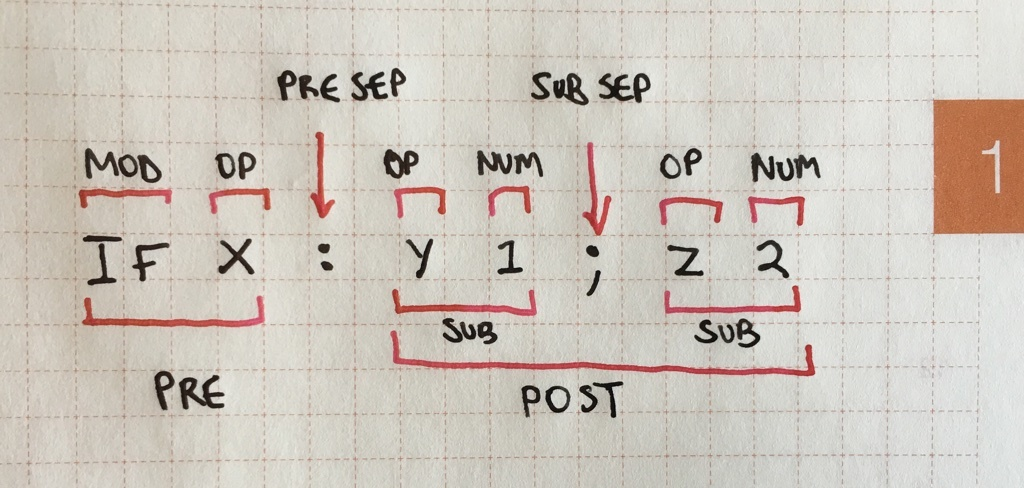

Teletype command terminology

**`COMMAND`**

The entire command, e.g. `IF X: Y 1; Z 2;`.

**`PRE`**

The (optional) part before the *`PRE SEP`*, e.g. `IF X`.

**`POST`**

The part after the *PRE SEP*, e.g. `Y 1; Z 2`.

**`SUB`**

A sub command (only allowed in the *`POST`*), e.g. `Y 1`, or `Z 2`.

**`PRE SEP`**

A *colon*, only one is allowed.

**`SUB SEP`**

A *semi-colon*, that separates sub commands (if used), only allowed in the *`POST`*.

**`NUM`**

A number between `−32768` and `32767`.

**`OP`**

An *operator*, e.g. `X`, `TR.PULSE`

**`MOD`**

A *modifier*, e.g. `IF`, or `L`.

## Sub commands

Sub commands allow you to run multiple commands on a single line by utilising a semi-colon to separate each command, for example the following script:

```
X 0
Y 1
Z 2
```

Can be rewritten using sub commands as:

```
X 0; Y 1; Z 2
```

On their own sub commands allow for an increased command density on the Teletype. However when combined with `PRE` statements, certain operations become a lot easier.

Firstly, sub commands cannot be used before a `MOD` or in the `PRE` itself. For example, the following is **not allowed**:

```
X 1; IF X: TR.PULSE 1
```

We can use them in the `POST` though, particularly with an `IF`, for example:

```
IF X: CV 1 N 60; TR.P 1
IF Y: TR.P 1; TR.P 2; TR.P 3
```

Sub commands can also be used with `L`.

## Aliases

In general, aliases are a simple concept to understand. Certain `OP`s have been given shorted names to save space and the amount of typing, for example:

```
TR.PULSE 1
```

Can be replaced with:

```
TR.P 1
```

Where confusion may arise is with the symbolic aliases that have been given to some of the maths `OP`s. For instance `+` is given as an alias for `ADD` and it *must* be used as a direct replacement:

```
X ADD 1 1
X + 1 1
```

The key to understanding this is that the Teletype uses *prefix notation*[[^1]](https://monome.org/docs/teletype/manual/#fn1) always, even when using mathematical symbols.

The following example (using *infix notation*) **will not work**:

```
X 1 + 1
```

Aliases are entirely optional, most `OP`s do not have aliases. Consult the `OP` tables and documentation to find them.

## Avoiding non-determinism

Although happy accidents in the modular world are one of it’s many joys, when writing computer programs they can be incredibly frustrating. Here are some small tips to help keep things predictable (when you want them to be):

1. **Don’t use variables unless you need to.**

   This is not to say that variables are not useful, rather it’s the opposite and they are extremely powerful. But it can be hard to keep a track of what each variable is used for and on which script it is used. Rather, try to save using variables for when you do want non-deterministic (i.e. *variable*) behaviour.
2. **Consider using `I` as a temporary variable.**

   If you do find yourself needing a variable, particularly one that is used to continue a calculation on another line, consider using the variable `I`. Unlike the other variables, `I` is overwritten whenever `L` is used, and as such, is implicitly transient in nature. One should never need to worry about modifying the value of `I` and causing another script to malfunction, as no script should ever assume the value of `I`.
3. **Use `PN` versions of `OP`s.**

   Most `P` `OP`s are now available as `PN` versions that ignore the value of `P.I`. (e.g. `PN.START` for `P.START`). Unless you explicitly require the non-determinism of `P` versions, stick to the `PN` versions (space allowing).
4. **Avoid using `A`, `B`, `C` and `D` to refer to the trigger outputs, instead use the numerical values directly.**

   As `A-D` are variables, they may no longer contain the values `1-4`, and while this was the recommend way to name triggers, it is no longer consider ideal. Newer versions of the Teletype hardware have replaced the labels on the trigger outputs, with the numbers `1` to `4`.

## Grid integration

Grid integration can be described very simply: it allows you to use grid with teletype. However, there is more to it than just that. You can create custom grid interfaces that can be tailored individually for each scene. Since it’s done with scripts you can dynamically change these interfaces at any point - you could even create a dynamic interface that reacts to the scene itself or incoming triggers or control voltages.

You can simply use grid as an LED display to visualize your scene. Or make it into an earthsea style keyboard. You can create sequencers, or control surfaces to control other sequencers. The grid operators simplify building very complex interfaces, while something simple like a bank of faders can be done with just two lines of scripts.

Grid integration consists of 3 main features: grid operators, Grid Visualizer, and Grid Control mode. Grid operators allow you to draw on grid or create grid controls, such as buttons and faders, that can trigger scripts when pressed. As with any other operators you can execute them in Live screen or use them in any of your scripts.

Grid Visualizer provides a virtual grid within the Teletype itself:

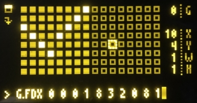

Grid Visualizer

It can be very useful while developing a script as you don’t have to switch between the grid and the keyboard as often. To turn it on navigate to Live screen and press `Alt-G` (press again to switch to Full View / turn it off). You can also emulate button presses, which means it can even be used as an alternative to grid if you don’t have one, especially in full mode - try it with one of the many [grid scenes](https://github.com/scanner-darkly/teletype/wiki/CODE-EXCHANGE) already developed. For more information on how to use it please refer to [the Grid Visualizer documentation](https://github.com/scanner-darkly/teletype/wiki/GRID-VISUALIZER).

Grid Control Mode is a built in grid interface that allows you to use grid to trigger and mute scripts, edit variables and tracker values, save and load scenes, and more. It’s available in addition to whatever grid interface you develop - simply press the front panel button while the grid is attached. It can serve as a simple way to use grid to control any scene even without using grid ops, but it can also be very helpful when used together with a scripted grid interface. For more information and diagrams please refer to [the Grid Control documentation](https://github.com/scanner-darkly/teletype/wiki/GRID-CONTROL-MODE),

If you do want to try and build your own grid interfaces [the Grid Studies](https://github.com/scanner-darkly/teletype/wiki/GRID-INTEGRATION) is the best place to start.

# Alphabetical list of OPs and MODs

| `OP` includes set notation and aliases | Description |
| --- | --- |
| **`$F script`** | execute script as a function |
| **`$F1 script param`** | execute script as a function with 1 parameter |
| **`$F2 script param1 param2`** | execute script as a function with 2 parameters |
| **`$L script line`** | execute script line |
| **`$L1 script line param`** | execute script line as a function with 1 parameter |
| **`$L2 script line param1 param2`** | execute script line as a function with 2 parameters |
| **`$S line`** | execute script line within the same script as a function |
| **`$S1 line param`** | execute script line within the same script as a function with 1 parameter |
| **`$S2 line param1 param2`** | execute script line within the same script as a function with 2 parameters |
| **`& x y`** | bitwise and `x` & `y` |
| **`? x y z`** | if condition `x` is true return `y`, otherwise return `z` |
| **`@`** **`@ x`** | get or set the current pattern value under the turtle |
| **`@BOUNCE`** **`@BOUNCE 1`** | get whether the turtle fence mode is BOUNCE, or set it to BOUNCE with 1 |
| **`@BUMP`** **`@BUMP 1`** | get whether the turtle fence mode is BUMP, or set it to BUMP with 1 |
| **`@DIR`** **`@DIR x`** | get the direction of the turtle’s @STEP in degrees or set it to x |
| **`@F x1 y1 x2 y2`** | set the turtle’s fence to corners x1,y1 and x2,y2 |
| **`@FX1`** **`@FX1 x`** | get the left fence line or set it to x |
| **`@FX2`** **`@FX2 x`** | get the right fence line or set it to x |
| **`@FY1`** **`@FY1 x`** | get the top fence line or set it to x |
| **`@FY2`** **`@FY2 x`** | get the bottom fence line or set it to x |
| **`@MOVE x y`** | move the turtle x cells in the X axis and y cells in the Y axis |
| **`@SCRIPT`** **`@SCRIPT x`** | get which script runs when the turtle changes cells, or set it to x |
| **`@SHOW`** **`@SHOW 0/1`** | get whether the turtle is displayed on the TRACKER screen, or turn it on or off |
| **`@SPEED`** **`@SPEED x`** | get the speed of the turtle’s @STEP in cells per step or set it to x |
| **`@STEP`** | move `@SPEED`/100 cells forward in `@DIR`, triggering `@SCRIPT` on cell change |
| **`@WRAP`** **`@WRAP 1`** | get whether the turtle fence mode is WRAP, or set it to WRAP with 1 |
| **`@X`** **`@X x`** | get the turtle X coordinate, or set it to x |
| **`@Y`** **`@Y x`** | get the turtle Y coordinate, or set it to x |
| **`A`** **`A x`** | get / set the variable `A`, default `1` |
| **`ABS x`** | absolute value of `x` |

[output cut: 867 more lines]

# Missing documentation

`EX.LP.DOWNQ`, `EX.LP.REVQ`, `EX.M.CC.POUND`, `EX.M.N.POUND`, `EX.M.NO.POUND`, `EX.N.POUND`, `EX.NO.POUND`, `EX.POUND`, `G.XYP`, `G.XYP.X`, `G.XYP.Y`, `I2M.C.MINUS`, `I2M.C.PLUS`, `I2M.C.POUND`, `I2M.C.TTILDE`, `I2M.C.VTILDE`, `I2M.CC.OFF.POUND`, `I2M.CC.POUND`, `I2M.CC.SET.POUND`, `I2M.CC.SLEW.POUND`, `I2M.CCV.POUND`, `I2M.MAX.POUND`, `I2M.MIN.POUND`, `I2M.MUTE.POUND`, `I2M.N.POUND`, `I2M.NO.POUND`, `I2M.NRPN.OFF.POUND`, `I2M.NRPN.POUND`, `I2M.NRPN.SET.POUND`, `I2M.NRPN.SLEW.POUND`, `I2M.NT.POUND`, `I2M.POUND`, `I2M.Q.POUND`, `I2M.RAT.POUND`, `I2M.REP.POUND`, `I2M.S.POUND`, `I2M.SOLO.POUND`, `I2M.T.POUND`, `I2M.TEST`, `MI.SYM.DOLLAR`, `SYM.AMPERSAND.x3`, `SYM.AMPERSAND.x4`, `SYM.DOLLAR.F`, `SYM.DOLLAR.F1`, `SYM.DOLLAR.F2`, `SYM.DOLLAR.L`, `SYM.DOLLAR.L1`, `SYM.DOLLAR.L2`, `SYM.DOLLAR.S`, `SYM.DOLLAR.S1`, `SYM.DOLLAR.S2`, `SYM.LEFT.ANGLED.x3`, `SYM.PIPE.x3`, `SYM.PIPE.x4`, `SYM.RIGHT.ANGLED.x3`, `WS.S.POLY`, `WS.S.POLY.RESET`, `WS.SEL`, `WS1`, `WS2`

# Changelog

## v5.0.0

- **FIX**: fix off-by-one error in `P.ROT` understanding of pattern length
- **FIX**: fix `CROW.Q3` calls `ii.self.query2` instead of `ii.self.query3`
- **FIX**: cache currently-running commands to avoid corruption during SCENE ops.
- **FIX**: delay when opening docs
- **FIX**: `PROB 100` would only execute 99.01% of the time.
- **FIX**: some `G.FDR` configurations caused incorrect rendering in grid visualizer
- **FIX**: fix `EX.LP` not returning correct values
- **FIX**: fix `QT.B` handling of negative voltage input
- **IMP**: scene load/save code refactor, add scene load/save tests
- **IMP**: fader ops now support up to four faderbanks
- **NEW**: new Disting EX ops: dual algorithms, `EX.M.N#`, `EX.M.NO#`, `EX.M.CC#`
- **FIX**: reset M timer when changing metro rate
- **NEW**: new Drum Ops: `DR.T`, `DR.V`, `DR.P`
- **NEW**: [I2C2MIDI](https://github.com/attowatt/i2c2midi) ops
- **FIX**: fixes a transcription error in the SD drum helper patterns
- **NEW**: Ten new patterns for `DR.V` and optimised old patterns
- **FIX**: fix BPM rounding error
- **FIX**: support all line ending types for USB load
- **FIX**: fix `STATE` not accounting for `DEVICE.FLIP`
- **FIX**: fix MIDI IN ops channel number being off by 1
- **FIX**: improve `TR.P` accuracy
- **FIX**: fix `KILL` not stopping TR pulses in progress
- **NEW**: new op: `SCALE0` / `SCL0`
- **NEW**: new ops: `$F`, `$F1`, `$F2`, `$L`, `$L1`, `$L2`, `$S`, `$S1`, `$S2`, `I1`, `I2`, `FR`
- **NEW**: new op: `CV.GET`
- **NEW**: basic menu for reading/writing scenes when a USB stick is inserted
- **NEW**: new ops: `CV.CAL` and `CV.CAL.RESET` to calibrate CV outputs
- **FIX**: N.CS scales 7 & 8 were incorrectly swapped; make them consistent with N.S and docs
- **FIX**: libavr32 update: support CDC grid size detection (e.g. zero), increase HID message buffer
- **NEW**: new Disting EX ops: `EX.CH`, `EX.#`, `EX.N#`, `EX.NO#`
- **NEW**: apply VCV Rack compatibility patches, so branches off main can be used in both hardware and software
- **FIX**: update Disting EX looper ops to work with Disting EX firmware 1.23+
- **NEW**: new dual W/ ops: `W/.SEL`, `W/S.POLY`, `W/S.POLY.RESET`, `W/1`, `W/2`
- **NEW**: split cheatsheets into separate PDFs for core ops and i2c

## v4.0.0

- **FIX**: `LAST SCRIPT` in live mode gives time since init script was run
- **FIX**: negative pattern values are properly read from USB
- **FIX**: delay when navigating to sections in docs
- **NEW**: generic i2c ops: `IIA`, `IIS..`, `IIQ..`, `IIB..`
- **NEW**: exponential delay operator `DEL.G`
- **NEW**: binary and hex format for numbers: `B...`, `X...`
- **NEW**: Disting EX ops
- **FIX**: `LAST n` is broken for script 1
- **NEW**: bitmasked delay and quantize: `DEL.B..`, `QT.B..`, `QT.BX..`
- **NEW**: scale and chord quantize: `QT.S..`, `QT.CS..`
- **NEW**: bit toggle OP: `BTOG..`
- **NEW**: volts to semitones helper OP: `VN..`
- **IMP**: DELAY_SIZE increased to 64 from 16
- **FIX**: scale degree arguments 1-indexed: `N.S`, `N.CS`
- **NEW**: Just Friends 4.0 OPs and dual JF OPs
- **NEW**: binary scale ops `N.B` and `N.BX`
- **NEW**: reverse binary for numbers: `R...`
- **NEW**: reverse binary OP: `BREV`
- **NEW**: `ES.CV` read earthsea CV values
- **NEW**: added setter for `R`, sets R.MIN and R.MAX to same value, allowing R to be used as variable
- **NEW**: v/oct to hz/v conversion op: `HZ`
- **FIX**: W/2.0 ops added
- **NEW**: W/2.0 ops documentation
- **NEW**: `><`, `<>`, `>=<` and `<=>` OPs, checks if value is within or outside of range
- **IMP**: new powerful Q OPs
- **IMP**: Improved line editing movement (forward/backward by word skips intervening space).
- **NEW**: Delete to end of word command `alt-d` added.
- **NEW**: new op: `SCENE.P`
- **NEW**: new multi-logic OPs `AND3`, `AND4`, `OR3` and `OR4` with aliases `&&&`, `&&&&`, `|||` and `||||`
- **NEW**: alias: `EV` for `EVERY`
- **NEW**: live mode dashboard
- **NEW**: ops to control live mode: `LIVE.OFF`, `LIVE.VARS`, `LIVE.GRID`, `LIVE.DASH`, `PRINT`
- **FIX**: `PN.ROT` parameters are swapped
- **FIX**: better rendering for fine grid faders
- **FIX**: logical operators should treat all non zero values as `true`, not just positive values
- **NEW**: crow ops
- **NEW**: `TI.PRM.CALIB` alias added (was already in the docs)
- **FIX**: `SCENE` would crash if parameter was out of bounds

## v3.2.0

- **FIX**: improve DAC latency when using `CV` ops
- **NEW**: call metro / init with `SCRIPT 9` / `SCRIPT 10`
- **NEW**: forward (C-f or C-s) and reverse (C-r) search in help mode
- **NEW**: new ops: `LROT` (alias `<<<`), `RROT` (alias `>>>`)
- **NEW**: `LSH` and `RSH` shift the opposite direction when passed a negative shift amount
- **NEW**: new op: `SGN` (sign of argument)
- **NEW**: new kria remote op: `KR.DUR`
- **NEW**: new op: `NR` (binary math pattern generator)
- **NEW**: new ops: `N.S, N.C, N.CS` (use western scales and chords to get values from `N` table)
- **NEW**: new ops: `FADER.SCALE, FADER.CAL.MIN, FADER.CAL.MAX, FADER.CAL.RESET` for scaling 16n Faderbank values (aliases `FB.S, FB.C.MIN, FB.C.MAX, FB.C.R`)
- **NEW**: new Tracker mode keybinding `alt-[ ]` semitone up, down
- **NEW**: new Tracker mode keybinding `ctrl-[ ]` fifth up, down
- **NEW**: new Tracker mode keybinding `shift-[ ]` octave up, down
- **NEW**: new Tracker mode keybinding `alt-<0-9>` `<0-9>` semitones up (0=10, 1=11)
- **NEW**: new Tracker mode keybinding `shift-alt-<0-9>` `<0-9>` semitones down (0=10, 1=11)
- **FIX**: dim M in edit mode when metro inactive
- **NEW**: new pattern ops: `P.SHUF`, `PN.SHUF`, `P.REV`, `PN.REV`, `P.ROT`, `PN.ROT`
- **NEW**: new pattern mods: `P.MAP:`, `PN.MAP x:`

## v3.1.0

- **NEW**: new op: `DEVICE.FLIP`
- **FIX**: [some keyboards losing keystrokes](https://github.com/monome/teletype/issues/156)
- **NEW**: new op: `DEL.X`
- **NEW**: new op: `DEL.R`
- **IMP**: DELAY_SIZE increased to 16 from 8
- **NEW**: new variables: `J` & `K` local script variables
- **FIX**: [metro rate not updated after `INIT.SCENE`](https://github.com/monome/teletype/issues/174)
- **NEW**: new ops: `SEED`, `R.SEED`, `TOSS.SEED`, `DRUNK.SEED`, `P.SEED`, `PROB.SEED`
- **NEW**: new op: `SCENE.G`
- **NEW**: new op: `SCRIPT.POL`, alias `$.POL`
- **NEW**: new ansible remote ops: `ANS.G`, `ANS.G.P`, `ANS.G.LED`, `ANS.A`, `ANS.A.LED`
- **NEW**: new kria remote ops: `KR.CUE`, `KR.PG`

## v3.0.0

- **NEW**: grid integration / grid visualizer / grid control mode
- **NEW**: multiline copy/paste and editing
- **NEW**: new keybindings to move by words
- **NEW**: undo in script editing
- **NEW**: i2c support for ER-301
- **NEW**: i2c support for 16n Faderbank
- **NEW**: i2c support for Matrixarchate
- **NEW**: i2c support for W/
- **NEW**: new op: `?`
- **NEW**: new ops: `P.MIN`, `PN.MIN`, `P.MAX`, `PN.MAX`, `P.RND`, `PN.RND`, `P.+`, `PN.+`, `P.-`, `PN.-`. `P.+W`, `PN.+W`, `P.-W`, `PN.-W`
- **NEW**: new Telex ops: `TO.CV.CALIB`, `TO.ENV`
- **NEW**: new Kria ops: `KR.CV`, `KR.MUTE`, `KR.TMUTE`, `KR.CLK`, `ME.CV`
- **NEW**: new aliases: `$`, `RND`, `RRND`, `WRP`, `SCL`
- **NEW**: telex, ansible, just friends, w/ added to the help screen
- **FIX**: i2c initialization delayed to account for ER-301 bootup
- **FIX**: last screen saved to flash
- **FIX**: knob jitter when loading/saving scenes reduced
- **FIX**: [duplicate commands not added to history](https://github.com/monome/teletype/issues/99)
- **FIX**: `SCALE` precision improved
- **FIX**: `PARAM` set properly when used in the init script
- **FIX**: `PARAM` and `IN` won’t reset to 0 after `INIT.DATA`
- **FIX**: [`PN.HERE`, `P.POP`, `PN.POP` will update the tracker screen](https://github.com/monome/teletype/issues/151)
- **FIX**: [`P.RM` was 1-based, now 0-based](https://github.com/monome/teletype/issues/149)
- **FIX**: [`P.RM` / `PN.RM` will not change pattern length if deleting outside of length range](https://github.com/monome/teletype/issues/150)
- **FIX**: [`JI` op fixed](https://llllllll.co/t/teletype-the-ji-op/10553)
- **FIX**: [`TIME` and `LAST` are now 1ms accurate](https://github.com/monome/teletype/issues/144)
- **FIX**: [`RAND` / `RRAND` will properly work with large range values](https://github.com/monome/teletype/issues/143)
- **FIX**: [`L .. 32767` won’t freeze](https://github.com/monome/teletype/issues/148)
- **FIX**: `I` now accessible to child SCRIPTS

## v2.2

- **NEW**: added a cheat sheet PDF
- **NEW**: new bitwise ops: `&`, `|`, `^`, `~`, `BSET`, `BCLR`, `BGET`
- **NEW**: new ops `PARAM.SCALE min max` and `IN.SCALE min max` to add static scaling to inputs
- **NEW**: blanking screensaver after 90 minutes of keyboard inactivity, any key to wake
- **NEW**: new op: `CHAOS` chaotic sequence generator. Control with `CHAOS.ALG` and `CHAOS.R`
- **NEW**: new op family: `INIT`, to clear device state
- **NEW**: new ops: `R`, `R.MIN`, `R.MAX` programmable RNG
- **IMP**: profiling code (optional, dev feature)
- **IMP**: screen now redraws only lines that have changed
- **FIX**: multiply now saturates at limits, previous behaviour returned 0 at overflow
- **FIX**: entered values now saturate at int16 limits
- **FIX**: reduced flash memory consumption by not storing TEMP script
- **FIX**: `I` now carries across `DEL` commands
- **FIX**: removed TEMP script allocation in flash
- **FIX**: corrected functionality of JI op for 1volt/octave tuning and removed octave-wrapping behaviour (now returns exactly the entered ratio)
- **FIX**: reduced latency of `IN` op

## v2.1

- **BREAKING**: the `I` variable is now scoped to the `L` loop, and does not exist outside of an execution context. Scripts using `I` as a general-purpose variable will be broken.
- **FIX**: `SCENE` will not run from `INIT` script during scene load.
- **NEW**: Tracker data entry overhaul. Type numbers, press enter to commit.
- **NEW**: new op: `BPM` to get milliseconds per beat in given BPM
- **NEW**: script lines can be disabled / enabled with ctrl-/
- **NEW**: shift-enter in scene write mode now inserts a line
- **NEW**: new ops: `LAST x` for the last time script `x` was called
- **NEW**: `SCRIPT` with no arguments gets the current script number.
- **FIX**: `AVG` and `Q.AVG` now round up properly
- **NEW**: new op: `BREAK` to stop the remainder of the script
- **NEW**: new mod: `W [condition]: [statement]` will execute `statement` as long as `condition` is true (up to an iteration limit).
- **NEW**: new mods: `EVERY x:`, `SKIP x:`, `OTHER:` to alternately execute or not execute a command.
- **NEW**: new op: `SYNC x` will synchronize all `EVERY` and `SKIP` line to the same step.
- **NEW**: new feature: @ - the turtle. Walks around the pattern grid. Many ops, see documentation.
- **OLD**: ctrl-F1 to F8 mute/unmute scripts.
- **NEW**: ctrl-F9 enables/disables METRO.
- **FIX**: recursive delay fix. Now you can `1: DEL 500: SCRIPT 1` for temporal recursion.
- **FIX**: `KILL` now clears TR output as well as disabling the METRO script.
- **FIX**: if / else conditions no longer transcend their script
- **IMP**: functional exectuion stack for `SCRIPT` operations

## v2.0.1

- **FIX**: update IRQ masking which prevents screen glitches and crashing under heavy load

## v2.0

- **BREAKING**: remove `II` op. Ops that required it will now work with out it. (e.g. `II MP.PRESET 1` will become just `MP.PRESET 1`)
- **BREAKING**: merge the `MUTE` and `UNMUTE` ops. Now `MUTE x` will return the mute status for trigger `x` (`0` is unmuted, `1` is muted), and `MUTE x y` will set the mute for trigger `x` (`y = 0` to unmute, `y = 1` to mute)
- **BREAKING**: remove unused Meadowphysics ops: `MP.SYNC`, `MP.MUTE`, `MP.UNMUTE`, `MP.FREEZE`, `MP.UNFREEZE`
- **BREAKING**: rename Ansible Meadowphysics ops to start with `ME`
- **NEW**: sub commands, use a `;` separator to run multiple commands on a single line, e.g. `X 1; Y 2`
- **NEW**: key bindings rewritten
- **NEW**: aliases: `+` for `ADD`, `-` for `SUB`, `*` for `MUL`, `/` for `DIV`, `%` for `MOD`, `<<` for `LSH`, `>>` for `RSH`, `==` for `EQ`, `!=` for `NE`, `<` for `LT`, `>` for `GT`, `<=` for `LTE`, `>=` for `GTE`, `!` for `EZ`, `&&` for `AND`, `||` for `OR`, `PRM` for `PARAM`, `TR.P` for `TR.PULSE`
- **NEW**: new ops: `LTE` (less than or equal), and `GTE` (greater than or equal)
- **NEW**: new pattern ops: `PN.L`, `PN.WRAP`, `PN.START`, `PN.END`, `PN.I`, `PN.HERE`, `PN.NEXT`, `PN.PREV`, `PN.INS`, `PN.RM`, `PN.PUSH` and `PN.POP`
- **NEW**: USB disk loading and saving works at any time
- **NEW**: `M` limited to setting the metronome speed to 25ms, added `M!` to allow setting the metronome at unsupported speeds as low as 2ms
- **NEW**: TELEX Aliases: `TO.TR.P` for `TO.TR.PULSE` (plus all sub-commands) and `TI.PRM` for `TI.PARAM` (plus all sub-commands)
- **NEW**: TELEX initialization commands: `TO.TR.INIT n`, `TO.CV.INIT n`, `TO.INIT x`, `TI.PARAM.INIT n`, `TI.IN.INIT n`, and `TI.INIT x`
- **IMP**: new Ragel parser backend
- **IMP**: script recursion enhanced, maximum recursion depth is 8, and self recursion is allowed
- **IMP**: removed the need to prefix `:` and `;` with a space, e.g. `IF X : TR.PULSE 1` becomes `IF X: TR.PULSE`
- **IMP**: `AND` and `OR` now work as boolean logic, rather than bitwise, `XOR` is an alias for `NE`
- **FIX**: divide by zero errors now explicitly return a 0 (e.g. `DIV 5 0` now returns 0 instead of -1), previously the behaviour was undefined and would crash the simulator
- **FIX**: numerous crashing bugs with text entry
- **FIX**: i2c bus crashes under high `M` times with external triggers
- **FIX**: `P.I` and `PN.I` no longer set values longer than allowed
- **FIX**: `VV` works correctly with negative values

## v1.4.1

- **NEW**: added Ansible remote commands `LV.CV` and `CY.CV`
- **NEW**: Added TELEX Modules Support for the TXi and the TXo
- **NEW**: 75 New Operators Across the Two Modules
- **NEW**: Supports all basic Teletype functions (add `TI` and `TO` to the commands you already know)
- **NEW**: Extended functionality allows for additional capabilities for existing functions
- **NEW**: Experimental input operators add capabilities such as input range mapping and quantization
- **NEW**: Experimental output operators add oscillators, envelopes, independent metronomes, pulse dividing, etc.
- **NEW**: [Full List of Methods Found and Maintained Here](https://github.com/bpcmusic/telex/blob/master/commands.md)

## v1.2.1

- **NEW**: Just Friends ops: `JF.GOD`, `JF.MODE`, `JF.NOTE`, `JF.RMODE`, `JF.RUN`, `JF.SHIFT`, `JF.TICK`, `JF.TR`, `JF.TUNE`, `JF.VOX`, `JF.VTR`

## v1.2

- **NEW**: Ansible support added to ops: `CV`, `CV.OFF`, `CV.SET`, `CV.SLEW`, `STATE`, `TR`, `TR.POL`, `TR.PULSE`, `TR.TIME`, `TR.TOG`
- **NEW**: `P.RM` will also return the value removed
- **NEW**: `ER` op
- **IMP**: a `TR.TIME` of 0 will disable the pulse
- **IMP**: `O.DIR` renamed to `O.INC`, it’s the value by which `O` is *incremented* when it is accessed
- **IMP**: `IF`, `ELIF`, `ELSE` status is reset on each script run
- **IMP**: key repeat now works for all keypresses
- **FIX**: `FLIP` won’t interfere with the value of `O`
- **FIX**: the `O` op now returns it’s set value *before* updating itself
- **FIX**: the `DRUNK` op now returns it’s set value *before* updating itself
- **FIX**: `P.START` and `P.END` were set to 1 when set with too large values, now are set to 63
- **FIX**: `CV.SLEW` is correctly initialised to 1 for all outputs
- **FIX**: several bugs where pattern length wasn’t updated in track mode
- **FIX**: fixed `[` and `]` not updating values in track mode

## v1.1

- **NEW**: USB flash drive read/write
- **NEW**: `SCRIPT` op for scripted execution of other scripts!
- **NEW**: `MUTE` and `UNMUTE` ops for disabling trigger input
- **NEW**: hotkeys for `MUTE` toggle per input (meta-shift-number)
- **NEW**: screen indication in live mode for `MUTE` status
- **NEW**: `SCALE` op for scaling number from one range to another
- **NEW**: `JI` op just intonation helper
- **NEW**: `STATE` op to read current state of input triggers 1-8 (low/high = 0/1)
- **NEW**: keypad executes scripts (works for standalone USB keypads and full-sized keyboards)
- **NEW**: `KILL` op clears delays, stack, CV slews, pulses
- **NEW**: hotkey meta+ESC executes `KILL`
- **NEW**: `ABS` op absolute value, single argument
- **NEW**: `FLIP` op variable which changes state (0/1) on each read
- **NEW**: logic ops: `AND`, `OR`, `XOR`
- **NEW**: `O` ops: `O.MIN`, `O.MAX`, `O.WRAP`, `O.DIR` for counter range control
- **NEW**: `DRUNK` ops: `DRUNK.MIN`, `DRUNK.MAX`, `DRUNK.WRAP` for range control
- **NEW**: `TR.POL` specifies the polarity of `TR.PULSE`
- **NEW**: if powered down in tracker mode, will power up in tracker mode
- **IMP**: `TR.PULSE` retrigger behaviour now predictable
- **IMP**: mode switch keys more consistent (not constantly resetting to live mode)
- **FIX**: bug in command history in live mode
- **FIX**: `EXP` op now exists
- **FIX**: `P` and `PN` parse error
- **FIX**: possible crash on excess length line entry
- **FIX**: `CV` wrapping with negative `CV.OFF` values
- **FIX**: INIT script executed now on keyboardless scene recall
- **FIX**: `Q.AVG` overflow no more
- **FIX**: `P.PUSH` will fully fill a pattern
- **FIX**: `CV.SET` followed by slewed CV in one command works
- **FIX**: `DEL 0` no longer voids command

## v1.0

- Initial release
[^1]: Also know as *Polish notation*.

[interactive chart not shown]